# At the same income, Baltic women live as long as other Europeans, Baltic men up to 4.6 years shorter

Why do Baltic men die earlier? Life expectancy in the EU, 2015 to 2024

Author

Jolanta Stutane

# Project overview

## Background

In every EU country women live longer than men. The size of that difference, however, is not the same everywhere. Press coverage of Eurostat figures places the three Baltic states at the top of the list: in 2024 Latvia had the widest gap in the EU, close to ten years, followed by Lithuania and Estonia. These figures are checked against the data in this analysis.

A gap of almost ten years means that many Baltic men do not live to see retirement, while the women around them do. I live in Latvia, so this isn’t an abstract statistic for me. It made me want to find out what sits behind it, and whether the Baltic men simply follow a European pattern or fall outside it.

## Aim

The aim of this project is to describe the gap in life expectancy between women and men across the EU, and to identify which country-level factors are associated with it, with the Baltic states as the focus.

## Research question

**Main question:** How much shorter is men’s life expectancy at birth than women’s in the Baltic states compared with the rest of the EU, 2015 to 2024, and which causes of death go with the gap?

**Sub-questions:**

1. Which country-level factors (causes of death, alcohol, income, education) are associated with the size of the gap?
2. How has the gap changed between 2015 and 2024?
3. Where do Estonia, Latvia and Lithuania sit compared with the other EU countries?

**Scope:**

- **The measure:** life expectancy at birth, women minus men, in years, referred to as “the gap”.
- **The countries:** the EU member states, about 27.
- **The period:** 2015 to 2024, or the latest year available in each table.
- **The level:** countries, not individuals. Every number is a national figure.

With about 27 countries, the data can show which factors go together, not what causes what. The analysis therefore uses “is associated with” or “goes with”, never “causes”.

## Assumptions

**Rationale:** the expected findings are written down before any data is opened. This allows the results to be compared with the initial expectations, and prevents the story from being adjusted to fit the results afterwards.

**Expected message:** Baltic men die earlier, and this goes mainly with heart disease deaths before 65.

**The factor expected to matter most:** deaths from heart and circulatory disease among men under 65. They are the most common cause of early death for men in the Baltics, and many of these men die decades before the women. Accidents and suicide are expected to come second. Alcohol is expected to sit behind both, which is why alcohol-related deaths are included in the data.

**Hypotheses (expectations, not results):**

1. A bigger gap is associated with more men dying under 65 from heart and circulatory disease.
2. Accidents and suicide are also associated with a bigger gap.
3. More alcohol-related deaths among men are associated with a bigger gap.
4. Poorer countries have lower life expectancy for both sexes, but in the Baltics men fall further below the pattern than women do.
5. Where women are much more educated than men, the gap is bigger.
6. The gap has narrowed in most countries since 2015, but not at the same speed.
7. These factors overlap. Some may only stand in for wealth or for alcohol, so the analysis checks which of them still matters when the others are taken into account.

## Main findings

This part is written last, after Section 6, so that a reader sees the answer before the method. The expected message above stays unchanged, and the found message is placed next to it.

[output not shown]

**Hypotheses in brief** (details in 5.10.1): supported are 1 (heart disease), 2 (external causes), 4 (income does not explain the Baltic gap) and 6 (the gap narrowed, unevenly). Hypothesis 3 (alcohol) is supported for alcohol-related deaths, but only partly for the amount drunk: drinking goes with the gap moderately, and the Baltic gaps are larger than their drinking predicts. Hypothesis 5 (education) is not supported. Hypothesis 7 (which factor matters most) cannot be answered with 27 countries.

## The pipeline

The analysis runs as one chain. Each step uses only the output of the step before it.

```
Six tables                                              (Section 2)
  five from Eurostat: life expectancy, healthy life years, deaths by cause, GDP, education
  one from WHO, via Our World in Data: alcohol consumption per person
  saved untouched to data/raw/
        ↓
Cleaning                                                (Section 3)
  five data quality checks per table, then documented decisions
  only the 27 EU member states are kept
        ↓
Combining                                               (Section 4)
  women and men side by side, the gap computed
  joined on country code and year
  → data/clean/gap_panel.csv, one row per country and year (about 270 rows)
        ↓
Exploration                                             (Section 5)
  the gap against each candidate factor, the gap over time,
  the Baltic states against the rest of the EU
        ↓
The final graph                                         (Section 6)
  one graph in versions, each saved with a log line, then refined
  → figures/graph_v1.png, graph_v2.png, final_graph.png
```

## How this document is organised

| Section | Question it answers | Output |
| --- | --- | --- |
| 1. Environment setup | Is R ready to run the analysis? | Packages loaded, project folder found |
| 2. Gathering data | What did Eurostat and WHO deliver? | Six raw CSV files in `data/raw/` |
| 3. Cleaning | Can the data be trusted, and what has to change? | One clean table per dataset |
| 4. Combining the tables | Do the six tables fit together? | `data/clean/gap_panel.csv` |
| 5. Exploration | Which factors go with the gap? | Charts, correlations, dead ends |
| 6. The final graph | What is the one message? | Versions with a log, `figures/final_graph.png` |
| 7. Limits | What can the data not show? | A list of caveats |
| Appendix | Which expected relationships did not hold? | Dead ends and what was done about them |

## Where to find the parts of the course template

The document follows the order in which the work was done, so its sections are named differently from the course’s final project template. The content is the same. The table shows where each template section is found.

[output not shown]

## How the files are organised

The analysis is written in 17 files: this one, `stutane_final_project.qmd`, with the overview, and one file per section, which this file puts in place when it is rendered, so that the result is one report. The two longest sections, Cleaning and Exploration, are split further into one file per part, because very long files made the editor hang. The underscore at the start of the section files tells Quarto that they are parts of this report, not reports of their own. Each section file starts with a hidden setup chunk, so that it can also be run on its own while working on it.

| File | Content |
| --- | --- |
| `_1_setup.qmd` | 1. Environment setup |
| `_2_gathering.qmd` | 2. Gathering data |
| `_3_cleaning.qmd` | 3. Cleaning: introduction, then includes the six files below |
| `_3_1_life_expectancy.qmd` to `_3_6_alcohol.qmd` | 3.1 to 3.6, one file per table, each ending with saving its clean table |
| `_4_combining.qmd` | 4. Combining the tables |
| `_5_exploration.qmd` | 5. Exploration: introduction and 5.0, then includes the three files below |
| `_5_1_gap_and_causes.qmd` | 5.1 to 5.3: the gap and the causes of death |
| `_5_4_factors.qmd` | 5.4 and 5.5: the factors that go with the gap |
| `_5_6_men_and_robustness.qmd` | 5.6 to 5.10: the men, the two neighbours, healthy years, robustness and the summary |
| `_6_story.qmd` | 6. The final graph |
| `_7_limits.qmd` | 7. Limits and the appendix |

Two more documents belong to the presentation and are rendered on their own: `talk.qmd` (the talk, as slides with speaker notes) and `demo.qmd` (a code walkthrough that runs the report’s own chunks, from the raw download to the final graph).

# 1. Environment setup

This section prepares R before any data is loaded. It has to be run first, every time the project is opened. Every later section depends on it.

**Two steps:**

1. **Packages:** load the R packages used in the analysis, and install any that are missing.
2. **Project folder:** check that R finds the project folder, so every file path works on any computer.

## 1.1 Packages

All packages are loaded here, at the start, so they are listed in one place. `pacman::p_load()` loads each package and installs it first if it is missing. This way the file also runs on a computer that has never seen this project.

| Package | Purpose in the analysis |
| --- | --- |
| `tidyverse` | Reading files (`read_csv()`), working with tables (`filter()`, `mutate()`, joins, pivots) and charts (`ggplot()`) |
| `here` | File paths that start at the project folder, for example `here("data", "raw", "demo_mlexpec.csv")` |
| `janitor` | `clean_names()`, which makes column names short, lowercase and easy to type |
| `gtsummary` | `tbl_summary()`, a ready-made table of missing values and ranges for the data quality checks |
| `knitr` | `kable()`, which turns a small result table into a neat table in the rendered report. Not taught in the course, used only for display |
| `scales` | Readable axis labels, for example `label_percent()` for the education shares |
| `ggrepel` | Country labels on charts that push away from each other, so they do not overlap (`geom_text_repel()`) |
| `patchwork` | Places several charts side by side or on top of each other, for example a weak and an improved version of the same chart (`p1 + p2`). Not taught in the course |

`pacman` itself has to be installed before it can install the others. The first chunk checks this and installs it only if it is missing, as in the course template.

```r
# 1.1 Install pacman only if it is not installed yet, so p_load() below works on a new computer
if (!requireNamespace("pacman", quietly = TRUE)) install.packages("pacman")   # requireNamespace() is FALSE if pacman is missing
```

```r
# 1.1 Load every package the analysis uses, installing any that are missing
pacman::p_load(
  tidyverse,   # read_csv(), dplyr verbs, pivots, joins, ggplot2
  here,        # file paths that start at the project folder
  janitor,     # clean_names()
  gtsummary,   # tbl_summary() for the data quality tables
  knitr,       # kable() for neat result tables
  scales,      # axis labels such as percentages
  ggrepel,     # country labels that don't overlap
  patchwork    # several charts side by side, for example p1 + p2
)
```

**What it shows:** nothing if all goes well. A message only appears if a package had to be installed.

## 1.2 Project folder

`here()` finds the project folder by looking for the project file `final_project.Rproj` (or the empty `.here` file) in it. All paths start from there, so no full path like `C:/Users/...` is needed, and the project also works on another computer. The folders follow the course’s final project template.

| Folder | Content |
| --- | --- |
| `data/raw/` | The downloads from Eurostat, exactly as they arrived. These files are never edited. `SOURCE.md` lists where each one comes from |
| `data/clean/` | The clean tables created in the analysis |
| `figures/` | Exported charts |
| `notes/` | Decisions made during the analysis and a glossary of functions |

```r
# 1.2 Check where R thinks the project folder is
here()  # should end in Final_work
```

```
[1] "C:/Users/jolanta.stutane/Desktop/RSU_AI/Storyrelling_Data/Final_work"
```

**What it shows:** the path to the project folder. If it ends somewhere else, the `.here` file is missing.

# 2. Gathering data

To answer the research question, the analysis needs comparable figures for every EU country on life expectancy, health, causes of death, wealth and education, for the same years. The natural source is Eurostat, the statistical office of the EU. It collects the same figures from every member state using the same definitions, so the countries can be compared.

The data is not downloaded by hand from the Eurostat website. Each table is requested from Eurostat’s API (a web address that returns data) directly from R, so anyone can rerun this file and get the same data. Every Eurostat table has a code, for example `demo_mlexpec`, and is split into dimensions: sex, age, country, year. The values needed are selected inside the download link.

Every dataset is loaded in its **original, uncleaned form**. The only selection happens in the download link (sex, age, years), where it is visible to any reader. After the download, nothing is filtered, renamed or fixed in this section. Cleaning while loading would hide what was removed. Keeping gathering (Section 2) and cleaning (Section 3) apart means that every dropped row is a documented decision, not a side effect of the loading step.

**Every dataset follows the same three steps:**

1. **Build the link:** the table code plus the selected dimensions.
2. **Download once:** save the file to `data/raw/`. This folder is never edited, so the original download is always available.
3. **Load and look:** read the file into R, check its structure with `glimpse()` and inspect the first rows with `head()`.

**Naming of objects:** every object created for a dataset starts with the full name of that dataset, followed by what the object holds. The names are long, but they say exactly what each object is. For life expectancy the prefix is `life_expectancy_`: `life_expectancy_url` (the download link), `life_expectancy_file` (the path to the saved file), `life_expectancy_raw` (the table as downloaded) and, in Section 3, `life_expectancy_clean` (the cleaned table). The other datasets follow the same pattern: `healthy_life_years_`, `deaths_`, `gdp_` and `education_`.

| Sub-section | Dataset | Eurostat code | Role in the analysis |
| --- | --- | --- | --- |
| 2.1 | Life expectancy at birth | `demo_mlexpec` | The gap between women and men, the main measure |
| 2.2 | Healthy life years | `hlth_hlye` | Years in good health, women and men |
| 2.3 | Deaths by cause | `hlth_cd_asdr2` | Death rates under 65 by cause, including alcohol-related causes |
| 2.4 | GDP per capita | `tec00114` | Wealth of each country compared with the EU average |
| 2.5 | Education by sex | `sdg_04_20` | Share of 25 to 34 year olds with a university degree |
| 2.6 | Alcohol consumption per person | WHO, via Our World in Data | Litres of pure alcohol per person aged 15+, a direct measure of drinking |

**The EU member states.** The analysis covers the 27 EU member states. Their codes are defined once, here, because they are used in two places: in the download link of the deaths table (2.3) and in the cleaning of every table (Section 3). Eurostat writes Greece as `EL`, not `GR`.

```r
# 2. The 27 EU member states, in Eurostat's codes (Greece is EL)
eu_codes <- c("AT", "BE", "BG", "CY", "CZ", "DE", "DK", "EE", "EL",   # one code per member state
              "ES", "FI", "FR", "HR", "HU", "IE", "IT", "LT", "LU",
              "LV", "MT", "NL", "PL", "PT", "RO", "SE", "SI", "SK")

length(eu_codes)   # should be 27
```

```
[1] 27
```

**What it shows:** the number 27, one code per member state.

## 2.1 Life expectancy at birth

| **Eurostat code** | `demo_mlexpec`, “Life expectancy by age and sex” |
| --- | --- |
| **What it measures** | How many years a newborn would live on average, if the death rates of that year stayed the same for their whole life |
| **Unit** | Years |
| **Selected dimensions** | Sex: `F` (females) and `M` (males). Age: `Y_LT1` (“less than 1 year”), which is how Eurostat labels life expectancy at birth. All countries, years 2015 to 2024 |
| **Flags** | Some values carry letters: `e` estimated, `p` provisional, `b` break in the series (the method changed that year) |

**Role in the analysis:** this is the main measure. The gap is women’s life expectancy minus men’s, so this table provides the value on the y axis of most charts.

**Points to note:**

- Life expectancy is a snapshot, not a forecast. It does not follow real people through life. It answers the question: “if the current death rates never changed, how long would a baby born now live?”
- The table has 97 age classes, from `Y_LT1` to `Y_GE95`. Without selecting `Y_LT1` in the link, the file would have 97 rows per country, sex and year instead of one.
- The file also contains EU totals and non-EU countries. They are kept for now and removed in Section 3.
- 2020 and 2021 show a COVID dip. This is real, not an error.

### 2.1.1 Build the link

The link has four parts: the API address, the table code, the selected dimensions, and the years. In the dimension part, dots separate the dimensions in this order: frequency, unit, sex, age, country. `F+M` means both sexes, and the empty position after the last dot means all countries.

```r
# 2.1.1 The Eurostat API link for life expectancy
life_expectancy_url <- paste0(
  "https://ec.europa.eu/eurostat/api/dissemination/sdmx/2.1/data/",  # the API address
  "demo_mlexpec/",                      # the table code
  "A.YR.F+M.Y_LT1.",                    # annual, in years, women and men, at birth, all countries
  "?startPeriod=2015&endPeriod=2024",   # the study period
  "&format=SDMX-CSV"                    # ask for a CSV file
)

life_expectancy_url  # print the link, so it can also be opened in a browser
```

```
[1] "https://ec.europa.eu/eurostat/api/dissemination/sdmx/2.1/data/demo_mlexpec/A.YR.F+M.Y_LT1.?startPeriod=2015&endPeriod=2024&format=SDMX-CSV"
```

**What it shows:** one long web address. Pasted into a browser, it downloads the same CSV file.

### 2.1.2 Download once

The file is saved to `data/raw/`. The `if` check makes R download only when the file is not there yet, so rerunning this document never overwrites the original download.

```r
# 2.1.2 Save the raw file to data/raw/, only if it isn't there yet
life_expectancy_file <- here("data", "raw", "demo_mlexpec.csv")  # where the raw file goes

if (!file.exists(life_expectancy_file)) {   # TRUE only on the first run
  download.file(life_expectancy_url,        # from this link
                life_expectancy_file,       # to this file
                mode = "wb")                # "wb" copies the file byte for byte
}
```

**What it shows:** on the first run, a short message with the file size. After that, nothing, because the file already exists.

### 2.1.3 Load and look

Eurostat writes missing values as `:`, so `read_csv()` is told to treat `:` as missing. This is not cleaning: the values stay missing, R only reads them correctly. The column names stay exactly as Eurostat wrote them, for example `TIME_PERIOD` and `OBS_VALUE`.

```r
# 2.1.3 Read the raw file and check what arrived
life_expectancy_raw <- read_csv(life_expectancy_file,
                                na = c("", ":", "NA"),   # Eurostat marks missing values with ":"
                                show_col_types = FALSE)  # keep the output short

glimpse(life_expectancy_raw)  # rows, columns and the type of each column
```

```
Rows: 906
Columns: 11
$ DATAFLOW      <chr> "ESTAT:DEMO_MLEXPEC(1.0)", "ESTAT:DEMO_MLEXPEC(1.0)", "E…
$ `LAST UPDATE` <chr> "25/09/26 23:00:00", "25/09/26 23:00:00", "25/09/26 23:0…
$ freq          <chr> "A", "A", "A", "A", "A", "A", "A", "A", "A", "A", "A", "…
$ unit          <chr> "YR", "YR", "YR", "YR", "YR", "YR", "YR", "YR", "YR", "Y…
$ sex           <chr> "F", "F", "F", "F", "F", "F", "F", "F", "F", "F", "F", "…
$ age           <chr> "Y_LT1", "Y_LT1", "Y_LT1", "Y_LT1", "Y_LT1", "Y_LT1", "Y…
$ geo           <chr> "AL", "AL", "AL", "AL", "AL", "AL", "AL", "AL", "AL", "A…
$ TIME_PERIOD   <dbl> 2015, 2016, 2017, 2018, 2019, 2020, 2021, 2022, 2024, 20…
$ OBS_VALUE     <dbl> 79.7, 80.1, 80.1, 80.5, 80.7, 79.6, 77.7, 80.9, 82.4, 78…
$ OBS_FLAG      <chr> NA, NA, NA, NA, NA, NA, NA, NA, "b", NA, NA, NA, NA, NA,…
$ CONF_STATUS   <lgl> NA, NA, NA, NA, NA, NA, NA, NA, NA, NA, NA, NA, NA, NA, …
```

`glimpse()` lists every column with its type. `head()` shows the first rows as a table, the way the file is actually laid out.

```r
# 2.1.3 The first six rows of the raw table
head(life_expectancy_raw)   # how the file is laid out: one row per country, sex and year
```

```
# A tibble: 6 × 11
  DATAFLOW     `LAST UPDATE` freq  unit  sex   age   geo   TIME_PERIOD OBS_VALUE
  <chr>        <chr>         <chr> <chr> <chr> <chr> <chr>       <dbl>     <dbl>
1 ESTAT:DEMO_… 25/09/26 23:… A     YR    F     Y_LT1 AL           2015      79.7
2 ESTAT:DEMO_… 25/09/26 23:… A     YR    F     Y_LT1 AL           2016      80.1
3 ESTAT:DEMO_… 25/09/26 23:… A     YR    F     Y_LT1 AL           2017      80.1
4 ESTAT:DEMO_… 25/09/26 23:… A     YR    F     Y_LT1 AL           2018      80.5
5 ESTAT:DEMO_… 25/09/26 23:… A     YR    F     Y_LT1 AL           2019      80.7
6 ESTAT:DEMO_… 25/09/26 23:… A     YR    F     Y_LT1 AL           2020      79.6
# ℹ 2 more variables: OBS_FLAG <chr>, CONF_STATUS <lgl>
```

**What it shows:** a first overview of the raw table. Size and column types are visible in the output above. The remaining points are verified with code in Section 3.1.

- **Size:** 906 rows and 11 columns.
- **One row** is one geographic unit, one sex and one year, with its life expectancy in `OBS_VALUE`.
- **Types:** `OBS_VALUE` and `TIME_PERIOD` are numbers, so the flags did not turn the values into text. `CONF_STATUS` is empty in every row.
- **Geographic units:** 53 codes. They include all 27 EU member states (Greece appears as `EL`, not `GR`), 9 aggregates such as `EU27_2020`, `EA20` and `DE_TOT`, and 17 non-EU countries such as `NO`, `UK` and `UA`.
- **Completeness:** every EU member state has all 10 years for both sexes (27 × 2 × 10 = 540 rows). Some non-EU countries have fewer years.
- **Missing values and flags:** no value in `OBS_VALUE` is missing. 146 values carry a flag in `OBS_FLAG` (estimated, provisional or a break in the series).
- **Columns with one value only:** `freq`, `unit` and `age` repeat the choices made in the link, so they add no information. They are removed in Section 3.

## 2.2 Healthy life years

| **Eurostat code** | `hlth_hlye`, “Healthy life years and life expectancy at birth, by sex” |
| --- | --- |
| **What it measures** | How many years a newborn would live in good health, without limitations in daily activities, if the conditions of that year stayed the same |
| **Unit** | Years |
| **Selected dimensions** | Unit: `YR` (years). Sex: `F` and `M`. Indicator: `HLY_Y0`, healthy life years at birth. All countries, years 2015 to 2024 |

**Role in the analysis:** life expectancy says how long people live. Healthy life years say how much of that life is spent in good health. Together they show whether Baltic men lose years of life, years of good health, or both.

### 2.2.1 Build the link

The link has the same four parts as in 2.1. The dimensions are different in this table: frequency, unit, sex, health indicator, country. The table holds nine indicators (healthy life years and life expectancy, at birth, at 50 and at 65, in years and as a share), so the link selects only `HLY_Y0`.

```r
# 2.2.1 The Eurostat API link for healthy life years
healthy_life_years_url <- paste0(
  "https://ec.europa.eu/eurostat/api/dissemination/sdmx/2.1/data/",  # the API address
  "hlth_hlye/",                         # the table code
  "A.YR.F+M.HLY_Y0.",                   # annual, in years, women and men, healthy life years at birth, all countries
  "?startPeriod=2015&endPeriod=2024",   # the study period
  "&format=SDMX-CSV"                    # ask for a CSV file
)

healthy_life_years_url  # print the link, so it can also be opened in a browser
```

```
[1] "https://ec.europa.eu/eurostat/api/dissemination/sdmx/2.1/data/hlth_hlye/A.YR.F+M.HLY_Y0.?startPeriod=2015&endPeriod=2024&format=SDMX-CSV"
```

**What it shows:** one long web address. Pasted into a browser, it downloads the same CSV file.

### 2.2.2 Download once

Same as in 2.1.2: the file is saved to `data/raw/`, and only if it is not there yet.

```r
# 2.2.2 Save the raw file to data/raw/, only if it isn't there yet
healthy_life_years_file <- here("data", "raw", "hlth_hlye.csv")  # where the raw file goes

if (!file.exists(healthy_life_years_file)) {   # TRUE only on the first run
  download.file(healthy_life_years_url,        # from this link
                healthy_life_years_file,       # to this file
                mode = "wb")                   # "wb" copies the file byte for byte
}
```

**What it shows:** on the first run, a short message with the file size. After that, nothing, because the file already exists.

### 2.2.3 Load and look

Same as in 2.1.3: `:` is read as a missing value, and the column names stay exactly as Eurostat wrote them.

```r
# 2.2.3 Read the raw file and check what arrived
healthy_life_years_raw <- read_csv(healthy_life_years_file,
                                   na = c("", ":", "NA"),   # Eurostat marks missing values with ":"
                                   show_col_types = FALSE)  # keep the output short

glimpse(healthy_life_years_raw)  # rows, columns and the type of each column
```

```
Rows: 618
Columns: 11
$ DATAFLOW      <chr> "ESTAT:HLTH_HLYE(1.0)", "ESTAT:HLTH_HLYE(1.0)", "ESTAT:H…
$ `LAST UPDATE` <chr> "17/07/26 23:00:00", "17/07/26 23:00:00", "17/07/26 23:0…
$ freq          <chr> "A", "A", "A", "A", "A", "A", "A", "A", "A", "A", "A", "…
$ unit          <chr> "YR", "YR", "YR", "YR", "YR", "YR", "YR", "YR", "YR", "Y…
$ sex           <chr> "F", "F", "F", "F", "F", "F", "F", "F", "F", "F", "F", "…
$ hlth_hle      <chr> "HLY_Y0", "HLY_Y0", "HLY_Y0", "HLY_Y0", "HLY_Y0", "HLY_Y…
$ geo           <chr> "AT", "AT", "AT", "AT", "AT", "AT", "AT", "AT", "AT", "A…
$ TIME_PERIOD   <dbl> 2015, 2016, 2017, 2018, 2019, 2020, 2021, 2022, 2023, 20…
$ OBS_VALUE     <dbl> 58.1, 57.1, 56.8, 57.0, 58.0, 59.3, 61.3, 61.3, 60.5, 60…
$ OBS_FLAG      <chr> NA, NA, NA, NA, NA, NA, NA, NA, NA, NA, NA, NA, NA, NA, …
$ CONF_STATUS   <lgl> NA, NA, NA, NA, NA, NA, NA, NA, NA, NA, NA, NA, NA, NA, …
```

```r
# 2.2.3 The first six rows of the raw table
head(healthy_life_years_raw)   # how the file is laid out: one row per country, sex and year
```

```
# A tibble: 6 × 11
  DATAFLOW  `LAST UPDATE` freq  unit  sex   hlth_hle geo   TIME_PERIOD OBS_VALUE
  <chr>     <chr>         <chr> <chr> <chr> <chr>    <chr>       <dbl>     <dbl>
1 ESTAT:HL… 17/07/26 23:… A     YR    F     HLY_Y0   AT           2015      58.1
2 ESTAT:HL… 17/07/26 23:… A     YR    F     HLY_Y0   AT           2016      57.1
3 ESTAT:HL… 17/07/26 23:… A     YR    F     HLY_Y0   AT           2017      56.8
4 ESTAT:HL… 17/07/26 23:… A     YR    F     HLY_Y0   AT           2018      57
5 ESTAT:HL… 17/07/26 23:… A     YR    F     HLY_Y0   AT           2019      58
6 ESTAT:HL… 17/07/26 23:… A     YR    F     HLY_Y0   AT           2020      59.3
# ℹ 2 more variables: OBS_FLAG <chr>, CONF_STATUS <lgl>
```

**What it shows:** a first overview of the raw table. The remaining points are verified with code in Section 3.2.

- **Size:** 618 rows and 11 columns.
- **One row** is one geographic unit, one sex and one year, with its healthy life years in `OBS_VALUE`.
- **Types:** `OBS_VALUE` and `TIME_PERIOD` are numbers (`<dbl>`), so the flags did not turn the values into text.
- **Columns:** the same as in the life expectancy table, except that `age` is replaced by `hlth_hle`, the health indicator. It holds `HLY_Y0` in every row, as selected in the link.
- **Geographic units:** 33 codes, far fewer than the 53 in the life expectancy table. They are the 27 EU member states, 4 non-EU countries (`CH`, `IS`, `NO`, `UK`) and 2 aggregates (`EU27_2020`, `EU28`).
- **Completeness:** 26 of the 27 EU member states have all 10 years for both sexes. Luxembourg has no values for 2023 and 2024, so the EU part has 536 rows instead of 540.
- **Missing values:** no value in `OBS_VALUE` is missing. Missing years appear as missing rows, not as empty cells, so `summary()` alone would not reveal them. Only the row counts do.
- **Flags:** 80 values carry a flag, most often `b` (a break in the series). In the EU, the two Lithuanian values for 2024 are marked `p` (provisional), the only flags in the Baltic states.

## 2.3 Deaths by cause

| **Eurostat code** | `hlth_cd_asdr2`, “Causes of death, standardised death rate by NUTS 2 region of residence” |
| --- | --- |
| **What it measures** | How many people per 100 000 die of a given cause in a year, age-standardised |
| **Unit** | `RT`: deaths per 100 000 inhabitants |
| **Selected dimensions** | Sex: `F` and `M`. Age: `Y_LT65` (under 65). Cause: all 93. Countries: the 27 EU member states. Years 2015 to 2024 (the table currently ends in 2023) |

**Role in the analysis:** this table tests the main hypothesis. If Baltic men die earlier mainly because of heart disease before 65, it shows up here as a much higher death rate from circulatory diseases among men than among women.

**Points to note:**

- **Age-standardised** means the rates are calculated as if every country had the same age structure. Without it, a country with many older people would always look worse. With it, the countries can be compared fairly.
- **Under 65 only.** Deaths before 65 are the ones that pull life expectancy down most, and they are where the gap between women and men is expected to come from.
- **All 93 causes are downloaded.** Choosing only the causes named in the hypotheses could hide a cause that was not expected, which would bias the analysis by design. The analysis first looks at the big, non-overlapping groups of causes (chapters such as circulatory diseases, cancer or external causes) without choosing anything, and only then at the specific causes named in the hypotheses.
- **Causes are nested.** Some causes are part of others, for example ischaemic heart disease (`I20-I25`) is part of all circulatory diseases (`I`). They can be compared, but never added up.
- **The 27 EU countries are selected in the link,** unlike in 2.1 and 2.2. Besides 36 countries, the table holds about 460 regions, so the full file would be 55 MB. Only the countries are needed.
- **The latest year is 2023.** Death statistics take longer to publish than life expectancy.

### 2.3.1 Build the link

The same four parts as in 2.1 and 2.2. The dimensions of this table, in order: frequency, unit, sex, age, cause of death, country. The cause position is left empty, which means all causes. The country position lists the 27 EU codes joined with `+`.

```r
# 2.3.1 The Eurostat API link for deaths by cause
deaths_url <- paste0(
  "https://ec.europa.eu/eurostat/api/dissemination/sdmx/2.1/data/",  # the API address
  "hlth_cd_asdr2/",                     # the table code
  "A.RT.F+M.Y_LT65..",                  # annual, rate per 100 000, women and men, under 65, all causes (empty)
  paste(eu_codes, collapse = "+"),      # the 27 EU countries, joined as AT+BE+BG+...
  "?startPeriod=2015&endPeriod=2024",   # the study period
  "&format=SDMX-CSV"                    # ask for a CSV file
)

deaths_url  # print the link, so it can also be opened in a browser
```

```
[1] "https://ec.europa.eu/eurostat/api/dissemination/sdmx/2.1/data/hlth_cd_asdr2/A.RT.F+M.Y_LT65..AT+BE+BG+CY+CZ+DE+DK+EE+EL+ES+FI+FR+HR+HU+IE+IT+LT+LU+LV+MT+NL+PL+PT+RO+SE+SI+SK?startPeriod=2015&endPeriod=2024&format=SDMX-CSV"
```

**What it shows:** one long web address, with the 27 country codes near the end.

### 2.3.2 Download once

Same as in 2.1.2, with one extra check. For larger requests, Eurostat sometimes puts the request in a queue and sends back a short waiting message instead of the data. Saved as a file, that message would look like a CSV but hold no data. A real Eurostat CSV always starts with the column name `DATAFLOW`, so the first line of the file is checked. If it is anything else, the file is deleted and the chunk stops with a message to run it again a minute later.

```r
# 2.3.2 Save the raw file to data/raw/, only if it isn't there yet
deaths_file <- here("data", "raw", "hlth_cd_asdr2.csv")  # where the raw file goes

if (!file.exists(deaths_file)) {             # TRUE only on the first run
  download.file(deaths_url,                  # from this link
                deaths_file,                 # to this file
                mode = "wb")                 # "wb" copies the file byte for byte

  first_line <- readLines(deaths_file, n = 1)            # read only the first line of the file
  if (!startsWith(first_line, "DATAFLOW")) {             # a real Eurostat CSV starts with DATAFLOW
    file.remove(deaths_file)                             # delete the waiting message, keep data/raw/ clean
    stop("Eurostat queued the request. Wait a minute and run this chunk again.")   # stop with a clear message
  }
}
```

**What it shows:** on the first run, a short message with the file size. After that, nothing, because the file already exists. If Eurostat queued the request, a red message says to run the chunk again.

### 2.3.3 Load and look

Same as in 2.1.3 and 2.2.3: `:` is read as a missing value, and the column names stay exactly as Eurostat wrote them. This table has one column more than the first two: `icd10`, the cause of death, coded with the international classification of diseases (ICD-10).

```r
# 2.3.3 Read the raw file and check what arrived
deaths_raw <- read_csv(deaths_file,
                       na = c("", ":", "NA"),   # Eurostat marks missing values with ":"
                       show_col_types = FALSE)  # keep the output short

glimpse(deaths_raw)  # rows, columns and the type of each column
```

```
Rows: 43,902
Columns: 12
$ DATAFLOW      <chr> "ESTAT:HLTH_CD_ASDR2(1.0)", "ESTAT:HLTH_CD_ASDR2(1.0)", …
$ `LAST UPDATE` <chr> "08/06/26 23:00:00", "08/06/26 23:00:00", "08/06/26 23:0…
$ freq          <chr> "A", "A", "A", "A", "A", "A", "A", "A", "A", "A", "A", "…
$ unit          <chr> "RT", "RT", "RT", "RT", "RT", "RT", "RT", "RT", "RT", "R…
$ sex           <chr> "F", "F", "F", "F", "F", "F", "F", "F", "F", "F", "F", "…
$ age           <chr> "Y_LT65", "Y_LT65", "Y_LT65", "Y_LT65", "Y_LT65", "Y_LT6…
$ icd10         <chr> "A-R_V-Y", "A-R_V-Y", "A-R_V-Y", "A-R_V-Y", "A-R_V-Y", "…
$ geo           <chr> "AT", "AT", "AT", "AT", "BE", "BE", "BE", "BE", "BG", "B…
$ TIME_PERIOD   <dbl> 2018, 2019, 2020, 2021, 2018, 2019, 2020, 2021, 2018, 20…
$ OBS_VALUE     <dbl> 114.85, 110.88, 111.59, 111.89, 135.44, 128.97, 131.22, …
$ OBS_FLAG      <lgl> NA, NA, NA, NA, NA, NA, NA, NA, NA, NA, NA, NA, NA, NA, …
$ CONF_STATUS   <lgl> NA, NA, NA, NA, NA, NA, NA, NA, NA, NA, NA, NA, NA, NA, …
```

```r
# 2.3.3 The first six rows of the raw table
head(deaths_raw)   # how the file is laid out: one row per country, sex, cause and year
```

```
# A tibble: 6 × 12
  DATAFLOW         `LAST UPDATE` freq  unit  sex   age   icd10 geo   TIME_PERIOD
  <chr>            <chr>         <chr> <chr> <chr> <chr> <chr> <chr>       <dbl>
1 ESTAT:HLTH_CD_A… 08/06/26 23:… A     RT    F     Y_LT… A-R_… AT           2018
2 ESTAT:HLTH_CD_A… 08/06/26 23:… A     RT    F     Y_LT… A-R_… AT           2019
3 ESTAT:HLTH_CD_A… 08/06/26 23:… A     RT    F     Y_LT… A-R_… AT           2020
4 ESTAT:HLTH_CD_A… 08/06/26 23:… A     RT    F     Y_LT… A-R_… AT           2021
5 ESTAT:HLTH_CD_A… 08/06/26 23:… A     RT    F     Y_LT… A-R_… BE           2018
6 ESTAT:HLTH_CD_A… 08/06/26 23:… A     RT    F     Y_LT… A-R_… BE           2019
# ℹ 3 more variables: OBS_VALUE <dbl>, OBS_FLAG <lgl>, CONF_STATUS <lgl>
```

**What it shows:** a first overview of the raw table. The remaining points are verified with code in Section 3.3.

- **Size:** 43 902 rows and 12 columns.
- **One row** is one country, one sex, one cause and one year, with its death rate per 100 000 in `OBS_VALUE`.
- **Columns:** the same as in the first two tables, plus `icd10`, the cause of death.
- **Countries:** exactly the 27 EU member states, as asked in the link, each with 1 626 rows.
- **Years:** 2015 to 2023. There is no 2024 yet.
- **Causes:** 93 codes, but not all in every year. 89 codes exist from 2015 to 2019, and 92 from 2020, when three COVID-19 codes were added.
- **“All causes” has two codes.** The total of all causes is coded `TOTAL` in 2015 to 2017 and 2022 to 2023, but `A-R_V-Y` in 2018 to 2021. It is the same measure under two names, so it has to be handled in cleaning, otherwise the total would seem to disappear in four years.
- **Missing values and flags:** no value is missing and no value carries a flag. `OBS_FLAG` and `CONF_STATUS` are empty in every row.
- **Range:** from 0 (causes with no deaths under 65 in a small country) to 716.9 deaths per 100 000.

## 2.4 GDP per capita

| **Eurostat code** | `tec00114`, “GDP per capita in PPS” |
| --- | --- |
| **What it measures** | How rich a country is per person, compared with the EU average |
| **Unit** | Index, EU27 = 100. A value of 120 means 20% above the EU average, 70 means 30% below |
| **Selected dimensions** | Indicator: `VI_PPS_EU27_2020_HAB` (volume index per person, in purchasing power standards). Category: `GDP`. All countries, years 2015 to 2024 |

**Role in the analysis:** wealth is the factor that could explain everything else. Poorer countries may have lower life expectancy for both sexes, and the analysis checks whether the Baltic gap is larger than their income alone would suggest (hypothesis 4).

**Points to note:**

- **PPS (purchasing power standards)** removes the differences in price levels between countries. A euro buys more in Bulgaria than in Luxembourg, and PPS corrects for that, so the countries can be compared fairly.
- **No sex dimension.** GDP is a figure for the whole country, so there is one value per country and year, not one for women and one for men.
- **An index compares countries, not years.** Over time it shows whether a country catches up with the EU average or falls behind, not whether it grows in real terms.
- **The file also contains non-EU countries** such as Norway, the United States and Japan, and aggregates such as the euro area. As in 2.1 and 2.2, they are kept for now and removed in Section 3. The file is small, so the 30 October rule (EU filter in cleaning) applies again.

### 2.4.1 Build the link

The same four parts as before. This table has four dimensions: frequency, indicator, category and country. The country position is left empty, which means all countries.

```r
# 2.4.1 The Eurostat API link for GDP per capita
gdp_url <- paste0(
  "https://ec.europa.eu/eurostat/api/dissemination/sdmx/2.1/data/",  # the API address
  "tec00114/",                          # the table code
  "A.VI_PPS_EU27_2020_HAB.GDP.",        # annual, volume index per person (EU27 = 100), GDP, all countries
  "?startPeriod=2015&endPeriod=2024",   # the study period
  "&format=SDMX-CSV"                    # ask for a CSV file
)

gdp_url  # print the link, so it can also be opened in a browser
```

```
[1] "https://ec.europa.eu/eurostat/api/dissemination/sdmx/2.1/data/tec00114/A.VI_PPS_EU27_2020_HAB.GDP.?startPeriod=2015&endPeriod=2024&format=SDMX-CSV"
```

**What it shows:** one long web address. Pasted into a browser, it downloads the same CSV file.

### 2.4.2 Download once

Same as in 2.3.2, including the check of the first line. The file is small, so Eurostat is not expected to queue it, but the check costs nothing and protects `data/raw/` in case it does.

```r
# 2.4.2 Save the raw file to data/raw/, only if it isn't there yet
gdp_file <- here("data", "raw", "tec00114.csv")   # where the raw file goes

if (!file.exists(gdp_file)) {                    # TRUE only on the first run
  download.file(gdp_url,                         # from this link
                gdp_file,                        # to this file
                mode = "wb")                     # "wb" copies the file byte for byte

  first_line <- readLines(gdp_file, n = 1)                # read only the first line of the file
  if (!startsWith(first_line, "DATAFLOW")) {              # a real Eurostat CSV starts with DATAFLOW
    file.remove(gdp_file)                                 # delete the waiting message, keep data/raw/ clean
    stop("Eurostat queued the request. Wait a minute and run this chunk again.")   # stop with a clear message
  }
}
```

**What it shows:** on the first run, a short message with the file size. After that, nothing, because the file already exists.

### 2.4.3 Load and look

Same as in 2.1.3 to 2.3.3. This table has no `sex` column, and two columns that describe the indicator: `indic_ppp` and `ppp_cat18`.

```r
# 2.4.3 Read the raw file and check what arrived
gdp_raw <- read_csv(gdp_file,
                    na = c("", ":", "NA"),   # Eurostat marks missing values with ":"
                    show_col_types = FALSE)  # keep the output short

glimpse(gdp_raw)  # rows, columns and the type of each column
```

```
Rows: 430
Columns: 10
$ DATAFLOW      <chr> "ESTAT:TEC00114(1.0)", "ESTAT:TEC00114(1.0)", "ESTAT:TEC…
$ `LAST UPDATE` <chr> "09/07/26 23:00:00", "09/07/26 23:00:00", "09/07/26 23:0…
$ freq          <chr> "A", "A", "A", "A", "A", "A", "A", "A", "A", "A", "A", "…
$ indic_ppp     <chr> "VI_PPS_EU27_2020_HAB", "VI_PPS_EU27_2020_HAB", "VI_PPS_…
$ ppp_cat18     <chr> "GDP", "GDP", "GDP", "GDP", "GDP", "GDP", "GDP", "GDP", …
$ geo           <chr> "AL", "AL", "AL", "AL", "AL", "AL", "AL", "AL", "AL", "A…
$ TIME_PERIOD   <dbl> 2015, 2016, 2017, 2018, 2019, 2020, 2021, 2022, 2023, 20…
$ OBS_VALUE     <dbl> 30, 30, 30, 30, 30, 30, 31, 33, 38, 42, 128, 128, 125, 1…
$ OBS_FLAG      <chr> NA, NA, NA, NA, NA, NA, NA, NA, NA, NA, NA, NA, NA, NA, …
$ CONF_STATUS   <lgl> NA, NA, NA, NA, NA, NA, NA, NA, NA, NA, NA, NA, NA, NA, …
```

```r
# 2.4.3 The first six rows of the raw table
head(gdp_raw)   # how the file is laid out: one row per country and year
```

```
# A tibble: 6 × 10
  DATAFLOW   `LAST UPDATE` freq  indic_ppp ppp_cat18 geo   TIME_PERIOD OBS_VALUE
  <chr>      <chr>         <chr> <chr>     <chr>     <chr>       <dbl>     <dbl>
1 ESTAT:TEC… 09/07/26 23:… A     VI_PPS_E… GDP       AL           2015        30
2 ESTAT:TEC… 09/07/26 23:… A     VI_PPS_E… GDP       AL           2016        30
3 ESTAT:TEC… 09/07/26 23:… A     VI_PPS_E… GDP       AL           2017        30
4 ESTAT:TEC… 09/07/26 23:… A     VI_PPS_E… GDP       AL           2018        30
5 ESTAT:TEC… 09/07/26 23:… A     VI_PPS_E… GDP       AL           2019        30
6 ESTAT:TEC… 09/07/26 23:… A     VI_PPS_E… GDP       AL           2020        30
# ℹ 2 more variables: OBS_FLAG <chr>, CONF_STATUS <lgl>
```

**What it shows:** a first overview of the raw table. The remaining points are verified with code in Section 3.4.

- **Size:** 430 rows and 10 columns, one fewer than the first two tables, because there is no `sex` column.
- **One row** is one geographic unit and one year, with its GDP index in `OBS_VALUE`. There is no `sex` column.
- **Geographic units:** 43 codes: the 27 EU member states, the aggregates `EU27_2020`, `EA19`, `EA20` and `EA21` (the euro area in different years), and 12 other countries such as `NO`, `UK`, `US` and `JP`.
- **Completeness:** every unit has all 10 years, so the EU part has 270 rows (27 × 10).
- **Missing values and flags:** no value is missing. 9 values are marked `p` (provisional), all from 2023 or 2024. In the EU these are Germany, Greece and Spain in 2023 and 2024, and France in 2024. The Baltic states have no flags.
- **Range in the EU:** from 49 (Bulgaria, 2015) to 279 (Luxembourg, 2015). Luxembourg is far above every other country, partly because many people work there but live in neighbouring countries, so its GDP is shared by fewer residents.

## 2.5 Education by sex

| **Eurostat code** | `sdg_04_20`, “Tertiary educational attainment” |
| --- | --- |
| **What it measures** | The share of people aged 25 to 34 who have finished tertiary education (a university degree or a similar higher education) |
| **Unit** | Percent of the age group |
| **Selected dimensions** | Sex: `F` and `M`. Age: `Y25-34`. Unit: `PC` (percentage). Education level: `ED5-8` (tertiary, levels 5 to 8). All countries, years 2015 to 2024 |

**Role in the analysis:** this table tests hypothesis 5: where women are much more educated than men, the gap in life expectancy is bigger. Education goes with income, health habits and the kind of work people do, so a large difference in education between women and men may go with a large difference in how long they live.

**Points to note:**

- **Ages 25 to 34 only.** This is the age when most people have finished their studies. It describes the young generation, not the people who die before 65 today, so it is a sign of how the country is changing rather than a cause of today’s deaths.
- **ED5-8** covers all tertiary levels: short tertiary courses, bachelor, master and doctorate.
- **The file also contains non-EU countries and aggregates.** As in 2.1, 2.2 and 2.4, they are kept for now and removed in Section 3. The file is small, so the 30 October rule (EU filter in cleaning) applies.

### 2.5.1 Build the link

This table has six dimensions: frequency, sex, age, unit, education level and country. The country position is left empty, which means all countries.

```r
# 2.5.1 The Eurostat API link for tertiary education by sex
education_url <- paste0(
  "https://ec.europa.eu/eurostat/api/dissemination/sdmx/2.1/data/",  # the API address
  "sdg_04_20/",                         # the table code
  "A.F+M.Y25-34.PC.ED5-8.",             # annual, women and men, age 25 to 34, percent, tertiary, all countries
  "?startPeriod=2015&endPeriod=2024",   # the study period
  "&format=SDMX-CSV"                    # ask for a CSV file
)

education_url  # print the link, so it can also be opened in a browser
```

```
[1] "https://ec.europa.eu/eurostat/api/dissemination/sdmx/2.1/data/sdg_04_20/A.F+M.Y25-34.PC.ED5-8.?startPeriod=2015&endPeriod=2024&format=SDMX-CSV"
```

**What it shows:** one long web address. Pasted into a browser, it downloads the same CSV file.

### 2.5.2 Download once

Same as in 2.3.2 and 2.4.2, including the check of the first line.

```r
# 2.5.2 Save the raw file to data/raw/, only if it isn't there yet
education_file <- here("data", "raw", "sdg_04_20.csv")   # where the raw file goes

if (!file.exists(education_file)) {              # TRUE only on the first run
  download.file(education_url,                   # from this link
                education_file,                  # to this file
                mode = "wb")                     # "wb" copies the file byte for byte

  first_line <- readLines(education_file, n = 1)          # read only the first line of the file
  if (!startsWith(first_line, "DATAFLOW")) {              # a real Eurostat CSV starts with DATAFLOW
    file.remove(education_file)                           # delete the waiting message, keep data/raw/ clean
    stop("Eurostat queued the request. Wait a minute and run this chunk again.")   # stop with a clear message
  }
}
```

**What it shows:** on the first run, a short message with the file size. After that, nothing, because the file already exists.

### 2.5.3 Load and look

Same as in the other four tables.

```r
# 2.5.3 Read the raw file and check what arrived
education_raw <- read_csv(education_file,
                          na = c("", ":", "NA"),   # Eurostat marks missing values with ":"
                          show_col_types = FALSE)  # keep the output short

glimpse(education_raw)  # rows, columns and the type of each column
```

```
Rows: 730
Columns: 12
$ DATAFLOW      <chr> "ESTAT:SDG_04_20(1.0)", "ESTAT:SDG_04_20(1.0)", "ESTAT:S…
$ `LAST UPDATE` <chr> "30/10/26 23:00:00", "30/10/26 23:00:00", "30/10/26 23:0…
$ freq          <chr> "A", "A", "A", "A", "A", "A", "A", "A", "A", "A", "A", "…
$ sex           <chr> "F", "F", "F", "F", "F", "F", "F", "F", "F", "F", "F", "…
$ age           <chr> "Y25-34", "Y25-34", "Y25-34", "Y25-34", "Y25-34", "Y25-3…
$ unit          <chr> "PC", "PC", "PC", "PC", "PC", "PC", "PC", "PC", "PC", "P…
$ isced11       <chr> "ED5-8", "ED5-8", "ED5-8", "ED5-8", "ED5-8", "ED5-8", "E…
$ geo           <chr> "AT", "AT", "AT", "AT", "AT", "AT", "AT", "AT", "AT", "A…
$ TIME_PERIOD   <dbl> 2015, 2016, 2017, 2018, 2019, 2020, 2021, 2022, 2023, 20…
$ OBS_VALUE     <dbl> 41.5, 43.2, 44.4, 44.9, 45.9, 45.7, 46.8, 47.6, 48.1, 50…
$ OBS_FLAG      <chr> NA, NA, NA, NA, NA, NA, "b", NA, NA, NA, "b", NA, NA, NA…
$ CONF_STATUS   <lgl> NA, NA, NA, NA, NA, NA, NA, NA, NA, NA, NA, NA, NA, NA, …
```

```r
# 2.5.3 The first six rows of the raw table
head(education_raw)   # how the file is laid out: one row per country, sex and year
```

```
# A tibble: 6 × 12
  DATAFLOW       `LAST UPDATE` freq  sex   age   unit  isced11 geo   TIME_PERIOD
  <chr>          <chr>         <chr> <chr> <chr> <chr> <chr>   <chr>       <dbl>
1 ESTAT:SDG_04_… 30/10/26 23:… A     F     Y25-… PC    ED5-8   AT           2015
2 ESTAT:SDG_04_… 30/10/26 23:… A     F     Y25-… PC    ED5-8   AT           2016
3 ESTAT:SDG_04_… 30/10/26 23:… A     F     Y25-… PC    ED5-8   AT           2017
4 ESTAT:SDG_04_… 30/10/26 23:… A     F     Y25-… PC    ED5-8   AT           2018
5 ESTAT:SDG_04_… 30/10/26 23:… A     F     Y25-… PC    ED5-8   AT           2019
6 ESTAT:SDG_04_… 30/10/26 23:… A     F     Y25-… PC    ED5-8   AT           2020
# ℹ 3 more variables: OBS_VALUE <dbl>, OBS_FLAG <chr>, CONF_STATUS <lgl>
```

**What it shows:** a first overview of the raw table. The remaining points are verified with code in Section 3.5.

- **Size:** 730 rows and 12 columns.
- **One row** is one geographic unit, one sex and one year, with the share of 25 to 34 year olds with tertiary education in `OBS_VALUE`.
- **Geographic units:** 38 codes: the 27 EU member states, the aggregates `EU27_2020` and `EA21`, and 9 other countries such as `NO`, `UK` and `RS`.
- **Completeness:** all 27 EU member states have all 10 years for both sexes (540 rows). Three non-EU units have fewer: `UK` (10 rows), `ME` (12) and `BA` (8).
- **Missing values:** none.
- **Flags:** 104 values are marked `b` (break in the series), 72 of them in 2021, when the EU changed the method of its labour force survey, the source of this table. 3 values for Luxembourg (2016 and 2017) are marked `u` (low reliability), which in a survey usually means the sample was small.
- **Range in the EU:** from 19.4% (Italian men, 2015) to 70.8% (Cypriot women, 2023).

## 2.6 Alcohol consumption per person

| **Source** | World Health Organization (WHO), Global Health Observatory, “Total alcohol per capita (15+) consumption”, published by Our World in Data |
| --- | --- |
| **What it measures** | How many litres of pure alcohol a person aged 15 or over drinks in a year, on average, including alcohol that is not recorded in official sales (for example home-made or brought from abroad) |
| **Unit** | Litres of pure alcohol per person aged 15+, per year |
| **Selected** | All countries, all years. The 27 EU countries and the years from 2015 are selected in Section 3 |

**Role in the analysis:** hypothesis 3 says that more alcohol-related deaths among men go with a larger gap. In Section 5, alcohol could only be seen indirectly, through deaths from chronic liver disease and accidental poisoning. This table adds a direct measure of how much is drunk.

**Points to note:**

- **Why this table.** Eurostat’s European Health Interview Survey (2019) was tried first: it asks people how often they drink heavily. Men’s heavy drinking in that survey did not go with the gap (correlation 0.03), probably because it counts how often people drink, not how much, and because drinking tends to be under-reported in surveys. WHO’s estimate of the amount drunk was used instead.
- **Why Our World in Data.** WHO’s own data service returned server errors when the data was downloaded. Our World in Data republishes the same WHO figures as one CSV file.
- **Not by sex.** The figure is for women and men together, so it describes the drinking of a whole country, not of men alone.
- **The data ends in 2020.** It covers 2015 to 2020 of the study period.
- **Country codes are different.** WHO uses three-letter codes (`LVA`, not `LV`), so the codes are matched to Eurostat’s in Section 3.

### 2.6.1 Build the link

This file is not from the Eurostat API, so the link is simpler: one fixed address for the whole table. The options at the end ask for the full data in CSV format with short column names.

```r
# 2.6.1 The link to WHO's alcohol consumption data, published by Our World in Data
alcohol_url <- paste0(
  "https://ourworldindata.org/grapher/",                           # Our World in Data's chart data
  "total-alcohol-consumption-per-capita-litres-of-pure-alcohol",   # the WHO alcohol table
  ".csv?v=1&csvType=full&useColumnShortNames=true"                 # the full data as CSV, short column names
)

alcohol_url  # print the link, so it can also be opened in a browser
```

```
[1] "https://ourworldindata.org/grapher/total-alcohol-consumption-per-capita-litres-of-pure-alcohol.csv?v=1&csvType=full&useColumnShortNames=true"
```

**What it shows:** one web address. Pasted into a browser, it downloads the same CSV file.

### 2.6.2 Download once

Same as in 2.3.2, with a different first-line check. An Our World in Data file starts with the column name `entity` (the country name), not `DATAFLOW` like a Eurostat file. If the first line is anything else, for example an error page, the file is deleted and the chunk stops with a message.

```r
# 2.6.2 Save the raw file to data/raw/, only if it isn't there yet
alcohol_file <- here("data", "raw", "total_alcohol_consumption_per_capita.csv")   # where the raw file goes

if (!file.exists(alcohol_file)) {                # TRUE only on the first run
  download.file(alcohol_url,                     # from this link
                alcohol_file,                    # to this file
                mode = "wb")                     # "wb" copies the file byte for byte

  first_line <- readLines(alcohol_file, n = 1)            # read only the first line of the file
  if (!startsWith(first_line, "entity")) {                # an Our World in Data CSV starts with entity
    file.remove(alcohol_file)                             # delete the wrong file, keep data/raw/ clean
    stop("The download did not return the alcohol table. Check the link and run this chunk again.")   # stop with a clear message
  }
}
```

**What it shows:** on the first run, a short message with the file size (about 100 KB). After that, nothing, because the file already exists.

### 2.6.3 Load and look

Same as in the other five tables, with one difference: Our World in Data does not use `:` for missing values, so only empty cells and `NA` are read as missing.

```r
# 2.6.3 Read the raw file and check what arrived
alcohol_raw <- read_csv(alcohol_file,
                        na = c("", "NA"),        # Our World in Data leaves missing values empty
                        show_col_types = FALSE)  # keep the output short

glimpse(alcohol_raw)  # rows, columns and the type of each column
```

```
Rows: 4,164
Columns: 4
$ entity         <chr> "Afghanistan", "Afghanistan", "Afghanistan", "Afghanist…
$ code           <chr> "AFG", "AFG", "AFG", "AFG", "AFG", "AFG", "AFG", "AFG",…
$ year           <dbl> 2000, 2001, 2002, 2003, 2004, 2005, 2006, 2007, 2008, 2…
$ sh_alc_pcap_li <dbl> 0.003, 0.003, 0.007, 0.016, 0.021, 0.027, 0.025, 0.030,…
```

```r
# 2.6.3 The first six rows of the raw table
head(alcohol_raw)   # how the file is laid out: one row per country and year
```

```
# A tibble: 6 × 4
  entity      code   year sh_alc_pcap_li
  <chr>       <chr> <dbl>          <dbl>
1 Afghanistan AFG    2000          0.003
2 Afghanistan AFG    2001          0.003
3 Afghanistan AFG    2002          0.007
4 Afghanistan AFG    2003          0.016
5 Afghanistan AFG    2004          0.021
6 Afghanistan AFG    2005          0.027
```

**What it shows:** a first overview of the raw table. The remaining points are verified with code in Section 3.6.

- **Size:** 4 164 rows and 4 columns: `entity` (the country name), `code` (the three-letter country code), `year` and `sh_alc_pcap_li` (litres of pure alcohol per person aged 15+).
- **One row** is one country or region and one year. There is no `sex` column.
- **Types:** `year` and `sh_alc_pcap_li` are numbers, `entity` and `code` are text.
- **Countries and years:** 200 countries and regions, from 2000 to 2020. Besides countries, the file holds regional totals such as `WB_EAP` (East Asia and Pacific, World Bank), which are removed in Section 3.
- **The EU in the study period:** all 27 member states have all six years from 2015 to 2020 (162 rows), with values from 5.8 to 17.0 litres.

# 3. Cleaning

This section checks the quality of every raw table before anything is removed or changed. Only after the checks are the cleaning decisions made, so each decision is based on what the data actually contains.

The first step for every table is `clean_names()`, which turns Eurostat’s column names like `TIME_PERIOD` into `time_period`. It is done here, not during loading, so the raw tables in Section 2 keep Eurostat’s original names.

Every table then goes through the same five data quality checks, taken from the course checklist (class 03, “Know your data”):

| # | Check | Question | Function |
| --- | --- | --- | --- |
| 1 | Types | Is every column the type it should be, for example numbers stored as numbers? | `glimpse()` |
| 2 | Missing values | How many values are missing, and where? | `tbl_summary()`, `count()` |
| 3 | Units and ranges | Are the values plausible for the unit? | `geom_histogram()` with `facet_wrap()` |
| 4 | Duplicates | Does any combination of country, sex and year appear twice? | `distinct()`, `nrow()` |
| 5 | Row counts | Does each country have the expected number of rows? | `count()`, `geom_col()` |

**Tidy check** (the three rules of tidy data, class 05), answered for all six raw tables:

- Each variable is a column: **yes**. Country, sex, year, the value and its flag each have their own column.
- Each observation is a row: **yes**. One row is one country (or region), one sex and one year, with one value. The alcohol and GDP tables have no sex, so there one row is one country and one year.
- Each value is a cell: **yes**. Every cell holds one value. The flags (`e`, `p`, `b`) sit in their own column, not inside the numbers.

All six tables are therefore tidy as downloaded. The only reshaping, `pivot_wider()` in Section 4, puts women and men side by side so that the gap can be computed in one row.

Short result tables are shown with `kable()` from `knitr`, which turns a table into a neat table in the rendered report. It changes only how a table looks, never the data.

Each sub-section ends with a short summary table: what each check found, and what was decided because of it.

| Sub-section | Dataset | Clean object |
| --- | --- | --- |
| 3.1 | Life expectancy at birth | `life_expectancy_clean` |
| 3.2 | Healthy life years | `healthy_life_years_clean` |
| 3.3 | Deaths by cause | `deaths_clean` |
| 3.4 | GDP per capita | `gdp_clean` |
| 3.5 | Education by sex | `education_clean` |
| 3.6 | Alcohol consumption | `alcohol_clean` |

**The EU member states.** Every table in this section is checked and filtered with the same list of 27 member state codes, `eu_codes`, defined at the start of Section 2.

## 3.1 Life expectancy at birth

The life expectancy table goes through four stages. Nothing is removed until the checks are done and the decisions are written down.

| Stage | What happens | Result |
| --- | --- | --- |
| 3.1.1 | Tidy the column names | Readable names, same data |
| 3.1.2 | Run the five quality checks | One result per check |
| 3.1.3 | Summarise what was found and decide | A table of decisions |
| 3.1.4 | Apply the decisions | `life_expectancy_clean`, EU only, key columns only |

### 3.1.1 Tidy the column names

Eurostat uses the same technical column names in every table: `geo` for the country, `time_period` for the year and `obs_value` (“observed value”) for the number itself. Two steps make them readable. `clean_names()` first turns them into lowercase with underscores, so `LAST UPDATE`, which contains a space, becomes `last_update`. `rename()` then gives the four key columns names that say what they hold. The new names `country_code` and `year` are also the keys used to join the tables in Section 4.

| Eurostat name | After `clean_names()` | After `rename()` |
| --- | --- | --- |
| `geo` | `geo` | `country_code` |
| `TIME_PERIOD` | `time_period` | `year` |
| `OBS_VALUE` | `obs_value` | `life_expectancy` |
| `OBS_FLAG` | `obs_flag` | `flag` |

```r
# 3.1.1 Make the column names readable
life_expectancy_clean <- life_expectancy_raw |>   # start from the untouched raw table
  clean_names() |>                        # for example TIME_PERIOD becomes time_period
  rename(country_code    = geo,           # new name = old name
         year            = time_period,   # the year, a key for the join in Section 4
         life_expectancy = obs_value,     # the value: life expectancy at birth
         flag            = obs_flag)      # e, p, b ... how the value was produced

names(life_expectancy_clean)   # list the new column names
```

```
 [1] "dataflow"        "last_update"     "freq"            "unit"
 [5] "sex"             "age"             "country_code"    "year"
 [9] "life_expectancy" "flag"            "conf_status"
```

**What it shows:** the same 11 columns. Four of them have new names: `country_code`, `year`, `life_expectancy` and `flag`. The technical columns (`dataflow`, `last_update`, `freq`, `unit`, `age`, `conf_status`) keep their names for now and are removed after the checks.

### 3.1.2 The five quality checks

The checks run on all 906 rows, before anything is removed, so that problems outside the EU are also visible.

#### Check 1: types

`glimpse()` lists every column with its type: `<dbl>` for numbers, `<chr>` for text and `<lgl>` for logical (`TRUE`/`FALSE`). The value column must be a number. If an Eurostat flag had been written into the same cell as the value, for example `75.2 e`, R would read the whole column as text. The check runs again here, on the renamed table, so that every check of Section 3 can be read in one place.

```r
# 3.1.2 Check 1: the type of every column
glimpse(life_expectancy_clean)   # life_expectancy and year should be <dbl>
```

```
Rows: 906
Columns: 11
$ dataflow        <chr> "ESTAT:DEMO_MLEXPEC(1.0)", "ESTAT:DEMO_MLEXPEC(1.0)", …
$ last_update     <chr> "25/09/26 23:00:00", "25/09/26 23:00:00", "25/09/26 23…
$ freq            <chr> "A", "A", "A", "A", "A", "A", "A", "A", "A", "A", "A",…
$ unit            <chr> "YR", "YR", "YR", "YR", "YR", "YR", "YR", "YR", "YR", …
$ sex             <chr> "F", "F", "F", "F", "F", "F", "F", "F", "F", "F", "F",…
$ age             <chr> "Y_LT1", "Y_LT1", "Y_LT1", "Y_LT1", "Y_LT1", "Y_LT1", …
$ country_code    <chr> "AL", "AL", "AL", "AL", "AL", "AL", "AL", "AL", "AL", …
$ year            <dbl> 2015, 2016, 2017, 2018, 2019, 2020, 2021, 2022, 2024, …
$ life_expectancy <dbl> 79.7, 80.1, 80.1, 80.5, 80.7, 79.6, 77.7, 80.9, 82.4, …
$ flag            <chr> NA, NA, NA, NA, NA, NA, NA, NA, "b", NA, NA, NA, NA, N…
$ conf_status     <lgl> NA, NA, NA, NA, NA, NA, NA, NA, NA, NA, NA, NA, NA, NA…
```

**Result:** `life_expectancy` and `year` are numbers. All other columns are text, except `conf_status`, which R reads as logical because it is empty.

#### Check 2: missing values

`tbl_summary()` from `gtsummary` (class 04) puts the two key columns in one table: the spread of `life_expectancy` and the number of rows for each `sex`. `missing = "always"` adds a “Missing” row to every variable, even when the count is 0, so the table shows that missing values were checked, not only that none were reported.

```r
# 3.1.2 Check 2: missing values and spread of the key columns
life_expectancy_clean |>
  tbl_summary(
    include   = c(life_expectancy, sex),                 # the two columns to check
    type      = life_expectancy ~ "continuous2",         # show the number on several lines
    statistic = life_expectancy ~ c("{median} ({p25} to {p75})",   # middle half
                                    "{min} to {max}"),             # full range
    label     = list(life_expectancy ~ "Life expectancy at birth (years)",   # readable row names
                     sex ~ "Sex"),
    missing      = "always",                             # a Missing row, even if it is 0
    missing_text = "Missing"                             # the word shown in that row
  )
```

| **Characteristic** | **N = 906**<sup>1</sup> |
| --- | --- |
| Life expectancy at birth (years) |  |
| Median (Q1 to Q3) | 80.2 (78.1 to 83.5) |
| Min to Max | 66.8 to 86.5 |
| Missing | 0 |
| Sex |  |
| F | 453 (50%) |
| M | 453 (50%) |
| Missing | 0 |

<sup>1</sup> n (%)

The `flag` column is left out of that table, because in `flag` an empty cell means “no flag”, not a missing value. Its letters are counted separately, and `kable()` shows the result as a table.

```r
# 3.1.2 Check 2: how many values carry a flag, and which one
life_expectancy_clean |>
  count(flag, sort = TRUE) |>                     # most common flag first
  kable(col.names = c("Flag", "Number of values"))  # NA here means "no flag"
```

| Flag | Number of values |
| --- | --- |
| NA | 760 |
| b | 66 |
| e | 28 |
| ep | 16 |
| bep | 12 |
| be | 10 |
| p | 10 |
| bp | 4 |

**Result:** no value of `life_expectancy` is missing. `sex` holds only `F` and `M`, with 453 rows each, so there are no gaps. 146 of the 906 values carry a flag, most often `b` (66 values, a break in the series), then `e` (28), `ep` (16), `bep` (12), `be` (10), `p` (10) and `bp` (4). A flag marks how a value was produced, not a missing value, so every flagged value is kept. Most flags belong to countries outside the focus: in the 27 EU member states only 52 of 540 values carry a flag, and Estonia, Latvia and Lithuania have none. `conf_status` is empty in all 906 rows.

#### Check 3: units and ranges

Life expectancy at birth in Europe is expected to lie roughly between 65 and 90 years. A value far outside this range would point to an error, for example a wrong age class. Women and men are drawn in separate panels with `facet_wrap()`, because their values are known to differ, and two dashed lines from `geom_vline()` mark the expected range. The colours come from `viridis`, the course’s default palette, which stays readable for people with colour blindness and in black-and-white print.

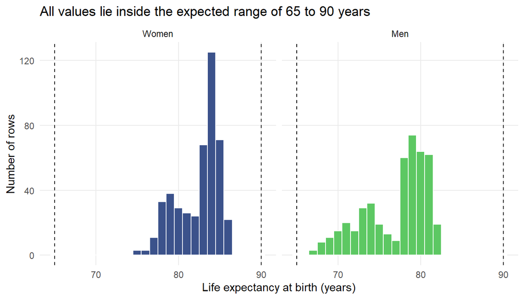

```r
# 3.1.2 Check 3: the distribution of life expectancy values, women and men apart
life_expectancy_clean |>
  ggplot(aes(x = life_expectancy, fill = sex)) +     # one number, so a histogram (class 10_1)
  geom_histogram(binwidth = 1,
                 color = "white") +                  # one bar per year, white gaps between bars
  scale_fill_viridis_d(begin = 0.25, end = 0.75) +   # course palette: blue for women, green for men
  geom_vline(xintercept = c(65, 90),
             linetype = "dashed") +                  # the expected range
  facet_wrap(~ sex,
             labeller = as_labeller(c(F = "Women", M = "Men"))) +   # one panel per sex
  labs(title = "All values lie inside the expected range of 65 to 90 years",   # the title states the finding
       x = "Life expectancy at birth (years)",
       y = "Number of rows") +
  theme_minimal() +                                  # white background, light grid
  theme(legend.position = "none",                    # the panel titles already name the sexes
        panel.grid.minor = element_blank())          # fewer lines that carry no data
```

**Result:** the values run from 66.8 to 86.5 years, all inside the expected range of 65 to 90. Half of the rows lie between 78.1 and 83.5 years (the middle line of the table in Check 2). No value points to a wrong age class or a wrong unit.

#### Check 4: duplicates

Each combination of country, sex and year should appear only once. If the number of distinct combinations equals the number of rows, no row repeats.

```r
# 3.1.2 Check 4: compare all rows with distinct country, sex and year combinations
nrow(life_expectancy_clean)   # all rows
```

```
[1] 906
```

```r
life_expectancy_clean |>
  distinct(country_code, sex, year) |>   # each combination once
  nrow()
```

```
[1] 906
```

**Result:** both counts are 906. Every combination of country, sex and year appears exactly once, so the table has no duplicates.

#### Check 5: row counts

With 10 years and 2 sexes, every geographic unit should have 20 rows. `count()` gives the number of rows per unit, and a bar chart shows all 53 units at once (class 10_2). `fct_reorder()` sorts the bars by length, `coord_flip()` turns them sideways so the codes are readable, and `geom_hline()` draws the expected 20 rows as a line. EU member states are orange and all other units purple, from the `plasma` palette of the viridis family. Red is not used here, because in this project it is kept for the Baltic states.

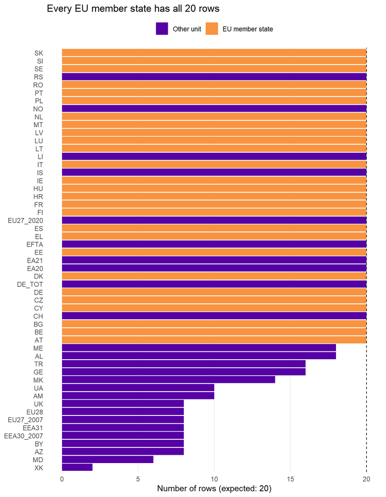

```r
# 3.1.2 Check 5: number of rows per geographic unit, EU member states in orange
life_expectancy_clean |>
  count(country_code) |>                                  # n = number of rows per unit
  mutate(eu = country_code %in% eu_codes,                 # TRUE for the 27 member states
         country_code = fct_reorder(country_code, n)) |>  # sort the bars by n
  ggplot(aes(x = country_code, y = n, fill = eu)) +      # one bar per unit, coloured by EU or not
  geom_col() +                                            # bar length = the number of rows
  geom_hline(yintercept = 20, linetype = "dashed") +      # the expected 20 rows
  coord_flip() +                                          # bars sideways, codes readable
  scale_fill_viridis_d(option = "plasma",
                       begin = 0.15, end = 0.75,                    # purple and orange, no red
                       labels = c("Other unit", "EU member state"), # FALSE comes first, then TRUE
                       name = NULL) +
  labs(title = "Every EU member state has all 20 rows",   # the title states the finding
       x = NULL,                                         # the country codes need no axis title
       y = "Number of rows (expected: 20)") +
  theme_minimal() +                                  # white background, light grid
  theme(legend.position = "top",
        panel.grid.minor = element_blank(),
        panel.grid.major.y = element_blank())              # the bars need no horizontal grid
```

```r
# 3.1.2 Check 5: count the rows of the EU member states, without removing anything
life_expectancy_clean |>
  filter(country_code %in% eu_codes) |>   # look at the member states only
  nrow()                                  # expected: 27 x 2 x 10 = 540
```

```
[1] 540
```

Finally, the columns `freq`, `unit` and `age` should each hold only one value, because they were fixed in the download link.

```r
# 3.1.2 Check 5: columns fixed in the link: each should have only one value
life_expectancy_clean |>
  distinct(freq, unit, age) |>   # one row means each column has one value
  kable()                        # show the result as a neat table
```

| freq | unit | age |
| --- | --- | --- |
| A | YR | Y_LT1 |

**Result:** all 27 EU member states have the full 20 rows, 540 rows together, as expected. The units with fewer than 20 rows are all outside the focus: non-EU countries such as `XK` (2 rows), `MD` (6) and `UK` (8), and old aggregates such as `EU28` and `EU27_2007` (8 each). `freq`, `unit` and `age` each hold a single value (`A`, `YR`, `Y_LT1`), so they carry no information and can be removed.

### 3.1.3 Summary: what was found, what was decided

| Check | What was found | Decision |
| --- | --- | --- |
| 1 Types | `life_expectancy` and `year` are numbers, the flags did not turn them into text | No change needed |
| 2 Missing values | No missing values. 146 of 906 values carry a flag, none in the Baltic states | Flagged values are kept |
| 3 Units and ranges | 66.8 to 86.5 years, all inside the expected range | No change needed |
| 4 Duplicates | Every country, sex and year appears once | No change needed |
| 5 Row counts | All 27 EU member states complete (540 rows). The incomplete units are all non-EU countries or aggregates | Only the 27 EU member states are kept, using `eu_codes` |
| 5 Columns fixed in the link | `freq`, `unit` and `age` hold one value each. `conf_status` is empty. `dataflow` and `last_update` describe the download, not the data | These six technical columns are removed. The `last_update` date is reported once, in the source line |

After these decisions, `life_expectancy_clean` keeps five columns: `country_code`, `sex`, `year`, `life_expectancy` and `flag`. The `flag` column stays, so that estimated or provisional values can still be recognised later, for example when an outlier is checked in Section 5.

### 3.1.4 Apply the decisions

The decisions from 3.1.3 are applied in two steps, and the row count is checked after each one.

#### Keep only the EU member states

`filter()` keeps only the rows whose country code is in `eu_codes`. This removes the non-EU countries, such as `NO` and `UK`, and the aggregates, such as `EU27_2020` and `EA20`. The aggregates would otherwise count every country twice: once on its own and once inside the EU total.

```r
# 3.1.4 Keep only the 27 EU member states
nrow(life_expectancy_clean)   # before: 906 rows
```

```
[1] 906
```

```r
life_expectancy_clean <- life_expectancy_clean |>
  filter(country_code %in% eu_codes)   # drop non-EU countries and aggregates such as EU27_2020

nrow(life_expectancy_clean)   # after: expected 27 x 2 x 10 = 540
```

```
[1] 540
```

**What it shows:** 906 rows before and 540 after. The 366 removed rows are the non-EU countries and the aggregates.

#### Remove the technical columns

`select()` keeps only the columns that are listed, in the order they are listed. Naming the five columns to keep, instead of the six to drop, makes the final table visible in the code itself.

```r
# 3.1.4 Keep the five columns the analysis uses
life_expectancy_clean <- life_expectancy_clean |>
  select(country_code, sex, year, life_expectancy, flag)   # everything else is dropped

glimpse(life_expectancy_clean)   # expected: 540 rows, 5 columns
```

```
Rows: 540
Columns: 5
$ country_code    <chr> "AT", "AT", "AT", "AT", "AT", "AT", "AT", "AT", "AT", …
$ sex             <chr> "F", "F", "F", "F", "F", "F", "F", "F", "F", "F", "F",…
$ year            <dbl> 2015, 2016, 2017, 2018, 2019, 2020, 2021, 2022, 2023, …
$ life_expectancy <dbl> 83.6, 84.0, 83.9, 84.0, 84.2, 83.7, 83.7, 83.8, 84.2, …
$ flag            <chr> NA, NA, NA, NA, NA, NA, NA, NA, NA, NA, NA, NA, NA, NA…
```

**What it shows:** the clean table, with 540 rows and 5 columns. `country_code`, `sex` and `flag` are text, `year` and `life_expectancy` are numbers. This is the life expectancy table that goes into Section 4.

### 3.1.5 Save the clean table

The clean life expectancy table is saved to `data/clean/` at the end of this sub-section, right after it is created. Section 4 starts from this file, so each part of the analysis can be rerun on its own. Like the panel in 4.5, the file is created by the code and can always be recreated by running this sub-section again.

```r
# 3.1.5 Save the clean life expectancy table to data/clean/
write_csv(life_expectancy_clean, here("data", "clean", "life_expectancy_clean.csv"))   # 540 rows
```

**What it shows:** nothing on screen. The file `data/clean/life_expectancy_clean.csv` is created or replaced.

## 3.2 Healthy life years

The healthy life years table goes through the same four stages as the life expectancy table in 3.1. The code follows the same pattern, so only what is new is explained in detail. The first look in 2.2.3 already showed one new problem: Luxembourg has no values for 2023 and 2024.

| Stage | What happens | Result |
| --- | --- | --- |
| 3.2.1 | Tidy the column names | Readable names, same data |
| 3.2.2 | Run the five quality checks | One result per check |
| 3.2.3 | Summarise what was found and decide, including Luxembourg | A table of decisions |
| 3.2.4 | Apply the decisions | `healthy_life_years_clean`, EU only, key columns only |

### 3.2.1 Tidy the column names

Same as in 3.1.1: `clean_names()` makes every name lowercase with underscores, and `rename()` gives the four key columns names that say what they hold. The value column becomes `healthy_life_years`. The column `hlth_hle` (the health indicator, `HLY_Y0` in every row) takes the place of `age` in the life expectancy table and keeps its name until it is removed in 3.2.4.

| Eurostat name | After `clean_names()` | After `rename()` |
| --- | --- | --- |
| `geo` | `geo` | `country_code` |
| `TIME_PERIOD` | `time_period` | `year` |
| `OBS_VALUE` | `obs_value` | `healthy_life_years` |
| `OBS_FLAG` | `obs_flag` | `flag` |

```r
# 3.2.1 Make the column names readable
healthy_life_years_clean <- healthy_life_years_raw |>   # start from the untouched raw table
  clean_names() |>                                      # for example TIME_PERIOD becomes time_period
  rename(country_code       = geo,                      # new name = old name
         year               = time_period,              # the year, a key for the join in Section 4
         healthy_life_years = obs_value,                # the value: healthy life years at birth
         flag               = obs_flag)                 # e, p, b ... how the value was produced

names(healthy_life_years_clean)   # list the new column names, expected: 11
```

```
 [1] "dataflow"           "last_update"        "freq"
 [4] "unit"               "sex"                "hlth_hle"
 [7] "country_code"       "year"               "healthy_life_years"
[10] "flag"               "conf_status"
```

**What it shows:** the same 11 columns. Four of them have new names: `country_code`, `year`, `healthy_life_years` and `flag`. The technical columns (`dataflow`, `last_update`, `freq`, `unit`, `hlth_hle`, `conf_status`) keep their names for now and are removed after the checks.

### 3.2.2 The five quality checks

The checks run on all 618 rows, before anything is removed. The code is the same as in 3.1.2, applied to the new table. Two things differ: healthy life years are lower than life expectancy, so the expected range is different, and one EU member state is incomplete, which Check 5 is built to show.

#### Check 1: types

```r
# 3.2.2 Check 1: the type of every column
glimpse(healthy_life_years_clean)   # healthy_life_years and year should be <dbl>
```

```
Rows: 618
Columns: 11
$ dataflow           <chr> "ESTAT:HLTH_HLYE(1.0)", "ESTAT:HLTH_HLYE(1.0)", "ES…
$ last_update        <chr> "17/07/26 23:00:00", "17/07/26 23:00:00", "17/07/26…
$ freq               <chr> "A", "A", "A", "A", "A", "A", "A", "A", "A", "A", "…
$ unit               <chr> "YR", "YR", "YR", "YR", "YR", "YR", "YR", "YR", "YR…
$ sex                <chr> "F", "F", "F", "F", "F", "F", "F", "F", "F", "F", "…
$ hlth_hle           <chr> "HLY_Y0", "HLY_Y0", "HLY_Y0", "HLY_Y0", "HLY_Y0", "…
$ country_code       <chr> "AT", "AT", "AT", "AT", "AT", "AT", "AT", "AT", "AT…
$ year               <dbl> 2015, 2016, 2017, 2018, 2019, 2020, 2021, 2022, 202…
$ healthy_life_years <dbl> 58.1, 57.1, 56.8, 57.0, 58.0, 59.3, 61.3, 61.3, 60.…
$ flag               <chr> NA, NA, NA, NA, NA, NA, NA, NA, NA, NA, NA, NA, NA,…
$ conf_status        <lgl> NA, NA, NA, NA, NA, NA, NA, NA, NA, NA, NA, NA, NA,…
```

**Result:** `healthy_life_years` and `year` are numbers. All other columns are text, except `conf_status`, which R reads as logical because it is empty.

#### Check 2: missing values

The same two tables as in 3.1.2: `tbl_summary()` for the value and `sex`, and a separate count of the flags.

```r
# 3.2.2 Check 2: missing values and spread of the key columns
healthy_life_years_clean |>                                  # the renamed table, all 618 rows
  tbl_summary(
    include   = c(healthy_life_years, sex),                  # the two columns to check
    type      = healthy_life_years ~ "continuous2",          # show the number on several lines
    statistic = healthy_life_years ~ c("{median} ({p25} to {p75})",   # middle half
                                       "{min} to {max}"),             # full range
    label     = list(healthy_life_years ~ "Healthy life years at birth", # readable row names
                     sex ~ "Sex"),
    missing      = "always",                                 # a Missing row, even if it is 0
    missing_text = "Missing"                                 # the word shown in that row
  )
```

| **Characteristic** | **N = 618**<sup>1</sup> |
| --- | --- |
| Healthy life years at birth |  |
| Median (Q1 to Q3) | 62.5 (59.0 to 65.4) |
| Min to Max | 50.6 to 74.6 |
| Missing | 0 |
| Sex |  |
| F | 309 (50%) |
| M | 309 (50%) |
| Missing | 0 |

<sup>1</sup> n (%)

```r
# 3.2.2 Check 2: how many values carry a flag, and which one
healthy_life_years_clean |>                         # the renamed table, all 618 rows
  count(flag, sort = TRUE) |>                       # most common flag first
  kable(col.names = c("Flag", "Number of values"))  # NA here means "no flag"
```

| Flag | Number of values |
| --- | --- |
| NA | 538 |
| b | 56 |
| p | 8 |
| bp | 4 |
| e | 4 |
| be | 2 |
| bep | 2 |
| bu | 2 |
| ep | 2 |

This table has one flag letter that the life expectancy table did not have: `u`, which Eurostat uses for “low reliability”. It appears together with `b` as `bu`.

```r
# 3.2.2 Check 2: which values are marked as low reliability (u)
healthy_life_years_clean |>                              # the renamed table, all 618 rows
  filter(str_detect(flag, "u")) |>                       # keep rows whose flag contains the letter u
  select(country_code, sex, year, healthy_life_years, flag) |>   # only the columns worth reading
  kable()                                                # show the result as a neat table
```

| country_code | sex | year | healthy_life_years | flag |
| --- | --- | --- | --- | --- |
| DE | F | 2022 | 61.2 | bu |
| DE | M | 2022 | 60.9 | bu |

**Result:** no value of `healthy_life_years` is missing, and the median is 62.5 years. `sex` holds only `F` and `M`, with 309 rows each. “Missing 0” only covers empty cells. Years that are absent from the file, as for Luxembourg, are not counted here and only appear in the row counts of Check 5. 80 of the 618 values carry a flag, most often `b` (56 values, a break in the series), then `p` (8), `e` (4), `bp` (4), `be` (2), `bep` (2), `bu` (2) and `ep` (2). As in 3.1, flagged values are kept. The only values marked as low reliability are the two German values for 2022 (61.2 years for women, 60.9 for men). Germany is not a focus country, but a jump for Germany in 2022 in Section 5 has to be read with this flag in mind. In the EU, 70 of 536 values carry a flag. In the Baltic states only the two Lithuanian values for 2024 do, marked `p` (provisional). `conf_status` is empty in all 618 rows.

#### Check 3: units and ranges

Healthy life years are always fewer than total life expectancy, because they count only the years without limitations in daily activities. In the EU they are expected to lie roughly between 45 and 80 years. A value outside this range would point to an error, for example a wrong indicator.

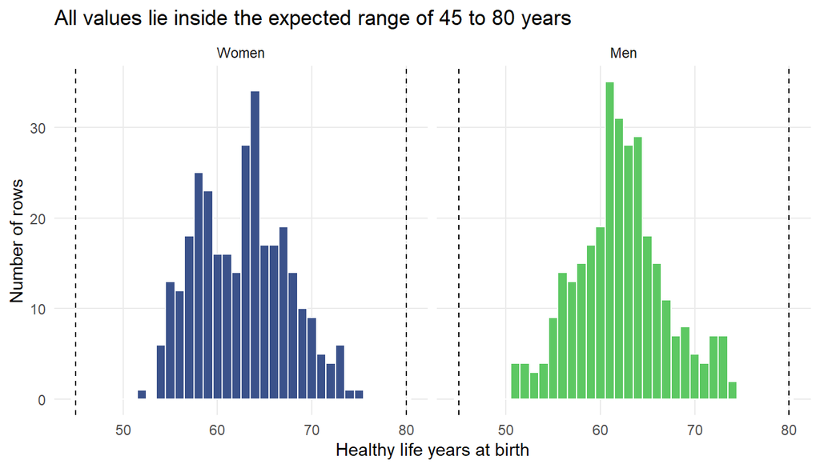

```r
# 3.2.2 Check 3: the distribution of healthy life years, women and men apart
healthy_life_years_clean |>
  ggplot(aes(x = healthy_life_years, fill = sex)) +  # one number, so a histogram (class 10_1)
  geom_histogram(binwidth = 1,
                 color = "white") +                  # one bar per year, white gaps between bars
  scale_fill_viridis_d(begin = 0.25, end = 0.75) +   # same colours as in 3.1: blue women, green men
  geom_vline(xintercept = c(45, 80),
             linetype = "dashed") +                  # the expected range
  facet_wrap(~ sex,
             labeller = as_labeller(c(F = "Women", M = "Men"))) +   # one panel per sex
  labs(title = "All values lie inside the expected range of 45 to 80 years",   # the title states the finding
       x = "Healthy life years at birth",
       y = "Number of rows") +
  theme_minimal() +                                  # white background, light grid
  theme(legend.position = "none",                    # the panel titles already name the sexes
        panel.grid.minor = element_blank())          # fewer lines that carry no data
```

**Result:** the values run from 50.6 to 74.6 years, all inside the expected range of 45 to 80. The lowest value in the whole table belongs to Latvian men in 2017. No value points to a wrong indicator or a wrong unit.

#### Check 4: duplicates

```r
# 3.2.2 Check 4: compare all rows with distinct country, sex and year combinations
nrow(healthy_life_years_clean)            # all rows, expected: 618
```

```
[1] 618
```

```r
healthy_life_years_clean |>
  distinct(country_code, sex, year) |>    # each combination once
  nrow()                                  # the same number means no duplicates
```

```
[1] 618
```

**Result:** both counts are 618. Every combination of country, sex and year appears exactly once, so the table has no duplicates.

#### Check 5: row counts

The same bar chart as in 3.1.2. Every unit should have 20 rows (10 years, 2 sexes). This is the check where the missing years of Luxembourg become visible.

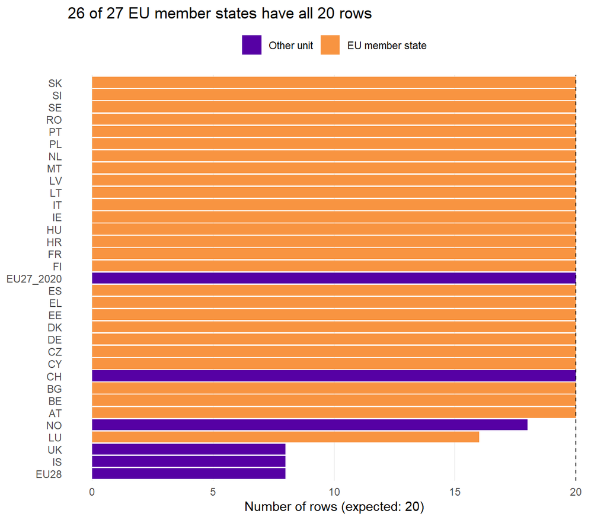

```r
# 3.2.2 Check 5: number of rows per geographic unit, EU member states in orange
healthy_life_years_clean |>
  count(country_code) |>                                  # n = number of rows per unit
  mutate(eu = country_code %in% eu_codes,                 # TRUE for the 27 member states
         country_code = fct_reorder(country_code, n)) |>  # sort the bars by n
  ggplot(aes(x = country_code, y = n, fill = eu)) +      # one bar per unit, coloured by EU or not
  geom_col() +                                            # bar length = the number of rows
  geom_hline(yintercept = 20, linetype = "dashed") +      # the expected 20 rows
  coord_flip() +                                          # bars sideways, codes readable
  scale_fill_viridis_d(option = "plasma",
                       begin = 0.15, end = 0.75,                    # purple and orange, no red
                       labels = c("Other unit", "EU member state"), # FALSE comes first, then TRUE
                       name = NULL) +
  labs(title = "26 of 27 EU member states have all 20 rows",   # the title states the finding
       x = NULL,                                         # the country codes need no axis title
       y = "Number of rows (expected: 20)") +
  theme_minimal() +                                       # white background, light grid
  theme(legend.position = "top",
        panel.grid.minor = element_blank(),
        panel.grid.major.y = element_blank())              # the bars need no horizontal grid
```

The incomplete EU member state is looked at more closely: which years and which sex are missing?

```r
# 3.2.2 Check 5: the years that Luxembourg has, for each sex
healthy_life_years_clean |>
  filter(country_code == "LU") |>     # Luxembourg only
  count(sex, year) |>                 # one row per sex and year that exists
  count(sex, name = "years") |>       # how many years each sex has, expected: 10
  kable()                             # show the result as a neat table
```

| sex | years |
| --- | --- |
| F | 8 |
| M | 8 |

```r
# 3.2.2 Check 5: count the rows of the EU member states, without removing anything
healthy_life_years_clean |>
  filter(country_code %in% eu_codes) |>   # look at the member states only
  nrow()                                  # a complete table would have 27 x 2 x 10 = 540
```

```
[1] 536
```

```r
# 3.2.2 Check 5: columns fixed in the link: each should have only one value
healthy_life_years_clean |>
  distinct(freq, unit, hlth_hle) |>   # one row means each column has one value
  kable()                             # show the result as a neat table
```

| freq | unit | hlth_hle |
| --- | --- | --- |
| A | YR | HLY_Y0 |

**Result:** 26 of the 27 EU member states have the full 20 rows. Luxembourg has 16: 8 years for each sex, with 2023 and 2024 missing for both. The EU part of the table therefore has 536 rows instead of 540. The other incomplete units are all outside the focus: `NO` (18 rows, 2021 missing), `IS`, `UK` and the old aggregate `EU28` (8 each). `freq`, `unit` and `hlth_hle` each hold a single value (`A`, `YR`, `HLY_Y0`), so they carry no information and can be removed.

### 3.2.3 Summary: what was found, what was decided

| Check | What was found | Decision |
| --- | --- | --- |
| 1 Types | `healthy_life_years` and `year` are numbers, the flags did not turn them into text | No change needed |
| 2 Missing values | No empty cells. 80 of 618 values carry a flag. Germany’s two values for 2022 are marked low reliability (`bu`). In the Baltic states only Lithuania’s 2024 values carry a flag (`p`) | Flagged values are kept, as in 3.1. The German 2022 values are kept and noted for Section 5 |
| 3 Units and ranges | 50.6 to 74.6 years, all inside the expected range of 45 to 80 | No change needed |
| 4 Duplicates | Every country, sex and year appears once | No change needed |
| 5 Row counts | 26 of 27 EU member states complete. Luxembourg has no values for 2023 and 2024 (536 EU rows instead of 540) | Only the 27 EU member states are kept, using `eu_codes`. Luxembourg is kept with its 16 real values. Its 2023 and 2024 stay missing and are not filled in |
| 5 Columns fixed in the link | `freq`, `unit` and `hlth_hle` hold one value each. `conf_status` is empty. `dataflow` and `last_update` describe the download, not the data | These six technical columns are removed. The `last_update` date is reported once, in the source line |

After these decisions, `healthy_life_years_clean` keeps five columns: `country_code`, `sex`, `year`, `healthy_life_years` and `flag`, the same structure as `life_expectancy_clean`.

**Why Luxembourg is kept.** Three options were considered: keep Luxembourg with the two missing years, drop Luxembourg from this table, or shorten the period to 2015 to 2022 for every country. Dropping Luxembourg would discard 16 real values to avoid 4 missing ones. Shortening the period would remove the two most recent years for all 27 countries, including the Baltic states. Keeping Luxembourg loses no real data and invents none. After the join in Section 4, its healthy life years for 2023 and 2024 appear as `NA`, and the gap is named in Section 7.

### 3.2.4 Apply the decisions

The same two steps as in 3.1.4, with the row count checked after each one.

#### Keep only the EU member states

```r
# 3.2.4 Keep only the 27 EU member states
nrow(healthy_life_years_clean)   # before: 618 rows
```

```
[1] 618
```

```r
healthy_life_years_clean <- healthy_life_years_clean |>   # overwrite the table with the filtered version
  filter(country_code %in% eu_codes)                      # drop non-EU countries and aggregates such as EU27_2020

nrow(healthy_life_years_clean)   # after: expected 536 (540 minus Luxembourg's 4 missing rows)
```

```
[1] 536
```

**What it shows:** 618 rows before and 536 after. The 82 removed rows are the non-EU countries and the aggregates. The count is 536, not 540, because Luxembourg’s 2023 and 2024 were never in the file.

#### Remove the technical columns

```r
# 3.2.4 Keep the five columns the analysis uses
healthy_life_years_clean <- healthy_life_years_clean |>             # overwrite the table again
  select(country_code, sex, year, healthy_life_years, flag)         # everything else is dropped

glimpse(healthy_life_years_clean)   # expected: 536 rows, 5 columns
```

```
Rows: 536
Columns: 5
$ country_code       <chr> "AT", "AT", "AT", "AT", "AT", "AT", "AT", "AT", "AT…
$ sex                <chr> "F", "F", "F", "F", "F", "F", "F", "F", "F", "F", "…
$ year               <dbl> 2015, 2016, 2017, 2018, 2019, 2020, 2021, 2022, 202…
$ healthy_life_years <dbl> 58.1, 57.1, 56.8, 57.0, 58.0, 59.3, 61.3, 61.3, 60.…
$ flag               <chr> NA, NA, NA, NA, NA, NA, NA, NA, NA, NA, NA, NA, NA,…
```

**What it shows:** the clean table, with 536 rows and 5 columns, the same five columns as `life_expectancy_clean` except for the name of the value column. This is the healthy life years table that goes into Section 4.

### 3.2.5 Save the clean table

The clean healthy life years table is saved to `data/clean/` at the end of this sub-section, right after it is created. Section 4 starts from this file, so each part of the analysis can be rerun on its own. Like the panel in 4.5, the file is created by the code and can always be recreated by running this sub-section again.

```r
# 3.2.5 Save the clean healthy life years table to data/clean/
write_csv(healthy_life_years_clean, here("data", "clean", "healthy_life_years_clean.csv"))   # 536 rows
```

**What it shows:** nothing on screen. The file `data/clean/healthy_life_years_clean.csv` is created or replaced.

## 3.3 Deaths by cause

The deaths table goes through the same four stages as the first two tables. It is larger and has one more dimension, the cause of death, so the checks also look at the causes. The first look in 2.3.3 already showed one new problem: “all causes” is coded `TOTAL` in some years and `A-R_V-Y` in others.

| Stage | What happens | Result |
| --- | --- | --- |
| 3.3.1 | Tidy the column names | Readable names, same data |
| 3.3.2 | Run the five quality checks | One result per check |
| 3.3.3 | Summarise what was found and decide, including the two “all causes” codes and the chapters of causes | A table of decisions |
| 3.3.4 | Apply the decisions | `deaths_clean` |

### 3.3.1 Tidy the column names

Same as in 3.1.1 and 3.2.1. The value column becomes `death_rate`. The extra column `icd10` becomes `cause_code`, because it holds the code of the cause of death, and the name should say what it holds, not which classification system it comes from.

| Eurostat name | After `clean_names()` | After `rename()` |
| --- | --- | --- |
| `geo` | `geo` | `country_code` |
| `TIME_PERIOD` | `time_period` | `year` |
| `icd10` | `icd10` | `cause_code` |
| `OBS_VALUE` | `obs_value` | `death_rate` |
| `OBS_FLAG` | `obs_flag` | `flag` |

```r
# 3.3.1 Make the column names readable
deaths_clean <- deaths_raw |>                  # start from the untouched raw table
  clean_names() |>                             # for example TIME_PERIOD becomes time_period
  rename(country_code = geo,                   # new name = old name
         year         = time_period,           # the year, a key for the join in Section 4
         cause_code   = icd10,                 # the ICD-10 code of the cause of death
         death_rate   = obs_value,             # the value: deaths per 100 000, under 65
         flag         = obs_flag)              # e, p, b ... how the value was produced

names(deaths_clean)   # list the new column names, expected: 12
```

```
 [1] "dataflow"     "last_update"  "freq"         "unit"         "sex"
 [6] "age"          "cause_code"   "country_code" "year"         "death_rate"
[11] "flag"         "conf_status"
```

**What it shows:** the same 12 columns. Five of them have new names: `country_code`, `year`, `cause_code`, `death_rate` and `flag`.

### 3.3.2 The five quality checks

The checks run on all 43 902 rows, before anything is removed. The code follows 3.1.2 and 3.2.2. What is new: the countries were already limited to the EU in the download link, and there is one more dimension to check, the cause of death.

#### Check 1: types

```r
# 3.3.2 Check 1: the type of every column
glimpse(deaths_clean)   # death_rate and year should be <dbl>
```

```
Rows: 43,902
Columns: 12
$ dataflow     <chr> "ESTAT:HLTH_CD_ASDR2(1.0)", "ESTAT:HLTH_CD_ASDR2(1.0)", "…
$ last_update  <chr> "08/06/26 23:00:00", "08/06/26 23:00:00", "08/06/26 23:00…
$ freq         <chr> "A", "A", "A", "A", "A", "A", "A", "A", "A", "A", "A", "A…
$ unit         <chr> "RT", "RT", "RT", "RT", "RT", "RT", "RT", "RT", "RT", "RT…
$ sex          <chr> "F", "F", "F", "F", "F", "F", "F", "F", "F", "F", "F", "F…
$ age          <chr> "Y_LT65", "Y_LT65", "Y_LT65", "Y_LT65", "Y_LT65", "Y_LT65…
$ cause_code   <chr> "A-R_V-Y", "A-R_V-Y", "A-R_V-Y", "A-R_V-Y", "A-R_V-Y", "A…
$ country_code <chr> "AT", "AT", "AT", "AT", "BE", "BE", "BE", "BE", "BG", "BG…
$ year         <dbl> 2018, 2019, 2020, 2021, 2018, 2019, 2020, 2021, 2018, 201…
$ death_rate   <dbl> 114.85, 110.88, 111.59, 111.89, 135.44, 128.97, 131.22, 1…
$ flag         <lgl> NA, NA, NA, NA, NA, NA, NA, NA, NA, NA, NA, NA, NA, NA, N…
$ conf_status  <lgl> NA, NA, NA, NA, NA, NA, NA, NA, NA, NA, NA, NA, NA, NA, N…
```

**Result:** `death_rate` and `year` are numbers. `country_code`, `sex` and `cause_code` are text. `flag` and `conf_status` are read as logical, because they are empty in every row.

#### Check 2: missing values

The same two tables as before: `tbl_summary()` for the value and `sex`, and a count of the flags.

```r
# 3.3.2 Check 2: missing values and spread of the key columns
deaths_clean |>                                          # the renamed table, all 43 902 rows
  tbl_summary(
    include   = c(death_rate, sex),                      # the two columns to check
    type      = death_rate ~ "continuous2",              # show the number on several lines
    statistic = death_rate ~ c("{median} ({p25} to {p75})",   # middle half
                               "{min} to {max}"),             # full range
    label     = list(death_rate ~ "Death rate under 65 (per 100 000)",   # readable row names
                     sex ~ "Sex"),
    missing      = "always",                             # a Missing row, even if it is 0
    missing_text = "Missing"                             # the word shown in that row
  )
```

| **Characteristic** | **N = 43,902**<sup>1</sup> |
| --- | --- |
| Death rate under 65 (per 100 000) |  |
| Median (Q1 to Q3) | 2 (0 to 5) |
| Min to Max | 0 to 717 |
| Missing | 0 |
| Sex |  |
| F | 21,951 (50%) |
| M | 21,951 (50%) |
| Missing | 0 |

<sup>1</sup> n (%)

```r
# 3.3.2 Check 2: how many values carry a flag, and which one
deaths_clean |>                                     # the renamed table, all 43 902 rows
  count(flag, sort = TRUE) |>                       # most common flag first
  kable(col.names = c("Flag", "Number of values"))  # NA here means "no flag"
```

| Flag | Number of values |
| --- | --- |
| NA | 43902 |

**Result:** no value of `death_rate` is missing, and `sex` holds only `F` and `M`, with 21 951 rows each. No value carries a flag. The median death rate is only 1.7 per 100 000, and half of all values lie between 0.4 and 5.2, because most of the 93 causes are rare: 3 151 values are exactly 0 (no deaths from that cause under 65 in that country and year). The few large values belong to the broad groups such as all causes or circulatory diseases. A zero is a real count, not a missing value, so it is kept.

#### Check 3: units and ranges

A histogram of all 43 902 values would mix rare causes, close to 0, with the broad groups, in the hundreds, and show little. The range check therefore looks at the one value that must be plausible in every country and year: the death rate from all causes. It is coded `TOTAL` in some years and `A-R_V-Y` in others (see 2.3.3), so both codes are kept here. Under 65, the death rate from all causes in the EU is expected to lie roughly between 50 and 1 000 per 100 000.

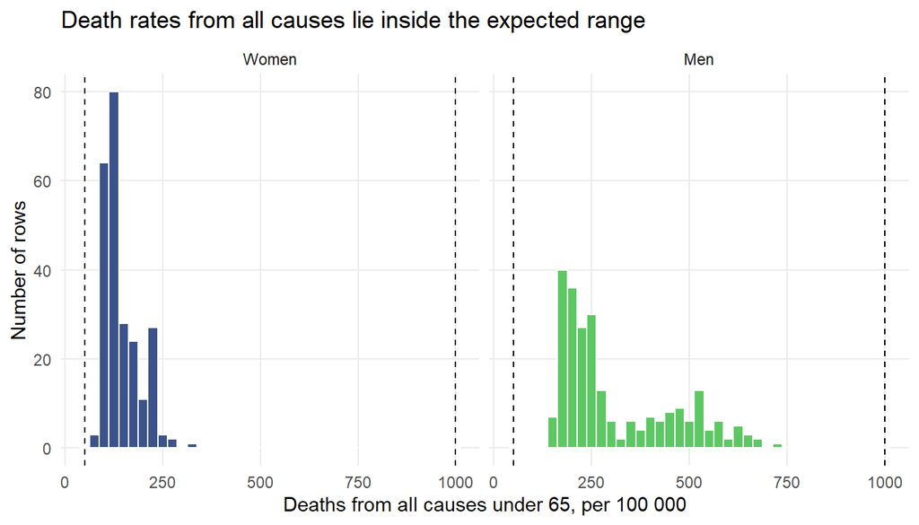

```r
# 3.3.2 Check 3: the distribution of the death rate from all causes, women and men apart
deaths_clean |>
  filter(cause_code %in% c("TOTAL", "A-R_V-Y")) |>  # all causes, under both of its codes
  ggplot(aes(x = death_rate, fill = sex)) +          # one number, so a histogram (class 10_1)
  geom_histogram(binwidth = 25,
                 color = "white") +                  # one bar per 25 deaths, white gaps between bars
  scale_fill_viridis_d(begin = 0.25, end = 0.75) +   # same colours as before: blue women, green men
  geom_vline(xintercept = c(50, 1000),
             linetype = "dashed") +                  # the expected range
  facet_wrap(~ sex,
             labeller = as_labeller(c(F = "Women", M = "Men"))) +   # one panel per sex
  labs(title = "Death rates from all causes lie inside the expected range",   # the title states the finding
       x = "Deaths from all causes under 65, per 100 000",
       y = "Number of rows") +
  theme_minimal() +                                  # white background, light grid
  theme(legend.position = "none",                    # the panel titles already name the sexes
        panel.grid.minor = element_blank())          # fewer lines that carry no data
```

**Result:** all 486 values (27 countries, 2 sexes, 9 years) lie inside the expected range. For women they run from 83 to 320 deaths per 100 000, for men from 146 to 717. The highest value is Latvian men in 2021, a COVID-19 year. The men’s panel has a second group of values between about 350 and 700: in some countries, men under 65 die at two to three times the rate of men elsewhere. Which countries these are is examined in Section 5.

#### Check 4: duplicates

In this table, one row should be one country, one sex, one cause and one year. The cause is part of the combination now, because every country, sex and year appears once for each cause.

```r
# 3.3.2 Check 4: compare all rows with distinct country, sex, cause and year combinations
nrow(deaths_clean)                                  # all rows, expected: 43 902
```

```
[1] 43902
```

```r
deaths_clean |>
  distinct(country_code, sex, cause_code, year) |>  # each combination once
  nrow()                                            # the same number means no duplicates
```

```
[1] 43902
```

**Result:** both counts are 43 902. Every combination of country, sex, cause and year appears exactly once, so the table has no duplicates.

#### Check 5: row counts

The 27 countries were selected in the download link, so the bar chart from 3.1.2 and 3.2.2 would only show 27 equal bars. Here the row counts answer four other questions: does every country have the same number of rows, how many causes exist in each year, which code holds “all causes” in each year, and do the columns fixed in the link hold one value each.

```r
# 3.3.2 Check 5: does every country have the same number of rows?
deaths_clean |>
  count(country_code) |>            # n = number of rows per country
  count(n, name = "countries") |>   # how many countries have each row count
  kable(col.names = c("Rows per country", "Number of countries"))   # one line means all equal
```

| Rows per country | Number of countries |
| --- | --- |
| 1626 | 27 |

```r
# 3.3.2 Check 5: how many different causes exist in each year?
deaths_clean |>
  distinct(year, cause_code) |>     # each cause once per year
  count(year, name = "causes") |>   # number of causes per year
  kable(col.names = c("Year", "Number of causes"))   # expected: 89 up to 2019, 92 from 2020
```

| Year | Number of causes |
| --- | --- |
| 2015 | 89 |
| 2016 | 89 |
| 2017 | 89 |
| 2018 | 89 |
| 2019 | 89 |
| 2020 | 92 |
| 2021 | 92 |
| 2022 | 92 |
| 2023 | 92 |

```r
# 3.3.2 Check 5: which code holds "all causes" in which year?
deaths_clean |>
  filter(cause_code %in% c("TOTAL", "A-R_V-Y")) |>   # the two codes for all causes
  distinct(year, cause_code) |>                      # one row per year and code
  arrange(year) |>                                   # in time order
  kable(col.names = c("Year", "Code for all causes")) # one code per year, never both
```

| Year | Code for all causes |
| --- | --- |
| 2015 | TOTAL |
| 2016 | TOTAL |
| 2017 | TOTAL |
| 2018 | A-R_V-Y |
| 2019 | A-R_V-Y |
| 2020 | A-R_V-Y |
| 2021 | A-R_V-Y |
| 2022 | TOTAL |
| 2023 | TOTAL |

```r
# 3.3.2 Check 5: columns fixed in the link: each should have only one value
deaths_clean |>
  distinct(freq, unit, age) |>   # one row means each column has one value
  kable()                        # show the result as a neat table
```

| freq | unit | age |
| --- | --- | --- |
| A | RT | Y_LT65 |

**Result:** all 27 countries have the same 1 626 rows, so no country is incomplete. Up to 2019 each year has 89 causes, from 2020 it has 92, because three COVID-19 codes were added. Every year has exactly one code for all causes: `TOTAL` in 2015 to 2017 and in 2022 to 2023, `A-R_V-Y` in 2018 to 2021. Never both in the same year, so the two codes can be treated as one without counting anything twice. `freq`, `unit` and `age` each hold a single value (`A`, `RT`, `Y_LT65`), the choices made in the link, so they can be removed.

### 3.3.3 Summary: what was found, what was decided

[output not shown]

**Why the two codes for all causes are merged.** Eurostat renamed the code for all causes in 2018 and changed it back in 2022. It is the same measure under two names. Keeping both would mean that every later filter has to ask for both codes, and forgetting it once would make four years disappear without an error. Dropping all causes would lose the best check that the chapters add up. Since no year has both codes, renaming `A-R_V-Y` to `TOTAL` is safe: no row is lost and nothing is counted twice.

**Why the level of each cause is marked, not split or left for later.** The analysis looks first at the chapters of causes, without choosing any cause, and only then deeper at the causes named in the hypotheses (see 2.3). A column `cause_level` makes both views one `filter()` away, and keeps every row. Splitting the table in two would mean two objects to keep in line, and leaving it to Section 5 would hide the chapter list inside the charts. The three COVID-19 codes count as chapter level, because without them the chapters would not add up to all causes from 2020 on.

### 3.3.4 Apply the decisions

Three steps, each followed by a check.

#### Merge the two codes for all causes

`case_when()` (class 04) goes through the rows and gives each one a value: where the condition on the left is true, it uses the value on the right. `.default = cause_code` keeps every other code as it was.

```r
# 3.3.4 Give "all causes" the same code, TOTAL, in every year
deaths_clean <- deaths_clean |>                         # overwrite the table with the changed version
  mutate(cause_code = case_when(
    cause_code == "A-R_V-Y" ~ "TOTAL",                  # the 2018 to 2021 code becomes TOTAL
    .default = cause_code                               # every other code stays as it is
  ))

deaths_clean |>
  filter(cause_code %in% c("TOTAL", "A-R_V-Y")) |>     # look for both codes again
  count(cause_code) |>                                  # rows per code
  kable(col.names = c("Code", "Rows"))                  # expected: only TOTAL, 486 rows
```

| Code | Rows |
| --- | --- |
| TOTAL | 486 |

**What it shows:** only `TOTAL` remains, with 486 rows: 27 countries, 2 sexes and 9 years. All causes now has one code in every year.

#### Mark the level of each cause

The 17 chapters of the ICD-10 classification and the 3 COVID-19 codes are listed once, as `chapter_codes`. `case_when()` then labels every row: `TOTAL` is “all causes”, the codes in the list are “chapter”, and everything else is “detail”.

| Code | Chapter |
| --- | --- |
| `A_B` | Infectious and parasitic diseases |
| `C00-D48` | Neoplasms (cancer and other tumours) |
| `D50-D89` | Diseases of the blood and the immune system |
| `E` | Endocrine, nutritional and metabolic diseases (for example diabetes) |
| `F` | Mental and behavioural disorders (including alcohol and drug use) |
| `G_H` | Diseases of the nervous system and the sense organs |
| `I` | Diseases of the circulatory system (heart and blood vessels) |
| `J` | Diseases of the respiratory system |
| `K` | Diseases of the digestive system (including the liver) |
| `L` | Diseases of the skin |
| `M` | Diseases of the musculoskeletal system |
| `N` | Diseases of the genitourinary system |
| `O` | Pregnancy and childbirth |
| `P` | Conditions from the perinatal period |
| `Q` | Congenital malformations |
| `R` | Ill-defined and unknown causes |
| `V01-Y89` | External causes (accidents, suicide, violence) |
| `U071`, `U072`, `U_COV19_OTH` | COVID-19, from 2020 |

```r
# 3.3.4 Mark each row as all causes, chapter or detail
chapter_codes <- c("A_B", "C00-D48", "D50-D89", "E", "F", "G_H", "I", "J", "K",   # the 17 ICD-10 chapters
                   "L", "M", "N", "O", "P", "Q", "R", "V01-Y89",
                   "U071", "U072", "U_COV19_OTH")                                 # COVID-19, from 2020

deaths_clean <- deaths_clean |>                          # overwrite the table with the new column
  mutate(cause_level = case_when(
    cause_code == "TOTAL"         ~ "all causes",        # the total of all deaths
    cause_code %in% chapter_codes ~ "chapter",           # the big groups that add up to the total
    .default                      = "detail"             # everything else sits inside a chapter
  ))

deaths_clean |>
  distinct(cause_code, cause_level) |>                   # each cause once
  count(cause_level) |>                                  # how many causes at each level
  kable(col.names = c("Level", "Number of causes"))      # expected: 1, 20 and 71 (92 codes after the merge)
```

| Level | Number of causes |
| --- | --- |
| all causes | 1 |
| chapter | 20 |
| detail | 71 |

**What it shows:** 92 causes in three levels: 1 for all causes, 20 at chapter level (17 chapters and 3 COVID-19 codes) and 71 detailed causes. The chapter view in Section 5 is now one `filter(cause_level == "chapter")` away.

#### Remove the technical columns

```r
# 3.3.4 Keep the seven columns the analysis uses
deaths_clean <- deaths_clean |>                                                  # overwrite the table again
  select(country_code, sex, year, cause_code, cause_level, death_rate, flag)   # everything else is dropped

glimpse(deaths_clean)   # expected: 43 902 rows, 7 columns
```

```
Rows: 43,902
Columns: 7
$ country_code <chr> "AT", "AT", "AT", "AT", "BE", "BE", "BE", "BE", "BG", "BG…
$ sex          <chr> "F", "F", "F", "F", "F", "F", "F", "F", "F", "F", "F", "F…
$ year         <dbl> 2018, 2019, 2020, 2021, 2018, 2019, 2020, 2021, 2018, 201…
$ cause_code   <chr> "TOTAL", "TOTAL", "TOTAL", "TOTAL", "TOTAL", "TOTAL", "TO…
$ cause_level  <chr> "all causes", "all causes", "all causes", "all causes", "…
$ death_rate   <dbl> 114.85, 110.88, 111.59, 111.89, 135.44, 128.97, 131.22, 1…
$ flag         <lgl> NA, NA, NA, NA, NA, NA, NA, NA, NA, NA, NA, NA, NA, NA, N…
```

**What it shows:** the clean table, with 43 902 rows and 7 columns: the same five columns as the first two tables, plus `cause_code` and `cause_level`. No row was removed in this section. This is the deaths table that goes into Section 4.

### 3.3.5 Save the clean table

The clean deaths table is saved to `data/clean/` at the end of this sub-section, right after it is created. Section 4 starts from this file, so each part of the analysis can be rerun on its own. Like the panel in 4.5, the file is created by the code and can always be recreated by running this sub-section again.

```r
# 3.3.5 Save the clean deaths table to data/clean/
write_csv(deaths_clean, here("data", "clean", "deaths_clean.csv"))   # 43 902 rows
```

**What it shows:** nothing on screen. The file `data/clean/deaths_clean.csv` is created or replaced.

## 3.4 GDP per capita

The GDP table goes through the same four stages. It is the simplest of the six tables: one value per country and year, with no sex and no cause. As in 3.1 and 3.2, the non-EU countries and aggregates are removed in this section.

| Stage | What happens | Result |
| --- | --- | --- |
| 3.4.1 | Tidy the column names | Readable names, same data |
| 3.4.2 | Run the five quality checks | One result per check |
| 3.4.3 | Summarise what was found and decide | A table of decisions |
| 3.4.4 | Apply the decisions | `gdp_clean`, EU only, key columns only |

### 3.4.1 Tidy the column names

Same as before. The value column becomes `gdp_pps_index`: GDP per person, in purchasing power standards, as an index with the EU average at 100. The name is long, but it says what the number is, so it cannot be mistaken for GDP in euros.

| Eurostat name | After `clean_names()` | After `rename()` |
| --- | --- | --- |
| `geo` | `geo` | `country_code` |
| `TIME_PERIOD` | `time_period` | `year` |
| `OBS_VALUE` | `obs_value` | `gdp_pps_index` |
| `OBS_FLAG` | `obs_flag` | `flag` |

```r
# 3.4.1 Make the column names readable
gdp_clean <- gdp_raw |>                        # start from the untouched raw table
  clean_names() |>                             # for example TIME_PERIOD becomes time_period
  rename(country_code  = geo,                  # new name = old name
         year          = time_period,          # the year, a key for the join in Section 4
         gdp_pps_index = obs_value,            # the value: GDP per person, EU27 = 100
         flag          = obs_flag)             # p = provisional

names(gdp_clean)   # list the new column names, expected: 10
```

```
 [1] "dataflow"      "last_update"   "freq"          "indic_ppp"
 [5] "ppp_cat18"     "country_code"  "year"          "gdp_pps_index"
 [9] "flag"          "conf_status"
```

**What it shows:** the same 10 columns. Four of them have new names: `country_code`, `year`, `gdp_pps_index` and `flag`.

### 3.4.2 The five quality checks

The checks run on all 430 rows, before anything is removed. The code follows 3.1.2, without `sex`, because GDP is one value per country and year.

#### Check 1: types

```r
# 3.4.2 Check 1: the type of every column
glimpse(gdp_clean)   # gdp_pps_index and year should be <dbl>
```

```
Rows: 430
Columns: 10
$ dataflow      <chr> "ESTAT:TEC00114(1.0)", "ESTAT:TEC00114(1.0)", "ESTAT:TEC…
$ last_update   <chr> "09/07/26 23:00:00", "09/07/26 23:00:00", "09/07/26 23:0…
$ freq          <chr> "A", "A", "A", "A", "A", "A", "A", "A", "A", "A", "A", "…
$ indic_ppp     <chr> "VI_PPS_EU27_2020_HAB", "VI_PPS_EU27_2020_HAB", "VI_PPS_…
$ ppp_cat18     <chr> "GDP", "GDP", "GDP", "GDP", "GDP", "GDP", "GDP", "GDP", …
$ country_code  <chr> "AL", "AL", "AL", "AL", "AL", "AL", "AL", "AL", "AL", "A…
$ year          <dbl> 2015, 2016, 2017, 2018, 2019, 2020, 2021, 2022, 2023, 20…
$ gdp_pps_index <dbl> 30, 30, 30, 30, 30, 30, 31, 33, 38, 42, 128, 128, 125, 1…
$ flag          <chr> NA, NA, NA, NA, NA, NA, NA, NA, NA, NA, NA, NA, NA, NA, …
$ conf_status   <lgl> NA, NA, NA, NA, NA, NA, NA, NA, NA, NA, NA, NA, NA, NA, …
```

**Result:** `gdp_pps_index` and `year` are numbers. `flag` is text, because 9 rows hold the letter `p`. `conf_status` is read as logical, because it is empty.

#### Check 2: missing values

```r
# 3.4.2 Check 2: missing values and spread of the GDP index
gdp_clean |>                                             # the renamed table, all 430 rows
  tbl_summary(
    include   = gdp_pps_index,                           # the one value column (no sex here)
    type      = gdp_pps_index ~ "continuous2",           # show the number on several lines
    statistic = gdp_pps_index ~ c("{median} ({p25} to {p75})",   # middle half
                                  "{min} to {max}"),             # full range
    label     = gdp_pps_index ~ "GDP per capita in PPS (EU27 = 100)",   # readable row name
    missing      = "always",                             # a Missing row, even if it is 0
    missing_text = "Missing"                             # the word shown in that row
  )
```

| **Characteristic** | **N = 430** |
| --- | --- |
| GDP per capita in PPS (EU27 = 100) |  |
| Median (Q1 to Q3) | 96 (70 to 118) |
| Min to Max | 30 to 279 |
| Missing | 0 |

```r
# 3.4.2 Check 2: how many values carry a flag, and which one
gdp_clean |>                                        # the renamed table, all 430 rows
  count(flag, sort = TRUE) |>                       # most common flag first
  kable(col.names = c("Flag", "Number of values"))  # NA here means "no flag"
```

| Flag | Number of values |
| --- | --- |
| NA | 421 |
| p | 9 |

**Result:** no value of `gdp_pps_index` is missing. The median is 96, close to the EU average of 100, and half of all values lie between 70 and 118. The full range runs from 30 (Albania, 2015) to 279 (Luxembourg, 2015). 9 values are marked `p` (provisional), all from 2023 or 2024, the most recent years, which Eurostat may still revise. As in the other tables, flagged values are kept.

#### Check 3: units and ranges

An index with the EU average at 100 is expected to lie roughly between 20 and 300 for European countries. A value far outside would point to a wrong indicator, for example GDP in euros instead of an index.

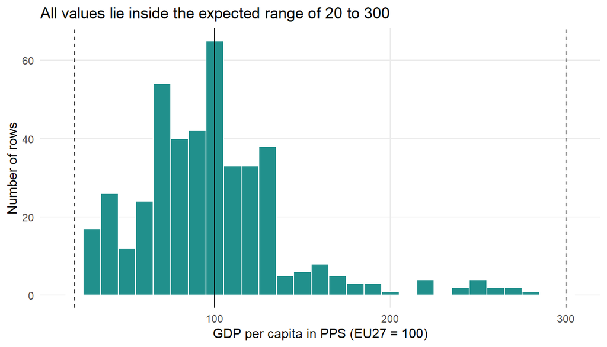

```r
# 3.4.2 Check 3: the distribution of the GDP index
gdp_clean |>
  ggplot(aes(x = gdp_pps_index)) +                   # one number, so a histogram (class 10_1)
  geom_histogram(binwidth = 10,
                 fill = "#21908C",                   # one colour from the viridis palette (teal)
                 color = "white") +                  # one bar per 10 index points, white gaps
  geom_vline(xintercept = c(20, 300),
             linetype = "dashed") +                  # the expected range
  geom_vline(xintercept = 100) +                     # the EU average, as a solid line
  labs(title = "All values lie inside the expected range of 20 to 300",   # the title states the finding
       x = "GDP per capita in PPS (EU27 = 100)",
       y = "Number of rows") +
  theme_minimal() +                                  # white background, light grid
  theme(panel.grid.minor = element_blank())          # fewer lines that carry no data
```

**Result:** all values lie inside the expected range of 20 to 300. Most units are close to the EU average, between about 50 and 140. The long tail on the right belongs to two EU countries and Norway: Luxembourg (244 to 279), Ireland (178 to 237) and Norway in 2021 to 2023 (up to 222, when energy prices were high). Luxembourg is high because many of the people who work there live in neighbouring countries, and Ireland because the profits of large international companies are booked there. Both are real values, but they make these two countries look richer than their residents are. This matters in Section 5: in a scatter plot against GDP, Luxembourg and Ireland will sit far to the right and can pull a trend line.

#### Check 4: duplicates

There is no sex in this table, so one row should be one country and one year.

```r
# 3.4.2 Check 4: compare all rows with distinct country and year combinations
nrow(gdp_clean)                        # all rows, expected: 430
```

```
[1] 430
```

```r
gdp_clean |>
  distinct(country_code, year) |>      # each combination once
  nrow()                               # the same number means no duplicates
```

```
[1] 430
```

**Result:** both counts are 430. Every combination of country and year appears exactly once, so the table has no duplicates.

#### Check 5: row counts

With 10 years and no sex dimension, every geographic unit should have 10 rows. The same bar chart as in 3.1.2 and 3.2.2.

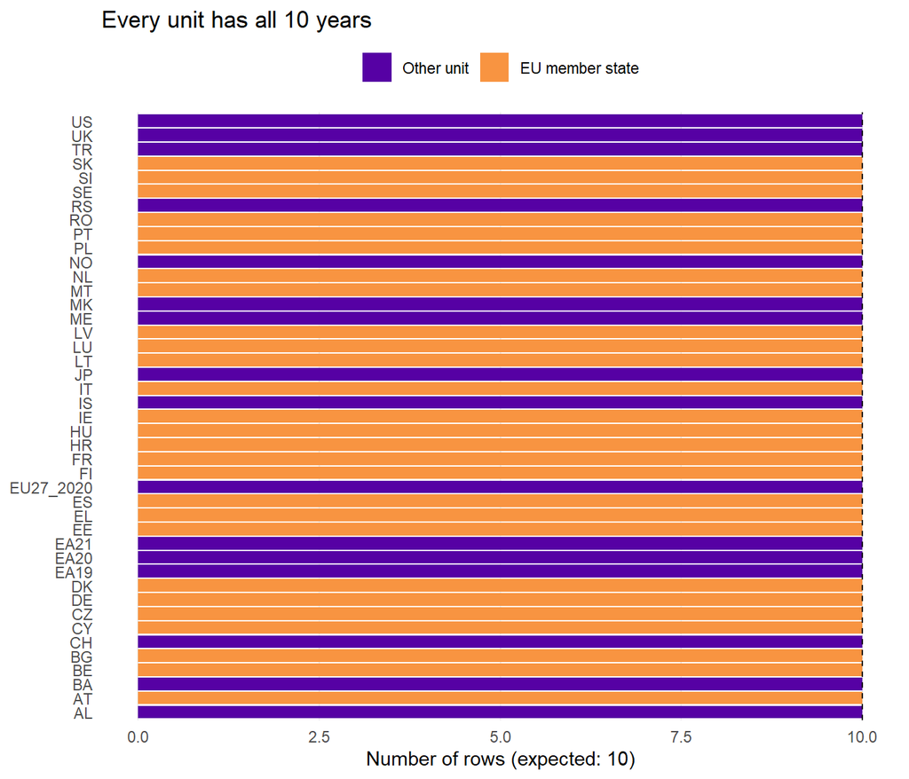

```r
# 3.4.2 Check 5: number of rows per geographic unit, EU member states in orange
gdp_clean |>
  count(country_code) |>                                  # n = number of rows per unit
  mutate(eu = country_code %in% eu_codes,                 # TRUE for the 27 member states
         country_code = fct_reorder(country_code, n)) |>  # sort the bars by n
  ggplot(aes(x = country_code, y = n, fill = eu)) +      # one bar per unit, coloured by EU or not
  geom_col() +                                            # bar length = the number of rows
  geom_hline(yintercept = 10, linetype = "dashed") +      # the expected 10 rows
  coord_flip() +                                          # bars sideways, codes readable
  scale_fill_viridis_d(option = "plasma",
                       begin = 0.15, end = 0.75,                    # purple and orange, no red
                       labels = c("Other unit", "EU member state"), # FALSE comes first, then TRUE
                       name = NULL) +
  labs(title = "Every unit has all 10 years",            # the title states the finding
       x = NULL,                                         # the country codes need no axis title
       y = "Number of rows (expected: 10)") +
  theme_minimal() +                                       # white background, light grid
  theme(legend.position = "top",
        panel.grid.minor = element_blank(),
        panel.grid.major.y = element_blank())              # the bars need no horizontal grid
```

```r
# 3.4.2 Check 5: count the rows of the EU member states, without removing anything
gdp_clean |>
  filter(country_code %in% eu_codes) |>   # look at the member states only
  nrow()                                  # expected: 27 x 10 = 270
```

```
[1] 270
```

```r
# 3.4.2 Check 5: columns fixed in the link: each should have only one value
gdp_clean |>
  distinct(freq, indic_ppp, ppp_cat18) |>   # one row means each column has one value
  kable()                                   # show the result as a neat table
```

| freq | indic_ppp | ppp_cat18 |
| --- | --- | --- |
| A | VI_PPS_EU27_2020_HAB | GDP |

**Result:** all 43 units have the full 10 rows, so no year is missing anywhere. The 27 EU member states have 270 rows together, as expected. `freq`, `indic_ppp` and `ppp_cat18` each hold a single value (`A`, `VI_PPS_EU27_2020_HAB`, `GDP`), the choices made in the link, so they can be removed.

### 3.4.3 Summary: what was found, what was decided

| Check | What was found | Decision |
| --- | --- | --- |
| 1 Types | `gdp_pps_index` and `year` are numbers | No change needed |
| 2 Missing values | No missing values. 9 values marked `p` (provisional), all from 2023 or 2024. None in the Baltic states | Flagged values are kept, as in the other tables |
| 3 Units and ranges | 30 to 279, all inside the expected range. Luxembourg (244 to 279) and Ireland (178 to 237) far above all other EU countries | Both are kept as real values, and flagged for Section 5 |
| 4 Duplicates | Every country and year appears once | No change needed |
| 5 Row counts | All 43 units complete (10 rows each), 270 rows for the EU | Only the 27 EU member states are kept, using `eu_codes` |
| 5 Columns fixed in the link | `freq`, `indic_ppp` and `ppp_cat18` hold one value each. `conf_status` is empty. `dataflow` and `last_update` describe the download | These six technical columns are removed. The `last_update` date is reported once, in the source line |

After these decisions, `gdp_clean` keeps four columns: `country_code`, `year`, `gdp_pps_index` and `flag`. It has no `sex` column, because GDP is one value per country.

**Why Luxembourg and Ireland are kept.** Their GDP index is far above the other EU countries for reasons that say little about how well off their residents are: in Luxembourg many workers live in neighbouring countries, and in Ireland the profits of large international companies are booked there. The values are still correct Eurostat data, so they are not changed or removed. Removing the two countries would also drop them from every other comparison, where their values are ordinary. Instead, every chart against GDP in Section 5 is checked with and without them, and if the trend line changes, both versions are shown.

### 3.4.4 Apply the decisions

The same two steps as in 3.1.4 and 3.2.4, with the row count checked after each one.

#### Keep only the EU member states

```r
# 3.4.4 Keep only the 27 EU member states
nrow(gdp_clean)   # before: 430 rows
```

```
[1] 430
```

```r
gdp_clean <- gdp_clean |>                   # overwrite the table with the filtered version
  filter(country_code %in% eu_codes)        # drop non-EU countries and aggregates such as EU27_2020

nrow(gdp_clean)   # after: expected 27 x 10 = 270
```

```
[1] 270
```

**What it shows:** 430 rows before and 270 after. The 160 removed rows are 16 units with 10 years each: the four aggregates (`EU27_2020`, `EA19`, `EA20`, `EA21`) and 12 non-EU countries.

#### Remove the technical columns

```r
# 3.4.4 Keep the four columns the analysis uses
gdp_clean <- gdp_clean |>                                   # overwrite the table again
  select(country_code, year, gdp_pps_index, flag)           # everything else is dropped

glimpse(gdp_clean)   # expected: 270 rows, 4 columns
```

```
Rows: 270
Columns: 4
$ country_code  <chr> "AT", "AT", "AT", "AT", "AT", "AT", "AT", "AT", "AT", "A…
$ year          <dbl> 2015, 2016, 2017, 2018, 2019, 2020, 2021, 2022, 2023, 20…
$ gdp_pps_index <dbl> 128, 128, 125, 125, 124, 123, 121, 123, 121, 119, 119, 1…
$ flag          <chr> NA, NA, NA, NA, NA, NA, NA, NA, NA, NA, NA, NA, NA, NA, …
```

**What it shows:** the clean table, with 270 rows and 4 columns: `country_code`, `year`, `gdp_pps_index` and `flag`. One row per EU country and year, with no `sex` column. This is the GDP table that goes into Section 4.

### 3.4.5 Save the clean table

The clean GDP table is saved to `data/clean/` at the end of this sub-section, right after it is created. Section 4 starts from this file, so each part of the analysis can be rerun on its own. Like the panel in 4.5, the file is created by the code and can always be recreated by running this sub-section again.

```r
# 3.4.5 Save the clean GDP table to data/clean/
write_csv(gdp_clean, here("data", "clean", "gdp_clean.csv"))   # 270 rows
```

**What it shows:** nothing on screen. The file `data/clean/gdp_clean.csv` is created or replaced.

## 3.5 Education by sex

The education table goes through the same four stages. Its structure is the same as the life expectancy table: one value per country, sex and year. As in 3.1, 3.2 and 3.4, the non-EU countries and aggregates are removed in this section.

| Stage | What happens | Result |
| --- | --- | --- |
| 3.5.1 | Tidy the column names | Readable names, same data |
| 3.5.2 | Run the five quality checks | One result per check |
| 3.5.3 | Summarise what was found and decide | A table of decisions |
| 3.5.4 | Apply the decisions | `education_clean`, EU only, key columns only |

### 3.5.1 Tidy the column names

Same as before. The value column becomes `tertiary_pct`: the percentage of 25 to 34 year olds with tertiary education.

| Eurostat name | After `clean_names()` | After `rename()` |
| --- | --- | --- |
| `geo` | `geo` | `country_code` |
| `TIME_PERIOD` | `time_period` | `year` |
| `OBS_VALUE` | `obs_value` | `tertiary_pct` |
| `OBS_FLAG` | `obs_flag` | `flag` |

```r
# 3.5.1 Make the column names readable
education_clean <- education_raw |>            # start from the untouched raw table
  clean_names() |>                             # for example TIME_PERIOD becomes time_period
  rename(country_code = geo,                   # new name = old name
         year         = time_period,           # the year, a key for the join in Section 4
         tertiary_pct = obs_value,             # the value: % of 25 to 34 year olds with tertiary education
         flag         = obs_flag)              # b = break in series, u = low reliability

names(education_clean)   # list the new column names, expected: 12
```

```
 [1] "dataflow"     "last_update"  "freq"         "sex"          "age"
 [6] "unit"         "isced11"      "country_code" "year"         "tertiary_pct"
[11] "flag"         "conf_status"
```

**What it shows:** the same 12 columns. Four of them have new names: `country_code`, `year`, `tertiary_pct` and `flag`.

### 3.5.2 The five quality checks

The checks run on all 730 rows, before anything is removed. The code is the same as in 3.1.2, because the two tables have the same structure.

#### Check 1: types

```r
# 3.5.2 Check 1: the type of every column
glimpse(education_clean)   # tertiary_pct and year should be <dbl>
```

```
Rows: 730
Columns: 12
$ dataflow     <chr> "ESTAT:SDG_04_20(1.0)", "ESTAT:SDG_04_20(1.0)", "ESTAT:SD…
$ last_update  <chr> "30/10/26 23:00:00", "30/10/26 23:00:00", "30/10/26 23:00…
$ freq         <chr> "A", "A", "A", "A", "A", "A", "A", "A", "A", "A", "A", "A…
$ sex          <chr> "F", "F", "F", "F", "F", "F", "F", "F", "F", "F", "F", "F…
$ age          <chr> "Y25-34", "Y25-34", "Y25-34", "Y25-34", "Y25-34", "Y25-34…
$ unit         <chr> "PC", "PC", "PC", "PC", "PC", "PC", "PC", "PC", "PC", "PC…
$ isced11      <chr> "ED5-8", "ED5-8", "ED5-8", "ED5-8", "ED5-8", "ED5-8", "ED…
$ country_code <chr> "AT", "AT", "AT", "AT", "AT", "AT", "AT", "AT", "AT", "AT…
$ year         <dbl> 2015, 2016, 2017, 2018, 2019, 2020, 2021, 2022, 2023, 202…
$ tertiary_pct <dbl> 41.5, 43.2, 44.4, 44.9, 45.9, 45.7, 46.8, 47.6, 48.1, 50.…
$ flag         <chr> NA, NA, NA, NA, NA, NA, "b", NA, NA, NA, "b", NA, NA, NA,…
$ conf_status  <lgl> NA, NA, NA, NA, NA, NA, NA, NA, NA, NA, NA, NA, NA, NA, N…
```

**Result:** `tertiary_pct` and `year` are numbers. `flag` is text, because it holds the letters `b` and `u`. `conf_status` is read as logical, because it is empty.

#### Check 2: missing values

```r
# 3.5.2 Check 2: missing values and spread of the key columns
education_clean |>                                       # the renamed table, all 730 rows
  tbl_summary(
    include   = c(tertiary_pct, sex),                    # the two columns to check
    type      = tertiary_pct ~ "continuous2",            # show the number on several lines
    statistic = tertiary_pct ~ c("{median} ({p25} to {p75})",   # middle half
                                 "{min} to {max}"),             # full range
    label     = list(tertiary_pct ~ "Tertiary education, age 25 to 34 (%)",   # readable row names
                     sex ~ "Sex"),
    missing      = "always",                             # a Missing row, even if it is 0
    missing_text = "Missing"                             # the word shown in that row
  )
```

| **Characteristic** | **N = 730**<sup>1</sup> |
| --- | --- |
| Tertiary education, age 25 to 34 (%) |  |
| Median (Q1 to Q3) | 41 (34 to 51) |
| Min to Max | 19 to 71 |
| Missing | 0 |
| Sex |  |
| F | 365 (50%) |
| M | 365 (50%) |
| Missing | 0 |

<sup>1</sup> n (%)

```r
# 3.5.2 Check 2: how many values carry a flag, and which one
education_clean |>                                  # the renamed table, all 730 rows
  count(flag, sort = TRUE) |>                       # most common flag first
  kable(col.names = c("Flag", "Number of values"))  # NA here means "no flag"
```

| Flag | Number of values |
| --- | --- |
| NA | 623 |
| b | 104 |
| u | 3 |

**Result:** no value of `tertiary_pct` is missing, and `sex` holds only `F` and `M`, with 365 rows each. The median is 41%, and half of all values lie between 34% and 51%. The full range runs from 19% (Italian men, 2015) to 71% (Cypriot women, 2023). 104 values are marked `b` (break in the series), 72 of them in 2021, when the EU changed the method of its labour force survey. 3 values for Luxembourg in 2016 and 2017 are marked `u` (low reliability). As in the other tables, flagged values are kept. The 2021 break means that a jump between 2020 and 2021 can come from the new method, not from real change, which matters when the education gap is looked at over time in Section 5.

#### Check 3: units and ranges

A percentage must lie between 0 and 100. For young adults in Europe, the share with tertiary education is expected to lie roughly between 10% and 80%.

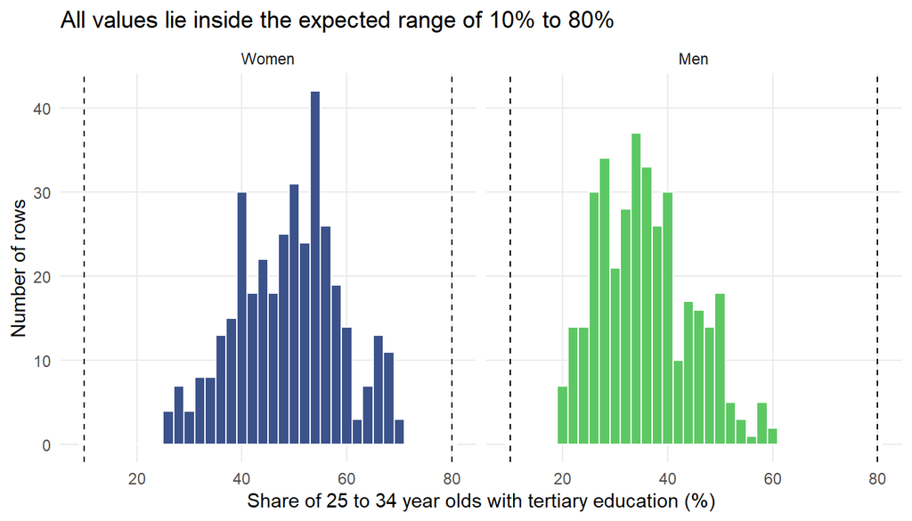

```r
# 3.5.2 Check 3: the distribution of the tertiary education share, women and men apart
education_clean |>
  ggplot(aes(x = tertiary_pct, fill = sex)) +        # one number, so a histogram (class 10_1)
  geom_histogram(binwidth = 2,
                 color = "white") +                  # one bar per 2 percentage points, white gaps
  scale_fill_viridis_d(begin = 0.25, end = 0.75) +   # same colours as before: blue women, green men
  geom_vline(xintercept = c(10, 80),
             linetype = "dashed") +                  # the expected range
  facet_wrap(~ sex,
             labeller = as_labeller(c(F = "Women", M = "Men"))) +   # one panel per sex
  labs(title = "All values lie inside the expected range of 10% to 80%",   # the title states the finding
       x = "Share of 25 to 34 year olds with tertiary education (%)",
       y = "Number of rows") +
  theme_minimal() +                                  # white background, light grid
  theme(legend.position = "none",                    # the panel titles already name the sexes
        panel.grid.minor = element_blank())          # fewer lines that carry no data
```

**Result:** all values lie inside the expected range of 10% to 80%. The two panels are clearly shifted: most values for women lie between about 40% and 60%, most values for men between about 25% and 45%. In nearly every country, young women are more likely to have a tertiary degree than young men. How large that difference is, and whether it goes with the life expectancy gap, is examined in Section 5.

#### Check 4: duplicates

```r
# 3.5.2 Check 4: compare all rows with distinct country, sex and year combinations
nrow(education_clean)                        # all rows, expected: 730
```

```
[1] 730
```

```r
education_clean |>
  distinct(country_code, sex, year) |>       # each combination once
  nrow()                                     # the same number means no duplicates
```

```
[1] 730
```

**Result:** both counts are 730. Every combination of country, sex and year appears exactly once, so the table has no duplicates.

#### Check 5: row counts

With 10 years and 2 sexes, every unit should have 20 rows. The same bar chart as in 3.1.2.

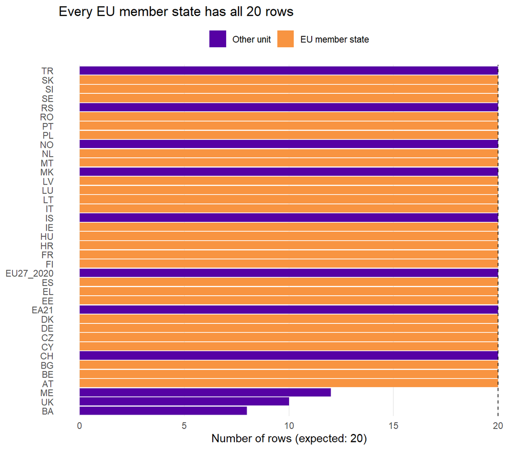

```r
# 3.5.2 Check 5: number of rows per geographic unit, EU member states in orange
education_clean |>
  count(country_code) |>                                  # n = number of rows per unit
  mutate(eu = country_code %in% eu_codes,                 # TRUE for the 27 member states
         country_code = fct_reorder(country_code, n)) |>  # sort the bars by n
  ggplot(aes(x = country_code, y = n, fill = eu)) +      # one bar per unit, coloured by EU or not
  geom_col() +                                            # bar length = the number of rows
  geom_hline(yintercept = 20, linetype = "dashed") +      # the expected 20 rows
  coord_flip() +                                          # bars sideways, codes readable
  scale_fill_viridis_d(option = "plasma",
                       begin = 0.15, end = 0.75,                    # purple and orange, no red
                       labels = c("Other unit", "EU member state"), # FALSE comes first, then TRUE
                       name = NULL) +
  labs(title = "Every EU member state has all 20 rows",   # the title states the finding
       x = NULL,                                         # the country codes need no axis title
       y = "Number of rows (expected: 20)") +
  theme_minimal() +                                       # white background, light grid
  theme(legend.position = "top",
        panel.grid.minor = element_blank(),
        panel.grid.major.y = element_blank())              # the bars need no horizontal grid
```

```r
# 3.5.2 Check 5: count the rows of the EU member states, without removing anything
education_clean |>
  filter(country_code %in% eu_codes) |>   # look at the member states only
  nrow()                                  # expected: 27 x 2 x 10 = 540
```

```
[1] 540
```

```r
# 3.5.2 Check 5: columns fixed in the link: each should have only one value
education_clean |>
  distinct(freq, age, unit, isced11) |>   # one row means each column has one value
  kable()                                 # show the result as a neat table
```

| freq | age | unit | isced11 |
| --- | --- | --- | --- |
| A | Y25-34 | PC | ED5-8 |

**Result:** all 27 EU member states have the full 20 rows, 540 rows together, as expected. The incomplete units are all outside the EU: `ME` (12 rows), `UK` (10, no data after 2019, the year before it left the EU) and `BA` (8). `freq`, `age`, `unit` and `isced11` each hold a single value (`A`, `Y25-34`, `PC`, `ED5-8`), the choices made in the link, so they can be removed.

### 3.5.3 Summary: what was found, what was decided

| Check | What was found | Decision |
| --- | --- | --- |
| 1 Types | `tertiary_pct` and `year` are numbers | No change needed |
| 2 Missing values | No missing values. 104 values marked `b`, 72 of them in 2021 (new survey method). 3 values for Luxembourg (2016, 2017) marked `u` (low reliability) | Flagged values are kept, as in all tables. The 2021 break is kept in mind when the education gap is followed over time in Section 5 |
| 3 Units and ranges | 19% to 71%, all inside the expected range. Women clearly higher than men | No change needed |
| 4 Duplicates | Every country, sex and year appears once | No change needed |
| 5 Row counts | All 27 EU member states complete (540 rows). The incomplete units are all outside the EU | Only the 27 EU member states are kept, using `eu_codes` |
| 5 Columns fixed in the link | `freq`, `age`, `unit` and `isced11` hold one value each. `conf_status` is empty. `dataflow` and `last_update` describe the download | These six technical columns are removed. The `last_update` date is reported once, in the source line |

No new decision was needed for this table: every finding was already covered by a decision made for an earlier table. After these decisions, `education_clean` keeps five columns: `country_code`, `sex`, `year`, `tertiary_pct` and `flag`, the same structure as `life_expectancy_clean`.

### 3.5.4 Apply the decisions

The same two steps as in 3.1.4, with the row count checked after each one.

#### Keep only the EU member states

```r
# 3.5.4 Keep only the 27 EU member states
nrow(education_clean)   # before: 730 rows
```

```
[1] 730
```

```r
education_clean <- education_clean |>         # overwrite the table with the filtered version
  filter(country_code %in% eu_codes)          # drop non-EU countries and aggregates such as EU27_2020

nrow(education_clean)   # after: expected 27 x 2 x 10 = 540
```

```
[1] 540
```

**What it shows:** 730 rows before and 540 after. The 190 removed rows are the aggregates `EU27_2020` and `EA21` and nine non-EU countries.

#### Remove the technical columns

```r
# 3.5.4 Keep the five columns the analysis uses
education_clean <- education_clean |>                          # overwrite the table again
  select(country_code, sex, year, tertiary_pct, flag)          # everything else is dropped

glimpse(education_clean)   # expected: 540 rows, 5 columns
```

```
Rows: 540
Columns: 5
$ country_code <chr> "AT", "AT", "AT", "AT", "AT", "AT", "AT", "AT", "AT", "AT…
$ sex          <chr> "F", "F", "F", "F", "F", "F", "F", "F", "F", "F", "F", "F…
$ year         <dbl> 2015, 2016, 2017, 2018, 2019, 2020, 2021, 2022, 2023, 202…
$ tertiary_pct <dbl> 41.5, 43.2, 44.4, 44.9, 45.9, 45.7, 46.8, 47.6, 48.1, 50.…
$ flag         <chr> NA, NA, NA, NA, NA, NA, "b", NA, NA, NA, NA, NA, "b", NA,…
```

**What it shows:** the clean table, with 540 rows and 5 columns: `country_code`, `sex`, `year`, `tertiary_pct` and `flag`. The same structure as `life_expectancy_clean`. This is the education table that goes into Section 4.

### 3.5.5 Save the clean table

The clean education table is saved to `data/clean/` at the end of this sub-section, right after it is created. Section 4 starts from this file, so each part of the analysis can be rerun on its own. Like the panel in 4.5, the file is created by the code and can always be recreated by running this sub-section again.

```r
# 3.5.5 Save the clean education table to data/clean/
write_csv(education_clean, here("data", "clean", "education_clean.csv"))   # 540 rows
```

**What it shows:** nothing on screen. The file `data/clean/education_clean.csv` is created or replaced.

## 3.6 Alcohol consumption per person

The alcohol table goes through the same four stages. It is the only table that does not come from Eurostat, so it needs one extra step: its three-letter country codes (`LVA`) are matched to Eurostat’s two-letter codes (`LV`) before the join in Section 4.

| Stage | What happens | Result |
| --- | --- | --- |
| 3.6.1 | Tidy the column names | Readable names, same data |
| 3.6.2 | Run the five quality checks | One result per check |
| 3.6.3 | Summarise what was found and decide | A table of decisions |
| 3.6.4 | Apply the decisions | `alcohol_clean`, EU only, Eurostat country codes |
| 3.6.5 | Save the clean table | `data/clean/alcohol_clean.csv` |

### 3.6.1 Tidy the column names

Our World in Data’s column names are already lowercase, so `clean_names()` changes nothing here. It is kept so that every table goes through the same steps. `rename()` then gives the columns names that say what they hold. The three-letter code is called `iso3_code`, not `country_code`, because `country_code` is kept for Eurostat’s two-letter codes, the key of the join in Section 4.

| Our World in Data name | After `rename()` |
| --- | --- |
| `entity` | `country_name` |
| `code` | `iso3_code` |
| `year` | `year` |
| `sh_alc_pcap_li` | `alcohol_litres` |

```r
# 3.6.1 Make the column names readable
alcohol_clean <- alcohol_raw |>                 # start from the untouched raw table
  clean_names() |>                              # names are already lowercase, kept for the same steps as every table
  rename(country_name   = entity,               # new name = old name: the country or region in words
         iso3_code      = code,                 # WHO's three-letter code, for example LVA
         alcohol_litres = sh_alc_pcap_li)       # the value: litres of pure alcohol per person aged 15+, per year

names(alcohol_clean)   # list the new column names, expected: 4
```

```
[1] "country_name"   "iso3_code"      "year"           "alcohol_litres"
```

**What it shows:** the same 4 columns, now called `country_name`, `iso3_code`, `year` and `alcohol_litres`.

### 3.6.2 The five quality checks

The checks run on all 4 164 rows, before anything is removed. The code follows 3.4.2 (GDP), because this table also has one value per country and year, with no sex. This table has no flag column: Our World in Data does not mark estimated or provisional values.

#### Check 1: types

```r
# 3.6.2 Check 1: the type of every column
glimpse(alcohol_clean)   # alcohol_litres and year should be <dbl>
```

```
Rows: 4,164
Columns: 4
$ country_name   <chr> "Afghanistan", "Afghanistan", "Afghanistan", "Afghanist…
$ iso3_code      <chr> "AFG", "AFG", "AFG", "AFG", "AFG", "AFG", "AFG", "AFG",…
$ year           <dbl> 2000, 2001, 2002, 2003, 2004, 2005, 2006, 2007, 2008, 2…
$ alcohol_litres <dbl> 0.003, 0.003, 0.007, 0.016, 0.021, 0.027, 0.025, 0.030,…
```

**Result:** `alcohol_litres` and `year` are numbers, `country_name` and `iso3_code` are text.

#### Check 2: missing values

```r
# 3.6.2 Check 2: missing values and spread of the litres per person
alcohol_clean |>                                          # the renamed table, all 4 164 rows
  tbl_summary(
    include   = alcohol_litres,                           # the one value column
    type      = alcohol_litres ~ "continuous2",           # show the number on several lines
    statistic = alcohol_litres ~ c("{median} ({p25} to {p75})",   # middle half
                                   "{min} to {max}"),             # full range
    label     = alcohol_litres ~ "Litres of pure alcohol per person aged 15+",   # readable row name
    missing      = "always",                              # a Missing row, even if it is 0
    missing_text = "Missing"                              # the word shown in that row
  )
```

| **Characteristic** | **N = 4,164** |
| --- | --- |
| Litres of pure alcohol per person aged 15+ |  |
| Median (Q1 to Q3) | 4.9 (1.9 to 8.7) |
| Min to Max | 0.0 to 19.4 |
| Missing | 0 |

**Result:** no value is missing. The median is 4.9 litres, and half of all values lie between 1.9 and 8.7 litres.

#### Check 3: units and ranges

Litres of pure alcohol per person in a year are expected to lie between 0 (countries where alcohol is banned) and about 20. A value far above would point to a wrong unit, for example litres of beer instead of pure alcohol.

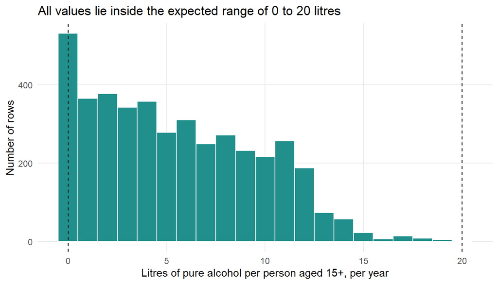

```r
# 3.6.2 Check 3: the distribution of litres per person
alcohol_clean |>
  ggplot(aes(x = alcohol_litres)) +                   # one number, so a histogram (class 10_1)
  geom_histogram(binwidth = 1,
                 fill = "#21908C",                    # one colour from the viridis palette (teal)
                 color = "white") +                   # one bar per litre, white gaps
  geom_vline(xintercept = c(0, 20),
             linetype = "dashed") +                   # the expected range
  labs(title = "All values lie inside the expected range of 0 to 20 litres",   # the title states the finding
       x = "Litres of pure alcohol per person aged 15+, per year",
       y = "Number of rows") +
  theme_minimal() +                                   # white background, light grid
  theme(panel.grid.minor = element_blank())           # fewer lines that carry no data
```

**Result:** all values lie between 0 and 19.4 litres. The zeros are real: Kuwait, for example, bans alcohol, so its recorded consumption is 0 in every year. The highest value is Romania in 2002 (19.4 litres). In the EU from 2015, values run from 5.8 litres (Greece, 2020) to 17.0 (Romania, 2018 and 2019).

#### Check 4: duplicates

One row should be one country (or region) and one year.

```r
# 3.6.2 Check 4: compare all rows with distinct country and year combinations
nrow(alcohol_clean)                    # all rows, expected: 4 164
```

```
[1] 4164
```

```r
alcohol_clean |>
  distinct(iso3_code, year) |>         # each combination once
  nrow()                               # the same number means no duplicates
```

```
[1] 4164
```

**Result:** both counts are 4 164, so the table has no duplicates.

#### Check 5: row counts

With 21 years (2000 to 2020), every unit should have 21 rows. With 200 units, a bar per unit would be unreadable, so the first chunk counts how many units have each number of rows: `count()` is used twice, first rows per unit, then units per row count.

```r
# 3.6.2 Check 5: how many units have each number of rows
alcohol_clean |>
  count(iso3_code) |>                          # n = number of rows per unit
  count(n, name = "units") |>                  # how many units have that many rows
  kable(col.names = c("Rows per unit", "Number of units"))
```

| Rows per unit | Number of units |
| --- | --- |
| 3 | 2 |
| 21 | 198 |

Besides countries, the file holds regional totals. Their codes are not three letters long, for example `OWID_WRL` for the world. `nchar()` counts the characters in a text, so these rows can be listed.

```r
# 3.6.2 Check 5: the regional totals, whose codes are not three letters long
alcohol_clean |>
  filter(nchar(iso3_code) != 3) |>             # keep codes that are not 3 characters long
  distinct(iso3_code, country_name) |>         # each region once
  kable(col.names = c("Code", "Region"))
```

| Code | Region |
| --- | --- |
| WB_EAP | East Asia and Pacific (WB) |
| WB_ECA | Europe and Central Asia (WB) |
| OWID_EU27 | European Union (27) |
| OWID_HIC | High-income countries |
| WB_LAC | Latin America and Caribbean (WB) |
| OWID_LIC | Low-income countries |
| OWID_LMC | Lower-middle-income countries |
| WB_MENAP | Middle East, North Africa, Afghanistan and Pakistan (WB) |
| WB_NA | North America (WB) |
| WB_SA | South Asia (WB) |
| WB_SSA | Sub-Saharan Africa (WB) |
| OWID_UMC | Upper-middle-income countries |
| OWID_WRL | World |

To count the EU rows, the three-letter codes of the 27 member states are needed. They are written next to Eurostat’s two-letter codes, in the same order as `eu_codes`, in one small table. The same table is used in 3.6.4 to give every row its Eurostat code.

```r
# 3.6.2 Check 5: the 27 EU member states, Eurostat's two-letter code next to WHO's three-letter code
eu_code_lookup <- tibble(
  country_code = eu_codes,                                           # Eurostat: AT, BE, ... (Greece is EL)
  iso3_code    = c("AUT", "BEL", "BGR", "CYP", "CZE", "DEU", "DNK", "EST", "GRC",   # WHO: Greece is GRC
                   "ESP", "FIN", "FRA", "HRV", "HUN", "IRL", "ITA", "LTU", "LUX",
                   "LVA", "MLT", "NLD", "POL", "PRT", "ROU", "SWE", "SVN", "SVK")
)

alcohol_clean |>
  filter(iso3_code %in% eu_code_lookup$iso3_code) |>   # look at the member states only
  nrow()                                               # expected: 27 x 21 = 567
```

```
[1] 567
```

**Result:** 198 units have all 21 years. Only Montenegro and Serbia have 3 rows each (2010, 2015 and 2019), and neither is in the EU. 13 of the units are regional totals, such as `OWID_EU27` (European Union) and `OWID_WRL` (World), which are removed in 3.6.4. The 27 EU member states have 567 rows together, all 21 years each, as expected.

### 3.6.3 Summary: what was found, what was decided

| Check | What was found | Decision |
| --- | --- | --- |
| 1 Types | `alcohol_litres` and `year` are numbers | No change needed |
| 2 Missing values | No missing values. The table has no flags | No change needed |
| 3 Units and ranges | 0 to 19.4 litres, all inside the expected range. The zeros belong to countries where alcohol is banned, such as Kuwait | No change needed. In the EU from 2015, values run from 5.8 to 17.0 litres |
| 4 Duplicates | Every country and year appears once | No change needed |
| 5 Row counts | 198 units complete (21 years each), Montenegro and Serbia with 3 years, 13 regional totals, 567 rows for the EU | Only the 27 EU member states are kept, which also removes the regional totals |
| 5 Years | The data runs from 2000 to 2020 | Only 2015 to 2020 are kept, the study period of the other tables. The years 2021 to 2024 are not available |
| 5 Country codes | WHO uses three-letter codes (`LVA`, `GRC`), Eurostat two-letter codes (`LV`, `EL`) | Each row gets its Eurostat code from `eu_code_lookup`, so the table can be joined in Section 4 |
| 5 Columns | `country_name` and `iso3_code` are only needed until the Eurostat code is added | Both are removed |

After these decisions, `alcohol_clean` keeps three columns: `country_code`, `year` and `alcohol_litres`. It has 162 rows: 27 countries times 6 years. Like GDP, it has no `sex` column, because the figure is for women and men together.

**Why the years after 2020 stay missing.** The other tables run to 2023 or 2024. In the joined panel, the alcohol values for 2021 to 2024 will be `NA`, never filled in or carried forward from 2020. Every analysis of alcohol in Section 5 therefore uses 2015 to 2020 only.

### 3.6.4 Apply the decisions

The same steps as in 3.4.4, plus one: the Eurostat code is added with a join. The row count is checked after each step.

#### Keep only the study period

```r
# 3.6.4 Keep only the years 2015 to 2020
nrow(alcohol_clean)   # before: 4 164 rows
```

```
[1] 4164
```

```r
alcohol_clean <- alcohol_clean |>            # overwrite the table with the filtered version
  filter(year >= 2015)                       # the study period starts in 2015, the data ends in 2020

nrow(alcohol_clean)   # after: expected 198 x 6 + 2 x 2 = 1 192
```

```
[1] 1192
```

**What it shows:** 4 164 rows before and 1 192 after: 198 complete units with 6 years each (1 188 rows), plus Montenegro and Serbia with 2 rows each (2015 and 2019).

#### Keep only the EU member states and add the Eurostat code

`inner_join()` (class 08) keeps only the rows that have a match in both tables. `eu_code_lookup` holds only the 27 member states, so the join does two things at once: it drops every other country and every regional total, and it adds the matching `country_code` to each row that stays.

```r
# 3.6.4 Keep the 27 EU member states and give each row its Eurostat code
alcohol_clean <- alcohol_clean |>
  inner_join(eu_code_lookup,                 # the 27 pairs of codes from 3.6.2
             by = join_by(iso3_code))        # match on WHO's three-letter code

nrow(alcohol_clean)   # after: expected 27 x 6 = 162
```

```
[1] 162
```

**What it shows:** 162 rows, 27 countries with 6 years each. Every row now also has `country_code`, for example `LV` next to `LVA`.

#### Keep the columns the analysis uses

```r
# 3.6.4 Keep the three columns the analysis uses
alcohol_clean <- alcohol_clean |>                     # overwrite the table again
  select(country_code, year, alcohol_litres)          # country_name and iso3_code are dropped

glimpse(alcohol_clean)   # expected: 162 rows, 3 columns
```

```
Rows: 162
Columns: 3
$ country_code   <chr> "AT", "AT", "AT", "AT", "AT", "AT", "BE", "BE", "BE", "…
$ year           <dbl> 2015, 2016, 2017, 2018, 2019, 2020, 2015, 2016, 2017, 2…
$ alcohol_litres <dbl> 12.19, 11.93, 11.92, 11.97, 11.97, 11.51, 11.24, 10.79,…
```

**What it shows:** the clean table, with 162 rows and 3 columns: `country_code`, `year` and `alcohol_litres`. One row per EU country and year, with no `sex` column. This is the alcohol table that goes into Section 4.

### 3.6.5 Save the clean table

The clean alcohol table is saved to `data/clean/` at the end of this sub-section, right after it is created. Section 4 starts from this file, so each part of the analysis can be rerun on its own. Like the panel in 4.5, the file is created by the code and can always be recreated by running this sub-section again.

```r
# 3.6.5 Save the clean alcohol table to data/clean/
write_csv(alcohol_clean, here("data", "clean", "alcohol_clean.csv"))   # 162 rows
```

**What it shows:** nothing on screen. The file `data/clean/alcohol_clean.csv` is created or replaced.

# 4. Combining the tables

This section turns six separate tables into one panel, `gap_panel`, with one row per EU country and year: 27 countries times 10 years, 270 rows. Each column holds one thing known about that country in that year. The research question is about relationships, for example whether a larger gap goes with lower GDP, and a chart can only show such a relationship when both numbers sit in the same row.

Life expectancy is complete for all 27 countries and 10 years, so it is the backbone: every other table is joined onto it. Values that a table does not have, such as the deaths of 2024 or Luxembourg’s healthy life years for 2023 and 2024, become `NA` in the panel, never 0.

| Step | What happens | Check |
| --- | --- | --- |
| 4.1 | Put women and men side by side with `pivot_wider()` and compute the gap with `mutate()`, one table at a time | The number of rows halves, the gaps lie in a plausible range |
| 4.2 | Deaths: women and men side by side for every cause (`deaths_by_cause`), and deaths from all causes for the panel | 21 951 rows, then 243 rows for all causes |
| 4.3 | Join the tables on country code and year | 270 rows after every join, `anti_join()` lists what did not match |
| 4.4 | Mark the Baltic states | 30 rows marked |
| 4.5 | Save the panel to `data/clean/gap_panel.csv` | The saved file loads again with the same rows and columns |

The tables arrive here already limited to the 27 EU member states (Section 3) and to the years 2015 to 2024 (the download links in Section 2). The `flag` column is dropped before the tables are reshaped: the flags are counted and described table by table in Section 3, and keeping them would add two flag columns per table to the panel.

## 4.1 Women and men side by side

### 4.1.1 Life expectancy

`pivot_wider()` (class 07) turns the values of one column into column names. Here the column `sex` holds `F` and `M`, so the two rows per country and year, one for women and one for men, become one row with two columns, `F` and `M`. `rename()` then gives them names that say what they hold, and `mutate()` computes the gap: women minus men, in years.

```r
# 4.1.1 Life expectancy: women and men side by side, then the gap
life_expectancy_wide <- life_expectancy_clean |>   # start from the clean table of 3.1
  select(-flag) |>                                 # drop the flags, they are described in Section 3
  pivot_wider(names_from  = sex,                   # the values F and M become column names
              values_from = life_expectancy) |>    # the numbers fill the new columns
  rename(le_women = F,                             # new name = old name
         le_men   = M) |>
  mutate(le_gap = le_women - le_men)               # the gap: women minus men, in years

glimpse(life_expectancy_wide)   # expected: 270 rows, 5 columns
```

```
Rows: 270
Columns: 5
$ country_code <chr> "AT", "AT", "AT", "AT", "AT", "AT", "AT", "AT", "AT", "AT…
$ year         <dbl> 2015, 2016, 2017, 2018, 2019, 2020, 2021, 2022, 2023, 202…
$ le_women     <dbl> 83.6, 84.0, 83.9, 84.0, 84.2, 83.7, 83.7, 83.8, 84.2, 84.…
$ le_men       <dbl> 78.6, 79.1, 79.3, 79.3, 79.5, 78.9, 78.8, 79.0, 79.4, 79.…
$ le_gap       <dbl> 5.0, 4.9, 4.6, 4.7, 4.7, 4.8, 4.9, 4.8, 4.8, 4.5, 4.6, 4.…
```

**What it shows:** 270 rows, half of the 540 rows of `life_expectancy_clean`, because the two rows per country and year (women and men) became one. Five columns: `country_code`, `year`, `le_women`, `le_men` and `le_gap`.

**Check of the gap.** The gap is the first number in the analysis that is calculated, not downloaded, so it is checked before it is used. Women are expected to live roughly 3 to 11 years longer than men in every EU country. A negative gap would mean that women and men were swapped. The five largest gaps in 2024 are also compared with the press figures quoted in the Background (Latvia 9.8 years, Lithuania 8.6, Estonia 8.5).

```r
# 4.1.1 Check: the range of the gap, then the five largest gaps in 2024
life_expectancy_wide |>
  summarise(smallest_gap = min(le_gap),     # expected: around 3, never below 0
            largest_gap  = max(le_gap)) |>  # expected: around 11 at most
  kable(digits = 1)                         # one decimal, as in the data
```

| smallest_gap | largest_gap |
| --- | --- |
| 2.8 | 10.4 |

```r
life_expectancy_wide |>
  filter(year == 2024) |>                   # the latest year
  slice_max(le_gap, n = 5) |>               # the five largest gaps, largest first (class 10_2)
  kable(digits = 1)                         # show the result as a neat table
```

| country_code | year | le_women | le_men | le_gap |
| --- | --- | --- | --- | --- |
| LV | 2024 | 81.2 | 71.4 | 9.8 |
| LT | 2024 | 81.6 | 73.0 | 8.6 |
| EE | 2024 | 83.4 | 75.1 | 8.3 |
| RO | 2024 | 80.3 | 72.8 | 7.5 |
| PL | 2024 | 82.2 | 74.8 | 7.4 |

**What it shows:** the gap runs from 2.8 to 10.4 years, always positive, so women and men were not swapped. In 2024 the three Baltic states have the largest gaps in the EU: Latvia 9.8 years, Lithuania 8.6 and Estonia 8.3, followed by Romania (7.5) and Poland (7.4). Latvia and Lithuania match the press figures exactly. Estonia is 0.2 years lower than the 8.5 quoted in the press, probably because Eurostat revised the figure after the article was written. The analysis uses the Eurostat data. The table also shows where the gap comes from: Baltic women live about as long as women in Romania or Poland, but Baltic men, especially in Latvia (71.4 years), live shorter lives.

### 4.1.2 Healthy life years

The same three steps as in 4.1.1. The table has 536 rows, not 540, because Luxembourg has no values for 2023 and 2024, so the wide table is expected to have 268 rows. The two missing rows come back as `NA` when the tables are joined in 4.3.

```r
# 4.1.2 Healthy life years: women and men side by side, then the gap
healthy_life_years_wide <- healthy_life_years_clean |>   # start from the clean table of 3.2
  select(-flag) |>                                       # drop the flags, they are described in Section 3
  pivot_wider(names_from  = sex,                         # the values F and M become column names
              values_from = healthy_life_years) |>       # the numbers fill the new columns
  rename(hly_women = F,                                  # new name = old name
         hly_men   = M) |>
  mutate(hly_gap = hly_women - hly_men)                  # the gap: women minus men, in healthy years

glimpse(healthy_life_years_wide)   # expected: 268 rows, 5 columns
```

```
Rows: 268
Columns: 5
$ country_code <chr> "AT", "AT", "AT", "AT", "AT", "AT", "AT", "AT", "AT", "AT…
$ year         <dbl> 2015, 2016, 2017, 2018, 2019, 2020, 2021, 2022, 2023, 202…
$ hly_women    <dbl> 58.1, 57.1, 56.8, 57.0, 58.0, 59.3, 61.3, 61.3, 60.5, 60.…
$ hly_men      <dbl> 57.9, 57.0, 57.4, 56.8, 56.7, 58.2, 61.5, 60.6, 60.3, 60.…
$ hly_gap      <dbl> 0.2, 0.1, -0.6, 0.2, 1.3, 1.1, -0.2, 0.7, 0.2, 0.4, -0.4,…
```

**What it shows:** 268 rows, half of the 536 rows of `healthy_life_years_clean`, and five columns: `country_code`, `year`, `hly_women`, `hly_men` and `hly_gap`. Already in Austria the gap is small and sometimes negative, for example -0.6 in 2017.

**Check of the gap.** Unlike life expectancy, the gap in healthy life years can be negative. Women live longer, but they often spend more of those years with limitations in daily activities, so in some countries men have more healthy years than women. A negative value is therefore not an error. The check looks at the range and at how many country-years have a negative gap.

```r
# 4.1.2 Check: the range of the gap, and how often it is negative
healthy_life_years_wide |>
  summarise(smallest_gap  = min(hly_gap),        # can be below 0: men with more healthy years
            largest_gap   = max(hly_gap),        # expected: a few years at most
            negative_gaps = sum(hly_gap < 0)) |> # number of country-years where men have more healthy years
  kable(digits = 1)                              # one decimal, as in the data
```

| smallest_gap | largest_gap | negative_gaps |
| --- | --- | --- |
| -5 | 5.4 | 76 |

```r
healthy_life_years_wide |>
  filter(year == 2024) |>                        # the latest year
  slice_max(hly_gap, n = 5) |>                   # the five largest gaps, largest first (class 10_2)
  kable(digits = 1)                              # show the result as a neat table
```

| country_code | year | hly_women | hly_men | hly_gap |
| --- | --- | --- | --- | --- |
| LT | 2024 | 67.0 | 61.6 | 5.4 |
| BG | 2024 | 71.4 | 66.8 | 4.6 |
| EE | 2024 | 60.6 | 56.8 | 3.8 |
| PL | 2024 | 66.2 | 63.2 | 3.0 |
| LV | 2024 | 53.9 | 51.1 | 2.8 |

**What it shows:** the gap in healthy life years runs from -5.0 to 5.4 years. In 76 of the 268 country-years it is negative, so men have more healthy years than women, as expected for this measure. In 2024 the largest gaps are in Lithuania (5.4 years), Bulgaria (4.6), Estonia (3.8), Poland (3.0) and Latvia (2.8). Latvia has the largest gap in life expectancy, but only the fifth largest in healthy life years, because Latvian women also have few healthy years (53.9, the lowest of the five). In the Baltic states, men live both shorter lives and fewer healthy years, but healthy years are low for women too.

### 4.1.3 Education

The same steps once more. The gap is again women minus men, here in percentage points: a gap of 20 means that the share of young women with a tertiary degree is 20 percentage points higher than the share of young men.

```r
# 4.1.3 Education: women and men side by side, then the gap
education_wide <- education_clean |>                     # start from the clean table of 3.5
  select(-flag) |>                                       # drop the flags, they are described in Section 3
  pivot_wider(names_from  = sex,                         # the values F and M become column names
              values_from = tertiary_pct) |>             # the numbers fill the new columns
  rename(tertiary_women_pct = F,                         # new name = old name
         tertiary_men_pct   = M) |>
  mutate(tertiary_gap = tertiary_women_pct - tertiary_men_pct)   # the gap: women minus men, in percentage points

glimpse(education_wide)   # expected: 270 rows, 5 columns
```

```
Rows: 270
Columns: 5
$ country_code       <chr> "AT", "AT", "AT", "AT", "AT", "AT", "AT", "AT", "AT…
$ year               <dbl> 2015, 2016, 2017, 2018, 2019, 2020, 2021, 2022, 202…
$ tertiary_women_pct <dbl> 41.5, 43.2, 44.4, 44.9, 45.9, 45.7, 46.8, 47.6, 48.…
$ tertiary_men_pct   <dbl> 35.8, 36.2, 36.4, 36.1, 37.4, 37.3, 38.2, 38.7, 39.…
$ tertiary_gap       <dbl> 5.7, 7.0, 8.0, 8.8, 8.5, 8.4, 8.6, 8.9, 9.0, 11.9, …
```

**What it shows:** 270 rows, half of the 540 rows of `education_clean`, and five columns: `country_code`, `year`, `tertiary_women_pct`, `tertiary_men_pct` and `tertiary_gap`. Education is complete for all 27 countries and 10 years.

**Check of the gap.** From Check 3 in 3.5.2, women are expected to be ahead in nearly every country, so the gap should be positive almost everywhere and at most around 30 percentage points.

```r
# 4.1.3 Check: the range of the gap, and the five largest gaps in 2024
education_wide |>
  summarise(smallest_gap  = min(tertiary_gap),         # expected: just above 0
            largest_gap   = max(tertiary_gap),         # expected: around 30 at most
            negative_gaps = sum(tertiary_gap < 0)) |>  # country-years where men are ahead
  kable(digits = 1)                                    # one decimal, as in the data
```

| smallest_gap | largest_gap | negative_gaps |
| --- | --- | --- |
| 1.9 | 28.4 | 0 |

```r
education_wide |>
  filter(year == 2024) |>                              # the latest year
  slice_max(tertiary_gap, n = 5) |>                    # the five largest gaps, largest first (class 10_2)
  kable(digits = 1)                                    # show the result as a neat table
```

| country_code | year | tertiary_women_pct | tertiary_men_pct | tertiary_gap |
| --- | --- | --- | --- | --- |
| SI | 2024 | 55.7 | 32.0 | 23.7 |
| LV | 2024 | 56.8 | 33.9 | 22.9 |
| EE | 2024 | 53.9 | 32.3 | 21.6 |
| HR | 2024 | 50.1 | 29.6 | 20.5 |
| SK | 2024 | 46.9 | 28.0 | 18.9 |

**What it shows:** the education gap runs from 1.9 to 28.4 percentage points and is never negative: in every EU country and every year, a larger share of young women than of young men has a tertiary degree. The largest gap of all is Latvia in 2015 (28.4). In 2024 the largest gaps are in Slovenia (23.7), Latvia (22.9), Estonia (21.6), Croatia (20.5) and Slovakia (18.9). Two Baltic states are in the top three, but Slovenia, whose life expectancy gap is much smaller, is first, so a large education gap alone does not come with a large life expectancy gap. Whether the two go together across all countries is examined in Section 5.

## 4.2 Deaths: women and men side by side

The deaths table has 92 causes. Putting every cause into `gap_panel` would add about 180 columns. The deaths are therefore kept in two forms:

- **`deaths_by_cause`:** one row per country, year and cause, with women and men side by side. It is used in Section 5 for the overview of the chapters of causes and for the deeper look at the causes named in the hypotheses.
- **Deaths from all causes** go into `gap_panel`, as one more set of columns for each country and year.

The gap in deaths is defined the other way round from the other gaps: **men minus women**, in deaths per 100 000. Men under 65 die more often, so this way a positive number means, as for life expectancy, that men are worse off. A difference is used instead of a ratio (men divided by women), because a ratio cannot be computed when women have no deaths from a cause, which happens 3 151 times in the data. Both rates are kept, so a ratio can still be calculated where it is useful.

### 4.2.1 Every cause side by side

```r
# 4.2.1 Deaths: women and men side by side for every cause, then the gap
deaths_by_cause <- deaths_clean |>                 # start from the clean table of 3.3
  select(-flag) |>                                 # drop the flags, the deaths table has none anyway
  pivot_wider(names_from  = sex,                   # the values F and M become column names
              values_from = death_rate) |>         # the numbers fill the new columns
  rename(death_women = F,                          # new name = old name
         death_men   = M) |>
  mutate(death_gap = death_men - death_women)      # the gap: men minus women, deaths per 100 000

glimpse(deaths_by_cause)   # expected: 21 951 rows, 7 columns
```

```
Rows: 21,951
Columns: 7
$ country_code <chr> "AT", "AT", "AT", "AT", "BE", "BE", "BE", "BE", "BG", "BG…
$ year         <dbl> 2018, 2019, 2020, 2021, 2018, 2019, 2020, 2021, 2018, 201…
$ cause_code   <chr> "TOTAL", "TOTAL", "TOTAL", "TOTAL", "TOTAL", "TOTAL", "TO…
$ cause_level  <chr> "all causes", "all causes", "all causes", "all causes", "…
$ death_women  <dbl> 114.85, 110.88, 111.59, 111.89, 135.44, 128.97, 131.22, 1…
$ death_men    <dbl> 212.69, 202.47, 210.70, 221.36, 219.68, 211.61, 224.61, 2…
$ death_gap    <dbl> 97.84, 91.59, 99.11, 109.47, 84.24, 82.64, 93.39, 89.32, …
```

**What it shows:** 21 951 rows, half of the 43 902 rows of `deaths_clean`, and seven columns: `country_code`, `year`, `cause_code`, `cause_level`, `death_women`, `death_men` and `death_gap`. In 2 992 rows the gap is negative, meaning more women than men die of that cause, for example from breast cancer. For most causes and for all causes together, men die more often.

### 4.2.2 Deaths from all causes, for the panel

From `deaths_by_cause`, only the rows for all causes are kept, and the columns get names that say so. This is the part of the deaths data that goes into `gap_panel`.

```r
# 4.2.2 Deaths from all causes, one row per country and year, ready for the join
deaths_all_causes <- deaths_by_cause |>
  filter(cause_level == "all causes") |>                  # only the TOTAL rows
  select(country_code, year,                              # the two keys for the join
         death_all_women = death_women,                   # select() can rename too: new name = old name
         death_all_men   = death_men,
         death_all_gap   = death_gap)

glimpse(deaths_all_causes)   # expected: 243 rows (27 countries x 9 years), 5 columns
```

```
Rows: 243
Columns: 5
$ country_code    <chr> "AT", "AT", "AT", "AT", "BE", "BE", "BE", "BE", "BG", …
$ year            <dbl> 2018, 2019, 2020, 2021, 2018, 2019, 2020, 2021, 2018, …
$ death_all_women <dbl> 114.85, 110.88, 111.59, 111.89, 135.44, 128.97, 131.22…
$ death_all_men   <dbl> 212.69, 202.47, 210.70, 221.36, 219.68, 211.61, 224.61…
$ death_all_gap   <dbl> 97.84, 91.59, 99.11, 109.47, 84.24, 82.64, 93.39, 89.3…
```

```r
deaths_all_causes |>
  summarise(smallest_gap = min(death_all_gap),     # expected: positive, men die more in every country
            largest_gap  = max(death_all_gap)) |>  # expected: a few hundred per 100 000
  kable(digits = 1)                                # one decimal
```

| smallest_gap | largest_gap |
| --- | --- |
| 44 | 454.8 |

**What it shows:** 243 rows, one per country and year from 2015 to 2023, and five columns. The gap in deaths from all causes is positive everywhere: in every EU country and year, more men than women die before 65. It ranges from 44 more deaths per 100 000 (Netherlands, 2019) to 455 more (Latvia, 2021). The rows are not sorted by year, because the code for all causes was `A-R_V-Y` for 2018 to 2021 before it was merged into `TOTAL`. The order does not matter for the join, which matches rows by country and year, not by position.

## 4.3 Joining the tables

The tables are joined one at a time onto the life expectancy table, with `left_join()` (class 08). `left_join()` keeps every row of the first table and adds the columns of the second where `country_code` and `year` match. Where there is no match, the new columns get `NA`. `inner_join()` was not used, because it keeps only rows that exist in every table: all of 2024 (no deaths data yet) and Luxembourg in 2023 would disappear, 28 of 270 rows, including their life expectancy, the main measure.

After every join, two checks follow. The number of rows must still be 270: more rows would mean that a country and year matched twice. And `anti_join()` lists the rows of the panel that found no partner in the new table, so every `NA` is explained.

### 4.3.1 Healthy life years

```r
# 4.3.1 Add healthy life years to the life expectancy table
gap_panel <- life_expectancy_wide |>                       # the backbone: 270 rows
  left_join(healthy_life_years_wide,                       # add the healthy life years columns
            by = join_by(country_code, year))              # match on country and year

nrow(gap_panel)   # must still be 270
```

```
[1] 270
```

```r
life_expectancy_wide |>
  anti_join(healthy_life_years_wide,                       # rows of the backbone with no partner
            by = join_by(country_code, year)) |>
  select(country_code, year) |>                            # only the keys are needed here
  kable()                                                  # expected: Luxembourg 2023 and 2024
```

| country_code | year |
| --- | --- |
| LU | 2023 |
| LU | 2024 |

**What it shows:** the panel still has 270 rows, so no country and year matched twice. Only two rows found no healthy life years: Luxembourg in 2023 and 2024, the two years missing from the Eurostat table (see 3.2). In these two rows, `hly_women`, `hly_men` and `hly_gap` are `NA`.

### 4.3.2 GDP per capita

GDP has no `sex`, so it joins on `country_code` and `year` like the others, and the same GDP value sits next to the values for women and men.

```r
# 4.3.2 Add GDP per capita
gap_panel <- gap_panel |>                                  # the panel so far
  left_join(gdp_clean |> select(-flag),                    # GDP without its flag column
            by = join_by(country_code, year))              # match on country and year

nrow(gap_panel)   # must still be 270
```

```
[1] 270
```

```r
gap_panel |>
  anti_join(gdp_clean, by = join_by(country_code, year)) |>   # rows with no GDP
  nrow()                                                      # expected: 0, GDP is complete
```

```
[1] 0
```

**What it shows:** still 270 rows, and every row found its GDP value (0 rows without a partner). The panel now has one more column, `gdp_pps_index`.

### 4.3.3 Education

```r
# 4.3.3 Add tertiary education
gap_panel <- gap_panel |>                                  # the panel so far
  left_join(education_wide,                                # add the education columns
            by = join_by(country_code, year))              # match on country and year

nrow(gap_panel)   # must still be 270
```

```
[1] 270
```

```r
gap_panel |>
  anti_join(education_wide, by = join_by(country_code, year)) |>   # rows with no education data
  nrow()                                                           # expected: 0, education is complete
```

```
[1] 0
```

**What it shows:** still 270 rows, and every row found its education values (0 rows without a partner). The panel now has three more columns: `tertiary_women_pct`, `tertiary_men_pct` and `tertiary_gap`.

### 4.3.4 Deaths from all causes

```r
# 4.3.4 Add deaths from all causes
gap_panel <- gap_panel |>                                  # the panel so far
  left_join(deaths_all_causes,                             # add the deaths columns
            by = join_by(country_code, year))              # match on country and year

nrow(gap_panel)   # must still be 270
```

```
[1] 270
```

```r
gap_panel |>
  anti_join(deaths_all_causes, by = join_by(country_code, year)) |>   # rows with no deaths data
  count(year)                                                         # expected: only 2024, 27 rows
```

```
# A tibble: 1 × 2
   year     n
  <dbl> <int>
1  2024    27
```

**What it shows:** still 270 rows. The 27 rows without deaths data are exactly the 27 countries in 2024, the year the deaths table does not yet cover. In these rows the three death columns are `NA`. After the four joins, `gap_panel` has 270 rows and 15 columns, and its only missing values are these 27 rows of deaths and the two rows of healthy life years for Luxembourg.

### 4.3.5 Alcohol consumption

Alcohol has no `sex`, like GDP, so the same value sits next to the values for women and men. It covers only 2015 to 2020, so the rows for 2021 to 2024 get `NA` in the alcohol column. They are not filled in.

```r
# 4.3.5 Add alcohol consumption per person
gap_panel <- gap_panel |>                                  # the panel so far
  left_join(alcohol_clean,                                 # add the alcohol column
            by = join_by(country_code, year))              # match on country and year

nrow(gap_panel)   # must still be 270
```

```
[1] 270
```

```r
gap_panel |>
  anti_join(alcohol_clean, by = join_by(country_code, year)) |>   # rows with no alcohol data
  count(year)                                                     # expected: 2021 to 2024, 27 rows each
```

```
# A tibble: 4 × 2
   year     n
  <dbl> <int>
1  2021    27
2  2022    27
3  2023    27
4  2024    27
```

**What it shows:** still 270 rows. The 108 rows without alcohol data are exactly the 27 countries in each of the years 2021 to 2024, which the WHO data does not cover. In these rows `alcohol_litres` is `NA`. The panel now has 16 columns.

## 4.4 Country names and the Baltic states

Two columns make the panel easier to read and to chart. `country` holds the English name of each country, because codes such as `EL` (Greece) or `SI` (Slovenia) are not known to every reader. `baltic` is `TRUE` for Estonia, Latvia and Lithuania and `FALSE` for the other 24 countries, so that every chart can highlight the three countries with one line of code.

The names are written once, in a small table with one row per country, and joined onto the panel by `country_code`, in the same way as the data tables.

```r
# 4.4 The English name of each EU member state, one row per country
country_names <- tibble(
  country_code = c("AT", "BE", "BG", "CY", "CZ", "DE", "DK", "EE", "EL",
                   "ES", "FI", "FR", "HR", "HU", "IE", "IT", "LT", "LU",
                   "LV", "MT", "NL", "PL", "PT", "RO", "SE", "SI", "SK"),
  country      = c("Austria", "Belgium", "Bulgaria", "Cyprus", "Czechia",        # same order as the codes above
                   "Germany", "Denmark", "Estonia", "Greece",
                   "Spain", "Finland", "France", "Croatia", "Hungary",
                   "Ireland", "Italy", "Lithuania", "Luxembourg",
                   "Latvia", "Malta", "Netherlands", "Poland", "Portugal",
                   "Romania", "Sweden", "Slovenia", "Slovakia")
)

nrow(country_names)   # should be 27
```

```
[1] 27
```

```r
# 4.4 Add the country names and mark the Baltic states
gap_panel <- gap_panel |>                                   # the panel after the four joins
  left_join(country_names, by = join_by(country_code)) |>   # add the name, matched on the code only
  mutate(baltic = country_code %in% c("EE", "LV", "LT")) |> # TRUE for Estonia, Latvia, Lithuania
  select(country_code, country, baltic, everything())       # put the three columns first, then all others

nrow(gap_panel)          # must still be 270
```

```
[1] 270
```

```r
sum(is.na(gap_panel$country))   # expected: 0, every code found its name
```

```
[1] 0
```

```r
gap_panel |>
  count(baltic) |>                                          # rows per group
  kable(col.names = c("Baltic state", "Rows"))              # expected: FALSE 240, TRUE 30
```

| Baltic state | Rows |
| --- | --- |
| FALSE | 240 |
| TRUE | 30 |

**What it shows:** still 270 rows, and every country code found its name (0 missing). 30 rows are marked as Baltic (3 countries times 10 years) and 240 as not Baltic. `gap_panel` now has 18 columns: code, name and Baltic mark first, then `year` and the 14 measures.

## 4.5 Saving the panel

The two combined tables are saved to `data/clean/`: `gap_panel.csv`, one row per country and year, and `deaths_by_cause.csv`, one row per country, year and cause, with the country names and the Baltic mark added so it can be charted on its own. `write_csv()` writes a table to a CSV file, and missing values are written as `NA`. The files in `data/clean/` are created by this code and can always be recreated by running the document again, unlike the files in `data/raw/`.

```r
# 4.5 Save the two combined tables to data/clean/
write_csv(gap_panel,                                        # the panel: one row per country and year
          here("data", "clean", "gap_panel.csv"))

deaths_by_cause <- deaths_by_cause |>                       # the deaths: one row per country, year and cause
  left_join(country_names, by = join_by(country_code)) |>   # add the names, as in the panel
  mutate(baltic = country_code %in% c("EE", "LV", "LT"))    # and the Baltic mark

write_csv(deaths_by_cause,
          here("data", "clean", "deaths_by_cause.csv"))
```

**Check: the saved panel loads again.** This is also the five-line check of the course checkpoint: load the clean data from its file and look at it, without any of the code above.

```r
# 4.5 Check: load the saved panel from the file, as anyone else would
here("data", "clean", "gap_panel.csv") |>    # the path to the saved file
  read_csv(show_col_types = FALSE) |>        # read it back
  glimpse() |>                               # show columns and types
  nrow()                                     # expected: 270
```

```
Rows: 270
Columns: 18
$ country_code       <chr> "AT", "AT", "AT", "AT", "AT", "AT", "AT", "AT", "AT…
$ country            <chr> "Austria", "Austria", "Austria", "Austria", "Austri…
$ baltic             <lgl> FALSE, FALSE, FALSE, FALSE, FALSE, FALSE, FALSE, FA…
$ year               <dbl> 2015, 2016, 2017, 2018, 2019, 2020, 2021, 2022, 202…
$ le_women           <dbl> 83.6, 84.0, 83.9, 84.0, 84.2, 83.7, 83.7, 83.8, 84.…
$ le_men             <dbl> 78.6, 79.1, 79.3, 79.3, 79.5, 78.9, 78.8, 79.0, 79.…
$ le_gap             <dbl> 5.0, 4.9, 4.6, 4.7, 4.7, 4.8, 4.9, 4.8, 4.8, 4.5, 4…
$ hly_women          <dbl> 58.1, 57.1, 56.8, 57.0, 58.0, 59.3, 61.3, 61.3, 60.…
$ hly_men            <dbl> 57.9, 57.0, 57.4, 56.8, 56.7, 58.2, 61.5, 60.6, 60.…
$ hly_gap            <dbl> 0.2, 0.1, -0.6, 0.2, 1.3, 1.1, -0.2, 0.7, 0.2, 0.4,…
$ gdp_pps_index      <dbl> 128, 128, 125, 125, 124, 123, 121, 123, 121, 119, 1…
$ tertiary_women_pct <dbl> 41.5, 43.2, 44.4, 44.9, 45.9, 45.7, 46.8, 47.6, 48.…
$ tertiary_men_pct   <dbl> 35.8, 36.2, 36.4, 36.1, 37.4, 37.3, 38.2, 38.7, 39.…
$ tertiary_gap       <dbl> 5.7, 7.0, 8.0, 8.8, 8.5, 8.4, 8.6, 8.9, 9.0, 11.9, …
$ death_all_women    <dbl> 121.47, 118.44, 114.69, 114.85, 110.88, 111.59, 111…
$ death_all_men      <dbl> 230.52, 217.88, 213.01, 212.69, 202.47, 210.70, 221…
$ death_all_gap      <dbl> 109.05, 99.44, 98.32, 97.84, 91.59, 99.11, 109.47, …
$ alcohol_litres     <dbl> 12.19, 11.93, 11.92, 11.97, 11.97, 11.51, NA, NA, N…
```

```
[1] 270
```

**What it shows:** the saved file loads with 270 rows and 18 columns, the same as `gap_panel` in memory. The types survived the round trip: `country_code` and `country` are text, `baltic` is logical (`TRUE` or `FALSE`), and all measures are numbers. `gap_panel.csv` is the table that Section 5 starts from.

# 5. Exploration

This section looks at the gap from several sides, one question per graph. It starts with the gap itself (where is it largest, how has it changed), then looks at what makes it up (causes of death), and only then at the factors that may go with it (wealth, education). Each graph has its question above it and one finding with a number below it, as the course template asks. Each chart type is chosen for the type of question (class 10).

| Sub-section | Question | Graph | Chart type |
| --- | --- | --- | --- |
| 5.0 | Starting from the saved files |  |  |
| 5.1 | Where is the gap largest, and how unusual are the Baltic gaps? | Graphs 1 to 3 | Ranked bar chart, histogram, box plot |
| 5.2 | How has the gap changed between 2015 and 2024? | Graph 4 | Lines over time |
| 5.3 | Which causes of death make up the extra deaths of men? | Graphs 5 and 6 | Grouped bar charts: chapters, then specific causes |
| 5.4 | Which factors go with the gap? | Graphs 7 to 11, one per factor, and Graph 16 (alcohol consumption) | Scatter plots with a trend line, correlations |
| 5.5 | Do Baltic men fall below the EU pattern while Baltic women do not? | Graph 12 | Comparison with countries of similar income, women and men |
| 5.6 | Is the gap about the men? | Graph 13 | Two dots per country, women and men |
| 5.7 | Which causes and how much drinking changed in Lithuania and Latvia? | Graphs 14 and 17 | Lines over time, one panel per cause, then litres per person |
| 5.8 | Do Baltic men also lose healthy years? | Graph 15 | Stacked bars: healthy years and years with limitations |
| 5.9 | How robust are the results? Chance, another year, overlap of the factors, outliers |  | Tables |
| 5.10 | Summary: strongest factor, weakest factor, one surprise |  | Text |

The question whether the factors only stand in for wealth, first planned as a separate step, is answered within 5.4 by Graph 10: the Baltic gaps are about two years larger than their income would predict.

Each sub-section ends with a short **What this means**: the answer to its question in one or two sentences, and why it leads to the next one.

The order may change as the findings come in. Relationships that were expected but turn out weak are kept in the appendix, not deleted.

## 5.0 Starting from the saved files

Section 5 starts from the two files saved in 4.5, not from the objects in memory. This way the exploration depends only on the clean data, and it can be rerun on its own.

```r
# 5.0 Load the two clean tables saved in Section 4
gap_panel <- read_csv(here("data", "clean", "gap_panel.csv"),              # one row per country and year
                      show_col_types = FALSE)
deaths_by_cause <- read_csv(here("data", "clean", "deaths_by_cause.csv"),  # one row per country, year and cause
                            show_col_types = FALSE)

dim(gap_panel)         # expected: 270 rows, 18 columns
```

```
[1] 270  18
```

```r
dim(deaths_by_cause)   # expected: 21 951 rows, 9 columns
```

```
[1] 21951     9
```

## 5.1 Where is the gap largest?

### 5.1.1 Graph 1: In which EU countries do women outlive men by the most years?

A number for each of 27 countries is a comparison of categories, so the chart is a bar chart (class 10_2), sorted by length so the ranking can be read at once, and turned sideways so the country names are readable. The Baltic states are highlighted in red, all other countries are gray (gray plus one colour, class 11). A dashed line marks the EU average of the 27 gaps. The latest year, 2024, is shown.

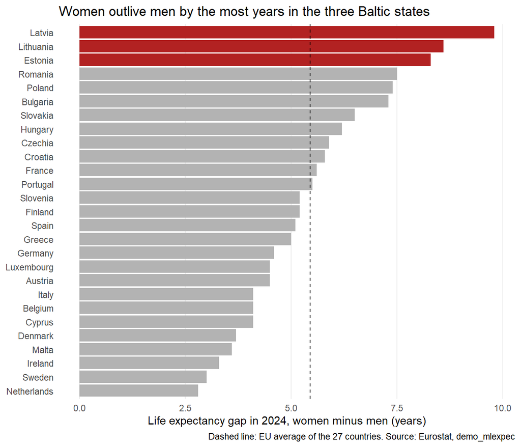

```r
# 5.1.1 Graph 1: the life expectancy gap in 2024, country by country
gap_2024 <- gap_panel |>
  filter(year == 2024)                                       # the latest year only, one row per country

gap_2024 |>
  mutate(country = fct_reorder(country, le_gap)) |>          # sort the countries by their gap
  ggplot(aes(x = country, y = le_gap, fill = baltic)) +      # one bar per country, coloured by Baltic or not
  geom_col() +                                               # bar length = the gap in years
  geom_hline(yintercept = mean(gap_2024$le_gap),
             linetype = "dashed") +                          # the EU average of the 27 gaps
  coord_flip() +                                             # bars sideways, names readable
  scale_fill_manual(values = c("TRUE" = "firebrick",         # Baltic states in red
                               "FALSE" = "gray70")) +        # all other countries in gray
  labs(title = "Women outlive men by the most years in the three Baltic states",   # the title states the finding
       x = NULL,                                             # the country names need no axis title
       y = "Life expectancy gap in 2024, women minus men (years)",
       caption = "Dashed line: EU average of the 27 countries. Source: Eurostat, demo_mlexpec") +
  theme_minimal() +                                          # white background, light grid
  theme(legend.position = "none",                            # red and gray are explained in the title
        panel.grid.minor = element_blank(),
        panel.grid.major.y = element_blank())                # the bars need no horizontal grid
```

**Finding:** in 2024 women outlive men by 5.5 years on average across the 27 EU countries, but by 9.8 years in Latvia, 8.6 in Lithuania and 8.3 in Estonia, the three largest gaps in the EU. Latvia’s gap is almost twice the EU average and three and a half times the smallest gap, in the Netherlands (2.8 years). The 12 countries above the average are all in central and eastern Europe, plus France and Portugal: the gap is not only a Baltic pattern, but the Baltic states are its most extreme case.

### 5.1.2 Graph 2: How the gap is spread across the EU

**Question:** is a gap of eight or ten years unusual in the EU, or are many countries close to it?

One number for each country is a distribution, shown as a histogram (class 10_1): each bar counts how many countries have a gap in a band of half a year. The Baltic states are coloured red inside the bars, so it can be seen where in the distribution they lie. The year is 2024.

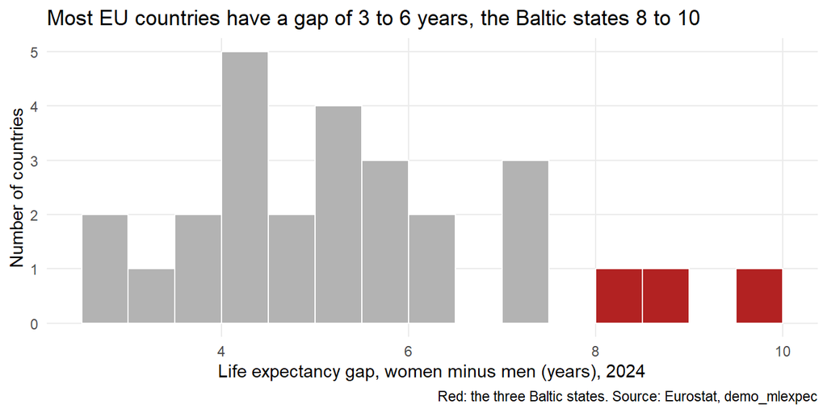

```r
# 5.1.2 Graph 2: the distribution of the life expectancy gap across the 27 countries, 2024
gap_2024 |>
  ggplot(aes(x = le_gap, fill = baltic)) +                 # one number per country, coloured by Baltic or not
  geom_histogram(binwidth = 0.5, boundary = 0,             # bands of half a year: 2.5 to 3, 3 to 3.5, ...
                 colour = "white") +                       # white gaps between the bars
  scale_fill_manual(values = c("TRUE" = "firebrick",
                               "FALSE" = "gray70")) +
  labs(title = "Most EU countries have a gap of 3 to 6 years, the Baltic states 8 to 10",   # the finding
       x = "Life expectancy gap, women minus men (years), 2024",
       y = "Number of countries",
       caption = "Red: the three Baltic states. Source: Eurostat, demo_mlexpec") +
  theme_minimal() +
  theme(legend.position = "none",
        panel.grid.minor = element_blank())
```

**Finding:** in 2024, 21 of the 27 countries have a gap between 2.8 and 6.5 years, with the middle country at 5.2. Three countries follow at about 7.5 years (Bulgaria, Poland and Romania). After an empty band, the three Baltic states stand alone at the right end: Estonia 8.3, Lithuania 8.6 and Latvia 9.8 years. The Baltic gaps are not slightly above the European range, they are outside it.

### 5.1.3 Graph 3: The Baltic states against the rest of the EU, all years

**Question:** across all ten years, how different are the gaps of the Baltic states from those of the other 24 EU countries?

Comparing a number between two groups is a box plot (class 10_4). The box holds the middle half of the values, the line inside it is the median, and the whiskers reach the lowest and highest values that are not far out. Each dot is one country in one year, spread sideways a little with `geom_jitter()` so that dots do not hide each other. The black diamond is the mean of each group, added with `stat_summary()`. Each group has its own colour, and the two groups are named on the axis.

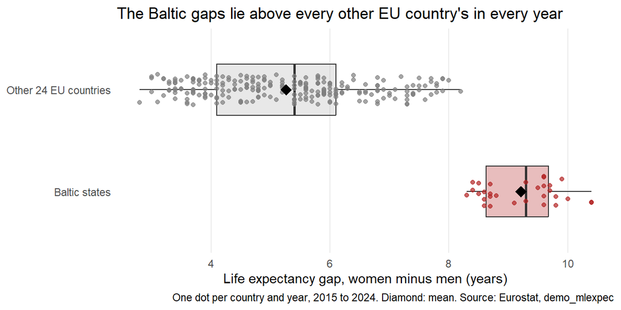

```r
# 5.1.3 Graph 3: the gap in the Baltic states and in the rest of the EU, all country-years 2015 to 2024
gap_panel |>
  mutate(group = if_else(baltic, "Baltic states", "Other 24 EU countries")) |>   # readable group names
  ggplot(aes(x = group, y = le_gap)) +
  geom_boxplot(aes(fill = group), alpha = 0.3,
               outlier.shape = NA, width = 0.5) +           # the box; outliers are shown by the dots instead
  geom_jitter(aes(colour = group), width = 0.15,
              height = 0, size = 1.5, alpha = 0.7) +        # one dot per country and year, spread sideways
  stat_summary(fun = mean, geom = "point",
               shape = 18, size = 4) +                      # the mean as a black diamond
  coord_flip() +                                            # groups as rows, the gap from left to right
  scale_fill_manual(values = c("Baltic states" = "firebrick",
                               "Other 24 EU countries" = "gray70")) +
  scale_colour_manual(values = c("Baltic states" = "firebrick",
                                 "Other 24 EU countries" = "gray50")) +
  labs(title = "The Baltic gaps lie above every other EU country's in every year",   # the finding
       x = NULL,
       y = "Life expectancy gap, women minus men (years)",
       caption = "One dot per country and year, 2015 to 2024. Diamond: mean. Source: Eurostat, demo_mlexpec") +
  theme_minimal() +
  theme(legend.position = "none",
        panel.grid.minor = element_blank(),
        panel.grid.major.y = element_blank())
```

**Finding:** over all ten years, the gaps of the Baltic states range from 8.3 to 10.4 years, with a mean of 9.2. The gaps of the other 24 countries range from 2.8 to 8.2, with a mean of 5.3. The two groups do not overlap: the smallest Baltic gap in any year (Estonia, 8.3) is larger than every gap of every other EU country in every year, the closest being Poland in 2020 (8.2). On average, the Baltic gap is about four years larger than the gap in the rest of the EU.

**What this means:** the Baltic states have the largest gaps in the EU in 2024, nearly twice the average. One year could be an exception, so the next question is whether this has been the case over the whole period.

## 5.2 How has the gap changed?

### 5.2.1 Graph 4: Did the gap narrow between 2015 and 2024, and did the Baltic states move differently from the rest of the EU?

Change over time is shown as lines (class 3: time means a line chart), one line per country. The 24 other countries are thin gray lines, the three Baltic states thicker red lines with their names at the end. The y axis does not start at zero, because the question is about change, and lines may leave zero when the range is stated (course rule). The COVID-19 years 2020 and 2021 are part of the data and are not removed.

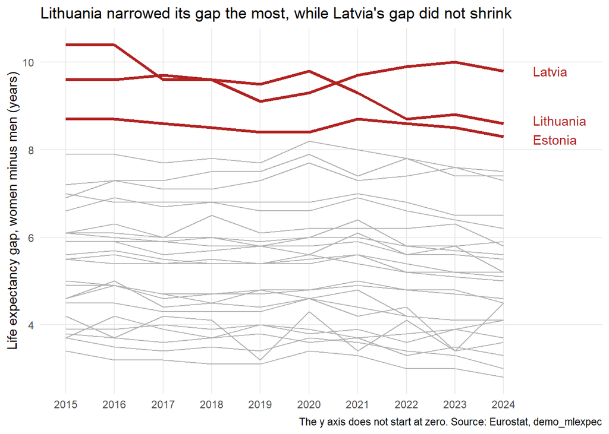

```r
# 5.2.1 Graph 4: the life expectancy gap over time, one line per country
gap_panel |>
  ggplot(aes(x = year, y = le_gap, group = country,         # one line per country
             colour = baltic)) +                            # red for the Baltic states, gray for the rest
  geom_line(aes(linewidth = baltic)) +                      # thicker lines for the Baltic states
  geom_text_repel(data = gap_panel |>
                    filter(baltic, year == 2024),           # labels only for the Baltic states, at the last year
                  aes(label = country),
                  nudge_x = 0.6, direction = "y",           # labels to the right of the lines, spread up and down
                  hjust = 0, segment.colour = NA) +         # no connecting line, the label sits next to its line
  scale_colour_manual(values = c("TRUE" = "firebrick",      # Baltic states in red
                                 "FALSE" = "gray70")) +     # all other countries in gray
  scale_linewidth_manual(values = c("TRUE" = 1.2,           # thick Baltic lines
                                    "FALSE" = 0.4)) +       # thin lines for the others
  scale_x_continuous(breaks = 2015:2024,                    # one tick per year
                     limits = c(2015, 2025.5)) +            # room on the right for the labels
  labs(title = "Lithuania narrowed its gap the most, while Latvia's gap did not shrink",   # the title states the finding
       x = NULL,
       y = "Life expectancy gap, women minus men (years)",
       caption = "The y axis does not start at zero. Source: Eurostat, demo_mlexpec") +
  theme_minimal() +                                         # white background, light grid
  theme(legend.position = "none",                           # the labels name the red lines
        panel.grid.minor = element_blank())                 # fewer lines that carry no data
```

**Finding:** the three Baltic states had the largest gaps in every year from 2015 to 2024, well above all other countries. Their paths differ: Lithuania’s gap fell from 10.4 years in 2015 to 8.6 in 2024, the largest narrowing in the EU, with big steps in 2017 and 2022. Latvia’s gap stayed around 9.6, dipped to 9.1 in 2019 and then rose to 10.0 in 2023, so Latvia overtook Lithuania in 2021 and has had the largest gap since. Estonia stayed between 8.3 and 8.7 throughout. Most gray lines move little and drift slightly down.

### 5.2.2 The change in numbers

To put a number on the change, each country’s gap in 2024 is compared with its gap in 2015. `group_by(country)` and `summarise()` (class 09) do this once per country.

```r
# 5.2.2 The change in the gap from 2015 to 2024, country by country
gap_change <- gap_panel |>
  group_by(country, baltic) |>                                   # one group per country
  summarise(gap_2015 = le_gap[year == 2015],                     # the gap in the first year
            gap_2024 = le_gap[year == 2024],                     # the gap in the last year
            .groups = "drop") |>                                 # remove the grouping afterwards
  mutate(change = gap_2024 - gap_2015) |>                        # negative = the gap narrowed
  arrange(change)                                                # the largest narrowing first

gap_change |>
  filter(baltic | row_number() <= 3 | row_number() > n() - 3) |> # Baltic states, the top 3 and the bottom 3
  kable(digits = 1)                                              # show the result as a neat table
```

| country | baltic | gap_2015 | gap_2024 | change |
| --- | --- | --- | --- | --- |
| Lithuania | TRUE | 10.4 | 8.6 | -1.8 |
| Slovenia | FALSE | 5.9 | 5.2 | -0.7 |
| Sweden | FALSE | 3.7 | 3.0 | -0.7 |
| Estonia | TRUE | 8.7 | 8.3 | -0.4 |
| Latvia | TRUE | 9.6 | 9.8 | 0.2 |
| Romania | FALSE | 7.2 | 7.5 | 0.3 |
| Bulgaria | FALSE | 6.9 | 7.3 | 0.4 |
| Cyprus | FALSE | 3.7 | 4.1 | 0.4 |

**What it shows:** in 22 of the 27 countries the gap narrowed between 2015 and 2024, and in Czechia it stayed the same. It narrowed most in Lithuania (-1.8 years), followed by Slovenia and Sweden (-0.7 each). It grew in only four countries: Cyprus and Bulgaria (+0.4 each), Romania (+0.3) and Latvia (+0.2). Estonia narrowed by 0.4 years, about as much as most countries.

**What this means:** the Baltic gap is not a one-year exception: the three countries have had the largest gaps in every year since 2015, even though Lithuania has narrowed its gap the most. Life expectancy only shows that men die earlier, not of what. The next question is which causes of death make up the extra deaths of men.

## 5.3 Which causes of death make up the extra deaths of men?

### 5.3.1 Graph 5: Which chapters of causes account for the extra deaths of men under 65, in the Baltic states and in the rest of the EU?

This is the overview without choosing any cause (see 2.3): all chapter-level groups, which together cover every death. For each chapter, the gap in deaths (men minus women, per 100 000, under 65) is averaged over the three Baltic states and over the other 24 countries, in 2023, the latest year. Comparing a number across categories and two groups is a grouped bar chart (class 10_2): red for the Baltic states, gray for the rest. The averages are simple averages of the countries, so each country counts once, whatever its population.

The three COVID-19 codes are combined into one group, and the codes get short readable names with `case_when()`.

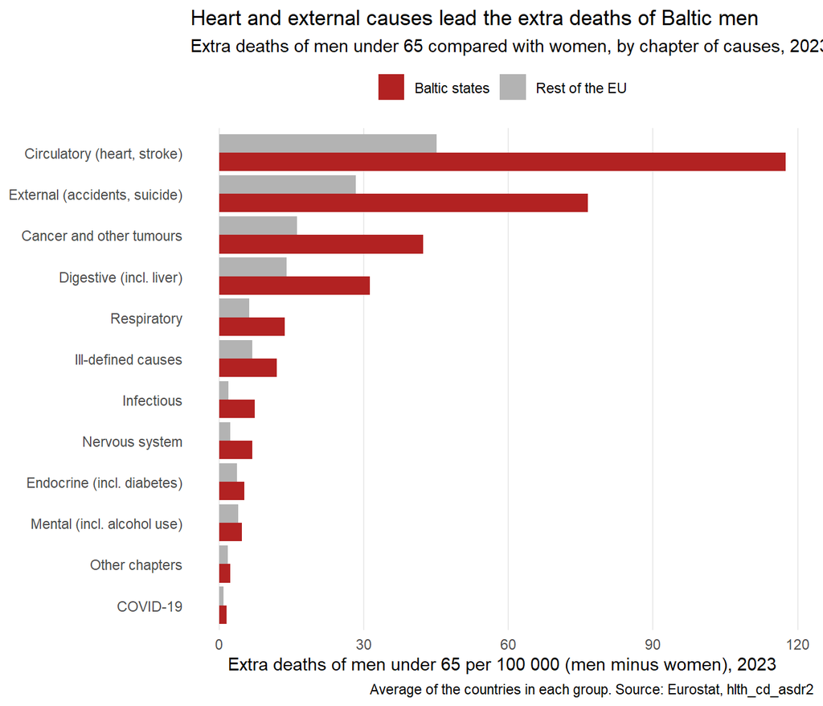

```r
# 5.3.1 Graph 5: the extra deaths of men by chapter of causes, Baltic states and rest of the EU, 2023
chapter_gap <- deaths_by_cause |>
  filter(cause_level == "chapter", year == 2023) |>                    # the chapters, latest year
  mutate(chapter = case_when(                                          # short readable names
    cause_code == "I"       ~ "Circulatory (heart, stroke)",
    cause_code == "V01-Y89" ~ "External (accidents, suicide)",
    cause_code == "C00-D48" ~ "Cancer and other tumours",
    cause_code == "K"       ~ "Digestive (incl. liver)",
    cause_code == "J"       ~ "Respiratory",
    cause_code == "R"       ~ "Ill-defined causes",
    cause_code == "A_B"     ~ "Infectious",
    cause_code == "G_H"     ~ "Nervous system",
    cause_code == "E"       ~ "Endocrine (incl. diabetes)",
    cause_code == "F"       ~ "Mental (incl. alcohol use)",
    cause_code %in% c("U071", "U072", "U_COV19_OTH") ~ "COVID-19",
    .default = "Other chapters"                                        # the small chapters together
  )) |>
  group_by(country, baltic, chapter) |>                                # first add up per country
  summarise(death_gap = sum(death_gap), .groups = "drop") |>           # (COVID and the small chapters have several codes)
  group_by(baltic, chapter) |>                                         # then average per group
  summarise(death_gap = mean(death_gap), .groups = "drop") |>          # simple average of the countries
  mutate(group = if_else(baltic, "Baltic states", "Rest of the EU"))   # readable group names

chapter_gap |>
  mutate(chapter = fct_reorder(chapter, death_gap, .fun = max)) |>     # sort the chapters by their larger bar
  ggplot(aes(x = chapter, y = death_gap, fill = group)) +
  geom_col(position = "dodge") +                                       # the two groups side by side
  coord_flip() +                                                       # bars sideways, names readable
  scale_fill_manual(values = c("Baltic states" = "firebrick",          # Baltic states in red
                               "Rest of the EU" = "gray70")) +         # the rest in gray
  labs(title = "Heart and external causes lead the extra deaths of Baltic men",   # the finding, short enough to fit
       subtitle = "Extra deaths of men under 65 compared with women, by chapter of causes, 2023",   # what is shown
       x = NULL,
       y = "Extra deaths of men under 65 per 100 000 (men minus women), 2023",
       fill = NULL,
       caption = "Average of the countries in each group. Source: Eurostat, hlth_cd_asdr2") +
  theme_minimal() +                                                    # white background, light grid
  theme(legend.position = "top",                                       # two groups, so a legend is needed
        panel.grid.minor = element_blank(),
        panel.grid.major.y = element_blank())                          # the bars need no horizontal grid
```

**Finding:** in 2023, men under 65 in the Baltic states have on average 322 more deaths per 100 000 than women, against 132 in the rest of the EU. Baltic men are worse off in every large chapter. The largest is circulatory diseases (118 extra deaths per 100 000, against 45 elsewhere, about 2.6 times as many), followed by external causes such as accidents and suicide (77 against 28), cancer (42 against 16) and digestive diseases, which include chronic liver disease (31 against 14). This supports the expected message that heart and circulatory diseases matter most, and shows that external causes come second.

### 5.3.2 Graph 6: Inside the largest chapters, which specific causes carry the extra deaths of Baltic men?

Graph 5 points to three chapters: circulatory diseases, external causes and digestive diseases. This graph looks inside them. To avoid choosing causes by their results, a rule decides: every specific cause inside these three chapters is shown, at one level only, so that nothing is counted twice. The causes at this level add up exactly to their chapter (for example, for Latvian men in 2023, the four circulatory causes add up to 216.08 deaths per 100 000 against 216.09 for the whole chapter, a difference from rounding). Two causes from other chapters are added because the hypotheses name them: mental and behavioural disorders due to alcohol (`F10`) and lung cancer (`C33_C34`).

[output not shown]

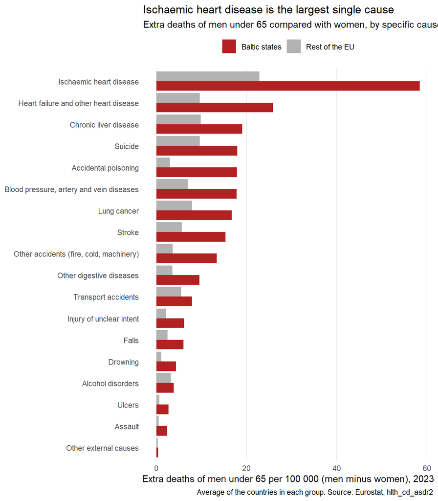

```r
# 5.3.2 Graph 6: the extra deaths of men by specific cause, Baltic states and rest of the EU, 2023
detail_gap <- deaths_by_cause |>
  filter(year == 2023) |>                                              # the latest year
  mutate(cause = case_when(                                            # the 18 causes, with readable names
    cause_code == "I20-I25"      ~ "Ischaemic heart disease",
    cause_code == "I30-I51"      ~ "Heart failure and other heart disease",
    cause_code == "I60-I69"      ~ "Stroke",
    cause_code == "I_OTH"        ~ "Blood pressure, artery and vein diseases",
    cause_code == "V_Y85"        ~ "Transport accidents",
    cause_code == "W00-W19"      ~ "Falls",
    cause_code == "W65-W74"      ~ "Drowning",
    cause_code == "X40-X49"      ~ "Accidental poisoning",
    cause_code == "ACC_OTH"      ~ "Other accidents (fire, cold, machinery)",
    cause_code == "X60-X84_Y870" ~ "Suicide",
    cause_code == "X85-Y09_Y871" ~ "Assault",
    cause_code == "Y10-Y34_Y872" ~ "Injury of unclear intent",
    cause_code == "V01-Y89_OTH"  ~ "Other external causes",
    cause_code == "K25-K28"      ~ "Ulcers",
    cause_code == "K70_K73_K74"  ~ "Chronic liver disease",
    cause_code == "K_OTH"        ~ "Other digestive diseases",
    cause_code == "F10"          ~ "Alcohol disorders",
    cause_code == "C33_C34"      ~ "Lung cancer"
    # every other code gets NA and is removed in the next step
  )) |>
  filter(!is.na(cause)) |>                                             # keep only the 18 causes
  group_by(baltic, cause) |>                                           # one group per cause and country group
  summarise(death_gap = mean(death_gap), .groups = "drop") |>          # simple average of the countries
  mutate(group = if_else(baltic, "Baltic states", "Rest of the EU"))   # readable group names

detail_gap |>
  mutate(cause = fct_reorder(cause, death_gap, .fun = max)) |>         # sort the causes by their larger bar
  ggplot(aes(x = cause, y = death_gap, fill = group)) +
  geom_col(position = "dodge") +                                       # the two groups side by side
  coord_flip() +                                                       # bars sideways, names readable
  scale_fill_manual(values = c("Baltic states" = "firebrick",          # Baltic states in red
                               "Rest of the EU" = "gray70")) +         # the rest in gray
  labs(title = "Ischaemic heart disease is the largest single cause",   # the finding, short enough to fit
       subtitle = "Extra deaths of men under 65 compared with women, by specific cause, 2023",   # what is shown
       x = NULL,
       y = "Extra deaths of men under 65 per 100 000 (men minus women), 2023",
       fill = NULL,
       caption = "Average of the countries in each group. Source: Eurostat, hlth_cd_asdr2") +
  theme_minimal() +                                                    # white background, light grid
  theme(legend.position = "top",
        panel.grid.minor = element_blank(),
        panel.grid.major.y = element_blank())                          # the bars need no horizontal grid
```

**Finding:** ischaemic heart disease is the largest single cause of the extra deaths of Baltic men under 65: 58 more deaths per 100 000 than women, against 23 in the rest of the EU, about 2.6 times as many. Heart failure and other heart disease (26 against 10) and stroke (15 against 6) add to the circulatory excess. Among the other causes, accidental poisoning stands out most: 18 extra deaths per 100 000 against 3, six times the EU level. This group includes alcohol poisoning. Chronic liver disease (19 against 10) also points to alcohol, while deaths coded as alcohol disorders (`F10`) are barely higher (4 against 3), so alcohol seems to show up through poisoning, the liver and the heart rather than under its own name. Violent and risky deaths are also much more frequent: drowning about 4 times, assault almost 5 times and suicide almost twice the EU level. Lung cancer is about twice the EU level (17 against 8).

**What this means:** the extra deaths of Baltic men under 65 come mainly from heart disease, followed by external causes such as poisoning, suicide and drowning, and liver disease. Several of these point to alcohol. But this compares only two groups, and three countries could be an exception. The next question is whether the same causes go with the gap across all 27 countries.

## 5.4 Which factors go with the gap?

Graphs 5 and 6 compared two groups, the Baltic states and the rest. With only three countries in one group, a difference could be a coincidence of those three. The hypotheses are about a pattern across countries: where a factor is larger, the gap is larger. This is tested with all 27 countries, one dot per country, in 2023, the latest year with deaths data.

Five factors are compared, one for each hypothesis: men’s extra deaths (men minus women, per 100 000, under 65) from circulatory diseases, from external causes and from alcohol-related causes, and GDP per capita and the education gap from `gap_panel`. The alcohol-related causes are chronic liver disease and accidental poisoning, the two causes in Graph 6 that point to alcohol.

### 5.4.1 One table with the five factors

The death factors come from `deaths_by_cause` and are put side by side with `pivot_wider()`, then joined onto `gap_panel` for 2023. `pivot_longer()` (class 05) then stacks the five factors into one column, so that the five correlations can be computed together in 5.4.7. It is the opposite of `pivot_wider()`. Each graph in 5.4.2 to 5.4.6 uses the wide table, `factors_2023`, and looks at one factor.

```r
# 5.4.1 The five candidate factors and the gap, one row per country, 2023
death_factors_2023 <- deaths_by_cause |>
  filter(year == 2023,
         cause_code %in% c("I", "V01-Y89", "K70_K73_K74", "X40-X49")) |>   # the causes behind three factors
  mutate(factor = case_when(
    cause_code == "I"       ~ "death_circulatory",                         # hypothesis 1
    cause_code == "V01-Y89" ~ "death_external",                            # hypothesis 2
    .default                = "death_alcohol"                              # hypothesis 3: liver + poisoning
  )) |>
  group_by(country_code, factor) |>
  summarise(value = sum(death_gap), .groups = "drop") |>                  # liver and poisoning are added up
  pivot_wider(names_from = factor, values_from = value)                    # one column per factor

factors_2023 <- gap_panel |>
  filter(year == 2023) |>                                                  # the same year as the deaths
  select(country_code, country, baltic, le_gap,
         gdp_pps_index, tertiary_gap) |>                                   # the gap and the two other factors
  left_join(death_factors_2023, by = join_by(country_code))                # add the three death factors

factors_long <- factors_2023 |>
  pivot_longer(cols = c(death_circulatory, death_external, death_alcohol,
                        gdp_pps_index, tertiary_gap),                      # the five factors
               names_to  = "factor",                                       # their names go into one column
               values_to = "value") |>                                     # their numbers into another
  mutate(factor = case_when(                                               # readable panel titles
    factor == "death_circulatory" ~ "1 Circulatory deaths, men's excess",
    factor == "death_external"    ~ "2 External deaths, men's excess",
    factor == "death_alcohol"     ~ "3 Alcohol-related deaths, men's excess",
    factor == "gdp_pps_index"     ~ "4 GDP per capita (EU27 = 100)",
    factor == "tertiary_gap"      ~ "5 Education gap (women minus men, % points)"
  ))

dim(factors_2023)   # expected: 27 rows, 9 columns
```

```
[1] 27  9
```

```r
dim(factors_long)   # expected: 135 rows (27 countries x 5 factors), 6 columns
```

```
[1] 135   6
```

**What it shows:** `factors_2023` has 27 rows, one per country, and 9 columns: the code, name and Baltic mark, the gap, and the five factors. `factors_long` has the same information stacked: 135 rows, five per country, one for each factor.